# Den islamiske psyke (Bog 2)

Naim al-Gharib

Version: 3.2.1  
Oprettet: 22-02-2004  
Sidst opdateret: 20-11-2020

**Copyright**

Copyright har ingen eksistensberettigelse i Islam, og du kan frit citere eller kopiere dele af bogen eller hele bogen. Dog har du ingen ret til at begå plagiat, og du må således ikke foretage uddrag fra bogen eller hele bogen for derefter at udgive dette i eget navn. I overensstemmelse med god islamisk etikette skal uddrag eller citater fra bogen angives med kildehenvisning.

**Versionsnummeret**

Jeg opdaterer denne bog fra tid til anden, og jeg har derfor valgt at benytte mig af [Semantic Versioning](https://semver.org/) til at fastlægge bogens versionsnummer.

Når det første tal i versionsnummeret har ændret sig, som f.eks. fra version 1.x.x til 2.x.x, så betyder dette at alle tidligere udgaver er forkastet, og at den nye udgave inderholder markante eller vigtige ændringer.

Når versionsnummerets andet tal bliver ændret, som f.eks. fra version 2.2.x til 2.3.x, så betyder dette at jeg enten har tilføjet noget der stemmer overens med det der allerede står i bogen, det kan f.eks. være et nyt eksempel, eller en ny hadith, eller noget andet. Men det kan også betyde at jeg har slettet noget som jeg ikke længere mener bidrager til bogens formål.

Når versionsnummerets sidste tal bliver ændret, som f.eks. fra version 2.3.0 til 2.3.1, så betyder dette blot at der er foretaget nogle små ubetydelige ændringer som f.eks. rettelse af skrivefejl eller tilsvarende.

**Evt. brugte forkortelser**

- (AH): Anno Hegirae, er latin og det bruges til tidsregning og det betyder “I emigrationens år”. AH skrives efter årstallet i den islamiske kalender.
- (swt): سبحانه وتعالى (Subhannahu wa ta ala). Det betyder “priset og ophøjet er Han” og det bruges til at prise Allah, når Han nævnes.
- (saaws): صلى الله عليه وسلم (Salla Allahu alay-hi wa-sallam). Det betyder “må Allah velsigne ham og skænke ham fred”. Det bruges når man nævner Profeten Muhammad eller andre profeter.
- (raa): رضي الله عنه (Radhi Allahu anhu). Det betyder “må Allah være tilfreds med ham”. Det bruges når man nævner en af Profetens Sahabah.
- (rha): رحمه الله (Rahimahullah). Det betyder “må Allah være barmhjertig imod ham”. Det bruges når man nævner en muslim, der er gået bort.
- (Bukhari): Henviser til hadithsamlingen “Sahih al-Bukhari”, samlet af Imam Bukhari (d. 256 AH., 870 E.V.T.)
- (Muslim): Henviser til hadithsamlingen “Sahih Muslim”, samlet af Muslim bin al-Hajjaj (d. 261 AH., 875 E.V.T.)
- (Abu Dawud): Henviser til hadithsamlingen “Sunan Abi Dawood”, samlet af Abu Dawood (d. 275 AH., 888 E.V.T.)
- (Tirmidhi): Henviser til hadithsamlingen “Jami al-Tirmidhi”, samlet af Ibn Isa as-Sulami ad-Darir al-Tirmidhi (d. 279 AH., 892 E.V.T.)
- (Nasai): Henviser til hadithsamlingen “Sunan al-Sughra”, samlet af Ahmad bin Shuaib bin Ali bin Sinan Abu Abdur-Rahman al-Nasai (d. 303 AH., 915 E.V.T.)
- (Ibn Majah): Henviser til hadithsamlingen “Sunan bin Majah”, samlet af Ibn Majah (d. 273 AH., 887 E.V.T.)
- (Imam Malik): Henviser til hadithsamlingen “Muwatta Imam Malik”, samlet af Imam Malik (d. 179 AH., 795 E.V.T.)

**Teksformattering**

Tekst der står med **fed**, er Koranvers. Tekst der står med *kursiv*, er hadith.

**Sol- og månebogstaver**

På arabisk opdeles konsonanter i to grupper. Den ene gruppe kaldes “solbogstaver” og den anden gruppe kaldes “månebogstaver”.

Forskellen på de to grupper ligger i hvorvidt de gør bogstavet “l” stumt, når “l” kommer før et bogstav i bestemt artikel. Hvis bogstavet er et solbogstav, så bliver “l” stumt. På arabisk hedder “solen” “al-shams”, og det skrives med bogstavet “l”, men fordi bogstavet “shiin”, der her skrives som “s”, er et solbogstav, så udtales “l” ikke, men i stedet siger man “as-shams”. I denne bog har jeg valgt at hjælpe læseren til den korrekte udtale af ordene hvorfor jeg har skrevet bogstaverne som de udtales.

F.eks. begrebet “Al-Taqwa” har jeg derfor skrevet som “At-Taqwa” selvom der burde stå “Al-Taqwa”, og begrebet “Al-Taubah” har jeg skrevet som “At-Taubah” selvom der burde stå “Al-Taubah”.

# Forord

**(I Allahs navn, den Nådige, den Barmhjertige) بسم الله الرحمن الرحيم**

Al pris og taknemmelighed tilkommer alene Allah, vi priser Ham, og søger Hans hjælp og tilgivelse. Vi søger tilflugt hos Allah imod vor egen ondskab og imod det onde fra vore handlinger. Den som Allah retleder, kan ingen vildlede, og den som Allah efterlader i vildfarelse, kan ingen retlede. Jeg bærer vidnesbyrd om at ingen har ret til tilbedelse eller underkastelse foruden Allah alene, og jeg bærer vidnesbyrd om at Muhammad (saaws) er Hans tjener og sidste sendebud.

“Den islamiske Psyke” var oprindeligt en samling håndskrevne notater som jeg havde skrevet over en periode på godt 8 år. Efterhånden som tiden gik blev notaterne udvidet med mine egne kommentarer, og jeg har nu besluttet at udgive dem som en bog. Denne bog er blevet til den ene af bøgerne i en serie af tre bøger idet jeg håber, at Allah (swt) vil tillade at andre kan gavne fra dem.

De to andre bøger er “Den islamiske mentalitet” og “Den islamiske væremåde”, hvoraf den sidste stadig er under udvikling.

Da jeg oprindeligt skrev notaterne til denne bog gjorde jeg ikke meget ud af at nedskrive referencer til de ahadith som jeg brugte, og der forekommer derfor ahadith og beretninger hvor referencen mangler, men samtlige ahadith og beretninger der er brugt i bogen, er fra de anerkendte værker. På de ahadith og beretninger hvor jeg har nedskrevet referencen, er nogle referencer fra de arabiske kilder, mens andre kan være fra engelske oversættelser. Dette beklager jeg, men de forskellige ahadith er forholdsvis lette at finde med de moderne søgemaskiner til samlingerne.

De ahadith jeg har brugt i bogen, har jeg ikke blot selv siddet og plukket ud, men jeg har derimod konsulteret fuqahas (de retslærdes) bøger, da kun fuqaha er kompetente til at bruge hadithsamlingerne korrekt. Når jeg således har brugt en hadith skyldes det at den er at finde i de lærdes bøger, og at de bruger den omtalte hadith.

Jeg har med vilje undladt fodnoter. Jeg synes at fodnoter er forstyrrende, når man læser, da man er nødt til at bryde læsningen og se ned. Jeg finder parenteser mindre forstyrrende, og har derfor valgt at bruge dem.

Enhver form for oversættelse af Koranvers kan kun være meningsmæssig og tilnærmelsesvis. Koranen kan ikke oversættes til et andet sprog grundet dens mirakuløse natur.

Jeg har forsøgt at undgå overlapning i de forskellige afsnit, men det har været hensigtsmæssigt nogle steder at fremhæve det samme Koranvers eller den samme hadith.

Hvis der er fejl i bogen så skyldes det udelukkende mine begrænsede egenskaber, og hvis der er sandhed og retledning i bogen, så skyldes det udelukkende Allahs (swt) Velsignelse og Nåde.

Jeg vil meget gerne modtage forslag til forbedringer, rettelser og andet der kan forbedre indholdet i bogen - stort såvel som småt.

## Tafsir og fortolkning

Enkelte steder i bogen har jeg citeret nyere fortolkninger af Koranen, som f.eks. Shaikh Sayyid Abul Ala Maududis “Tafhim al-Qur’an” (Koranens mening), eller Sayyid Qutbs “Fi Dhilal Al Qur’an” (I Koranens skygge). Jeg har også citeret bl.a. Shaikh Taqiudin an-Nabhani. Dette betyder **ikke** at jeg er en tilhænger af disse personer.

Tværtimod mener jeg at at disse personer har en ret skæv forståelse af islam der i den grad blev påvirket af den daværende tids politiske atmosfære, hvor bl.a. kommunismen prægede disse mennesker og deres forståelse af islam ret markant. Resultatet er at disse personer ikke alene giver den politiske del af islam en meget større rolle end den i virkeligheden har, men samtidig fortolker de også mange koranvers forkert og ud af den rette kontekst.

Politik spiller en rolle i islam, og islam er har en politisk dimension, og der findes koranvers relateret til politik, stat, og samfund, men dette er bestemt ikke islams fokus. Islams fokus er derimod den direkte personlige tilbedelse og helliggørelse af Skaberen af universet. En tilbedelse og helliggørelse der udspringer fra en utrolig kærlighed til Ham, og søgen efter nærhed til Ham. Til den grad at hvis man forstår islam korrekt, på den måde som både Profeten Muhammad (saaws) og hans elskede sahaba (raa) forstod islam og praktiserede islam, så er det nærmest som om at man konstant og vedholdent er så optaget af det personlige forhold til Gud at man fuldstændig bliver opslugt i dette, og helt glemmer resten af verdenen omkring en. Dette er essensen af islam og tilbedelse af Skaberen, ikke de politiske aspekter som islam nødvendigvis måtte tage sig af da er samfund ikke kan eksisterer uden en politisk dimension.

Når jeg alligevel har valgt at citere disse personer i nogle tilfælde, så skyldes dette at ikke alt hvad disse personer har skrevet eller sagt er forkert, og ikke alt de har bidraget med er uden en positiv værdi. En sådan tilgang ville være helt ekstrem og helt forkert. Tværtimod findes der mange brugbare ting i deres bøger som stemmer mere overens med den morderne verdens forståelse af livet og universet end det vi finder i mange af de gamle klassiske bøger, der desværre tilgengæld ofte er fyldt med eventyr og gamle vrøvlehistorier.

Islam handler om at have en balanceret tilgang til livet uden ekstremer.

## Forskellen på den sproglige betydning og den åbenbaringsmæssige betydning

Den sproglige betydning af et ord er den betydning som ordet havde i det arabiske sprog før islams tid. Dette er den grundlæggende betydning af ordet. Den åbenbaringsmæssige betydning, eller guddommelige betydning, også nogle gange kaldet den shariamæssige betydning, er den betydning som islam efterfølgende har tildelt ordet, og som efterfølgende blev den anerkendte betydning blandt araberne.

F.eks. har begrebet “salah” den sproglige betydning “at spørge”, “at bede” eller “at tigge om noget”, men efter islams tid er begrebet blevet udvidet til specifikt at betyde den islamiske obligatoriske bøn - med alle dens tilhørende specifikke bevægelser og specifikke udtalelser.

Den åbenbaringsmæssige betydning blev den dominerende betydning i de fleste begreber, mens den sproglige betydning blev forladt eller tilsidesat. Dette gælder dog ikke alle tekster. Når en tekst skal forstås korrekt, er det derfor vigtigt at undersøger i hvilken sammenhæng et begreb er blevet brugt af forfatteren. Her er det ofte konteksten der afslører den tilsigtede brug af begrebet. Nogle gange bliver et ord brugt i ordets oprindelige betydning, mens det andre gange bruges i den åbenbaringsmæssige betydning.

## Begrebet الإيمان (al-iman)

Begrebet الإيمان “al-iman” bliver oversat til “tro” i samtlige Koranoversættelser, men det er direkte forkert. Begrebet “iman” er i henhold til islam defineret som værende “den absolutte overbevisning der stemmer overens med realiteten, baseret på bevis”.

Det er derfor direkte forkert at oversætte “iman” til “tro” idet “tro” indbefatter tvivl og formodning. I denne tekst har jeg derfor valgt at bruge ordet “overbevist”, når jeg har oversat ordet “iman”, idet jeg mener at det bedre dækker over betydningen af “iman” end ordet “tro” gør.

Når “tro” forbindes til den absolutte overbevisning om Guds eksistens og Hans (swt) åbenbaring af Koranen til Profeten Muhammad (saaws), så har dette relation til hvor meget man stoler på Gud, hvor meget man hviler i Guds løfter osv., men det har ikke relation til overbevisningen om hverken Hans eksistens, Koranen eller Profeten Muhammad (saaws) da denne nødvendigvis skal være absolut, og ikke kan indbefatte tvivlsomme elementer.

# Indledning

Den islamiske aqidah (livssyn) er det vi som muslimer skal basere vores måde at tænke på (mentaliteten) og vores måde at føle på (psyken), mens Allahs lovgivning (sharia) er det vi skal basere vores handlinger på. Og det er utrolig vigtig at vi adskiller imellem disse på korrekt vis.

Vi må således ikke basere vores tænkning eller følelser på Koranvers der er relaterede til handlinger eller omvendt - sådan som det desvære ofte er sket op igennem historien.

Når Allah (swt) påbyder at vi skal have at-tawakkul (stole) på Ham, så må dette ikke medføre manglende handlinger. Ejheller må søgen efter rizq (levebrød) medføre en overdreven søgning, hvor vi arbejder overdrevet meget, og dermed forsømmer andre vigtige forpligtelser som f.eks. as-salah (den islamiske obligatoriske bøn) eller familien o.a.

Det berettes at Umar bin Al-Khattab (raa) en dag gik forbi en gruppe mennesker der sad og tiggede, og da han spurgte hvem de var, fik han følgende svar: “Det er dem der stoler på Allah!” Umar sagde: “Nej! Det er dem der spiser andre menneskers ejendom! Skal jeg ikke beskrive dem der virkeligt er al-mutawwakilun (stoler på Allah)? Det er den person der sår et frø i jorden, og derefter stoler på sin Herre Den Almægtige.”

Den islamiske aqidah (livssyn) består af en række af entydige Koranvers, og disse skal udgøre fundamentet for vor overbevisning og følelser. Vi kan bedst tænke os den islamiske aqidah som gruppe af grundlæggende tanker, tanker der kommer før alle andre tanker, og hvorpå alle andre tanker, følelser og ideer skal bygges og vurderes. Som eksempel kan nævnes tanken om Allahs eksistens. Denne tanke er en grundlæggende tanke der har betydning for alle andre tanker i vores liv. Vi baserer enhver tanke, enhver følelse og enhver handling i vores liv på denne grundlæggende tanke. Det er det der menes med at tanken er grundlæggende.

Her skal man ikke blive forvirret og begynde at diskutere om man kan kalde Koranvers for tanker. Det er ikke det der menes med ovenstående eksempel. Fakta er at Koranen indeholder nogle fundamentale koncepter, koncepter som vi kan kalde for “tanker”, tanker som vi kan forstå og tænke.

Det islamiske livssyn må kun sammensættes af absolutte og entydige Koranvers, og det må ikke sammensættes af flertydige Koranvers eller tvivlsomme ahadith.

De flertydige Koranvers og de tvivlsomme ahadith kan benyttes som forstærkende eller forklarende elementer, men de kan aldrig udgøre beviser for den islamiske aqidah.

En sand islamisk personlighed er bygget på det islamiske livssyn, og personens tanker, følelser og handlinger stemmer grundlæggende overens med islam. Derudover er personen samtidig tæt på Allah (swt), og forsøger at leve hver eneste dag i dyb kontakt til Allah (swt). Denne kontakt kommer til syne i form af en sanselig følelse af dyb nærhed til Allah (swt), og nogle islamiske personligheder modtager, som resultat af deres nærhed til Allah (swt), forskellige velsignelser som f.eks. al-farisah (ophøjet indsigt) og as-Sakinah (velsignet fred).

Allah (swt) siger: “**Og hav as-sabr (islamisk tålmodighed), og din as-sabr kommer udelukkende fra Allah.**” (16:127).

Ibn al-Qayyim al-Jawziyyah (rha) skriver følgende til ovenstående koranververs:

> Dette vers fortæller os at as-sabr ikke kan opnås uden hjælp fra Allah. Dette betyder at ud over Allahs hjælp så har vi også brugfor Hans følgeskab. Abu Hurairah (raa) beretter at Profeten (saaws) sagde: “*Allah sagde: Den som viser fjendskab imod en hengiven tilbeder af Mig, vil Jeg være i krig med. Min tjener kommer ikke nærmere Mig med noget som Jeg elsker mere end de forpligtelser, som Jeg har lagt på ham. Og Min tjener fortsætter med at nærme sig Mig med frivillige gerninger indtil Jeg elsker Ham. Når Jeg elsker ham, er Jeg hans hørelse med hvilket han hører, hans syn med hvilket han ser, hans hænder med hvilke han griber, og hans fødder med hvilke han går. Hvis han skulle bede Mig om noget, ville Jeg sandelig give det til ham, og skulle han bede om tilflugt, ville jeg skænke ham det. Jeg tøver ikke med noget så meget som med at tage Min trofaste tjeners sjæl, han hader døden, og Jeg hader at gøre ham ondt, men han skal dø.*” (At-Tabarani. Bukhari har den også dog uden “men han skal dø”).

> Allah hjælper både den der har iman, og den der er en forbryder, begge modtager de nåde og forsyning (som mad og drikke). Men denne hadith beskriver noget ud over dette, nemlig Allahs følgeskab, som den der har iman modtager når han udfører ekstra frivillige handlinger af tilbedelse indtil Allah elsker ham. Når han opnår den tilstand, og Allah er hans hørelse med hvilken han hører, og hans syn med hvilket han ser, så bevæger han sig ikke, og udfører ingen handling undtagen Allah er med ham. Den der opnår denne status kan have as-sabr for Allahs skyld, og han kan udholde store besværligheder for at gøre Allah tilfreds. Den person der ikke når dette niveau, kan ikke have det samme niveau i as-sabr. Hans niveau i as-sabr afhænger af hvor meget han har Allahs følgeskab. Den der nyder Allahs følgeskab, vil opnå niveauer i as-sabr der er umulige for andre at nå. Og dem der har as-sabr, er vinderne i denne verden og i den næste verden fordi Allah er med dem: ‘**For Allah er med dem der har as-sabr.**’ (2:153). Det er et specielt følgeskab der betyder, at Han beskytter og hjælper dem.

# لا إله إلا الله - La ilaha ill Allah (Ingen anden Gud end Allah)

Når vi bekender os til islam, sker det igennem at vi udtaler den islamiske trosbekendelse. Den første del af trosbekendelsen indeholder en bevidnelse på Guds eksistens, og på at Han alene er den der fortjener tilbedelse, tjeneste og underkastelse. Den anden del af trosbekendelse indeholder bevidnelse på at Profeten Muhammad (saaws) er Hans sidste Profet og Sendebud.

Allah (swt) siger: “**Så vid, at لَا إِلَـٰهَ إِلَّا اللَّـهُ (la ilaha ill Allah)**” (47:19).

Ordet إِلَـٰهَ (ilaha) betyder “tilbedelse”, “at beskytte”, “at befri”, “den man er en slave for”, “gud” og “den man tjener”. Ordet لَا (la) betyder i denne sætning “ikke”. Og ordet إِلَّا (ill) betyder i denne sætning “end”. Og ordet اللَّـهُ (Allah) er Guds egenavn.

Man kan derfor oversætte trosbekendelsens første led til at betyde: “Der eksisterer ikke nogen anden gud end Allah. Du må ikke tilbede andre end Allah. Du må ikke være en slave for nogen anden end Allah, og du må ikke tjene nogen anden end Allah.”

Som muslim er det ikke nok at man bevidner, at der ikke eksisterer nogen anden gud end Allah, man skal også bevidne at man kun må tjene og tilbede Allah (swt).

At tilbede Allah har en meget større betydning i det arabiske sprog end det kan forklares med det danske ord “tilbedelse”. Tilbedelse på dansk indbefatter bøn og tjeneste i en religiøs henseende, men på arabisk dækker det over meget mere end det.

Allah (swt) siger i surah at-Taubah vers 31: “**De tog deres præster og munke som herrer foruden Allah, og også Messias Marias søn, til trods for at de udelukkende blev befalet at tilbede en Herre. Der er ingen anden herre foruden Ham.**” (9:31).

Ibn Kathir skriver følgende i sin tafsir:

> Hudhayfah bin Al-Yaman, Abdullah bin Abbas og flere andre har forklaret denne del af verset, “**De tog deres præster og munke som herrer foruden Allah**”, ved at sige at de kristne og jøderne adlød deres præster og munke når de tillod dem noget (der var forbudt), eller forbød dem noget (der var tilladt), og det er derfor Allah siger, “**til trods for at de udelukkende blev befalet at tilbede en Herre**”. Så det Allah gør forbudt er forbudt, og det Han gør tilladt er tilladt, og det er Ham der bestemmer hvad der skal følges.

Lovgivning er altså en ret der er forbeholdt Den Almægtige Allah, Skaberen af univserset, og intet andet menneske har retten til at formulerer en lov der modstrider Skaberens lov.

Og Allah (swt) siger: “**Vil I acceptere en del af skriften og fornægte resten? Der er da ikke nogen anden belønning for den der handler sådan end skændsel i dette liv. Og på opstandelsens dag skal de overgives til den strengeste straf. Og Allah er ikke uvidende om hvad I gør.**” (2:85).

Dette betyder at det at acceptere en del af Allahs love og regler, mens man fornægter en anden del, er haram (forbudt).

Et samfund kan ikke fungere uden love og regler, men hvis man ikke anerkender at lovgivning er forbeholdt Skaberen af universet, så er man nødt til at erstatte Skaberens love med menneskeskabte love, og dette udgør således en form for afgudsdyrkelse.

Allah (swt) siger: “**Den der søger en anden دِينًا (dinan) {levemåde, livssystem, religion} end islam skal vide at det aldrig vil blive accepteret af ham, og han vil på Dommedagen være en af taberne!**” (3:85).

## Menneskeskabt lovgivning

Den der kalder til en anden lovgivning end Allahs (swt), anerkender en anden suverænitet end Hans, og konsekvensen er i værste fald at personen frafalder islam.

Allah (swt) siger: “**De der ikke dømmer med det, som Allah har nedsendt, er visselig kuffar (benægtere).**” (5:44).

Og Allah (swt) siger: “**De der ikke dømmer med den lov, som Allah har nedsendt, er visselig dhalimun (uretskafne).**” (5:45).

Og Allah (swt) siger: “**De der ikke dømmer med den lov, som Allah har nedsendt, er fasiqun (oprørske).**” (5:46-47).

Ibn Kathir (rha) skriver bl.a. følgende i sin tafsir angående disse vers:

> Al-Bara bin Azib, Hudhayfah bin Al-Yaman, Ibn Abbas, Abu Mijlaz, Abu Raja Al-Utaridi, Ikrimah, Ubaydullah bin Abdullah, Al-Hasan Al-Basri og andre har sagt at disse vers er relateret til Bogens Folk (jøder og kristne). Al-Hasan Al-Basri tilføjede at dette også gælder os (muslimer). Abdur-Razzaq sagde at Ath-Thawri sagde at Mansur sagde at Ibrahim sagde at disse vers blev åbenbaret om Israels Børn, men at Allah også gør dem gældende for denne nation (muslimer). Ali bin Abi Talhah sagde også at Ibn Abbas sagde at den der benægter det som Allah har åbenbaret vil have begået kufr, og den der accepterer det som Allah har åbenbaret, men som ikke handler i overensstemmelse med det er en dhalim (uretskaffen) og en fasiq (oprører) og en synder. Ibn Tawus sagde, “Det er ikke ligesom dem der benægter Allah, Hans engle, Hans bøger og Hans sendebude.” Ath-Thawri sagde at Ibn Jurayj sagde at Ata sagde, “Der findes en kufr der er mindre end kufr, og der findes en dhulm, der er mindre end dhulm, og en fisq der er mindre end fisq.” Og Waki sagde at Said Al-Makki sagde at Tawus sagde at, “Dette er ikke den kufr der aflyser ens religion.”

Allah (swt) siger: “**Men nej, ved din Herre, de kan ikke have iman førend de gør dig (Muhammad) til dommer i alt hvad de end strides om, og derefter i deres indre ikke finder modvilje imod din dom, men accepterer den og underkaster sig fuldstændigt.**” (4:65).

Og Allah (swt) siger: “**I dag har Jeg fuldkommengjort دِينَكُمْ (dinakum) {jeres levemåde, livssystem, religion} for jer, og har fuldkommengjort Min gunst mod jer, og har valgt islam som دِينًا (dinan) {levemåde, livssystem, religion}.**” (5:3).

Man kunne spørge: “Hvordan kan en 1400 gammel lov gøre sig gældende i moderne tid?”

Svaret er at den islamiske lov, også kaldet sharia, er henvendt til mennesket og til organisering af menneskets behov. Mennesket og menneskets behov har ikke ændret sig siden tidernes morgen. Det der har ændret sig er midler. Midler som transportmidler, kommunikationsmidler, og andre midler. Men de behov vi som mennesker har brug for at få opfyldt er de samme behov - de samme behov der eksisterede for 1400 år siden, ja, selv for 100.000 år siden, og de vil være identiske med de behov mennesket vil have helt frem til jordens undergang.

## Shirk (afgudsdyrkelse)

Shirk er at give Allah (swt) partnere, og en person kan give Allah (swt) partnere på mange forskellige måder.

Ulama (de retslærde) deler shirk op i tre slags.

- Ash-Shirk ul-Akbar (Den store shirk).
- Ash-Shirk ul-Asghar (Den lille shirk).
- Ash-Shirk ul-Khafie (Den skjulte shirk).

Forskellen imellem den store shirk og den lille shirk er at den store shirk bringer en person ud af islam, det gør den lille shirk ikke. Den store shirk aflyser også gode gerninger, og den forårsager at alle gode gerninger bliver slettet.

Allah (swt) siger: “**Hvis du giver Allah partnere i tilbedelse af Ham, sandelig så vil alle dine gerninger være spildt, og du vil uden tvivl høre til blandt taberne.**” (39:65).

Det berettes fra Jabir (raa) at Profeten (saaws) sagde: “*Den der møder Allah uden at have lavet shirk imod Ham, kommer ind i Paradis, men den der møder Ham, og som har lavet shirk, uanset hvilken form, vil komme ind i Helvede.*” (Muslim).

### At følge sine egne lyster er begyndelsen til shirk (afgudsdyrkelse)

Allah (swt) siger: “**Har du ikke set den som gør sine egne lyster til sin gud? Allah har genkendt ham, og har ladet ham fare vild, og har forseglet hans hørelse og hans hjerte, og har placeret et slør over hans syn. Hvem skal da retlede ham efter Allah? Vil I da ikke modtage advarsel?**” (45:23).

Og Allah (swt) siger: “**Har du nogensinde overvejet den persons situation der gør sine egne lyster til sin gud? Kan du tage ansvar for at retlede en sådan rigtigt? Mener du at de fleste af dem hører eller forstår? De er kun som kvæg! Nej, de er endnu værre end kvæg!**” (25:43-44).

Det berettes fra Abu Hurairah (raa) at Profeten (saaws) sagde: “*Af alle de falske guder der tilbedes og tjenes i stedet for Allah, da er den værste i Allahs øjne en persons egne lyster.*” (At-Tabarani).

Nu må dette ikke misforståes sådan at man tror, at hvis man i en given situation har været syndig, at man så også har begået afgudsdyrkelse fordi man har fulgt sine lyster fremfor at adlyde Allah (swt). Det er ikke det der er tale om her. Det der derimod er tale om, når disse vers læses i den rette kontekst, er at de mennesker der blev kaldt til islam på Profetens (saaws) tid, og som var afgudsdyrkere, var afgudsdyrkere på grund af deres lyster, og det var deres lyster der fik dem til at benægte islam og forkaste Allah (swt). Som resultat heraf gjorde Han det derefter umuligt for dem at forstå retledning.

Afgudsdyrkelse, uanset formen, begynder altid med følelser, og aldrig med tænkning og bedømmelse.

### Ash-Shirk ul-Akbar (Den store shirk)

Denne type af shirk kan være udvendig som f.eks. når mennesker tilbeder statuer eller gravpladser eller døde mennesker. Eller den kan være indvendig som f.eks. når mennesker sætter sin lid til fantasiskabte “guder”, når mennesket udviser hykleri overfor Allah (swt), eller når mennesker mener at Skaberens lov er ubrugelig.

Den kan også være baseret på tro. Hvis en person f.eks. tror at nogen anden end Allah (swt) kan skænke liv eller give død, eller at nogen anden har magt over universet.

Den kan også være baseret på kærlighed. F.eks. hvis en person elsker noget eller nogen anden sådan som kun Allah (swt) bør elskes.

Nogle eksempler på stor ash-shirk ul-akbar (den store shirk):

- Shirk ud-Dua (bønnens shirk). Hvis man beder til nogen anden end Allah (swt). Det kan være en statue, en død person ved en grav eller andre.
- Shirk ut-Taa’ah (adlydelsens shirk). Hvis en person underkaster sig en anden lovgivning end Allahs (swt) med den overbevisning at Allahs lov ikke duer, er forældet, ikke er egnet, osv.
- Shirk ul-Mahabbad (kærlighedens shirk). Ved denne type shirk elsker en person dem som Allah (swt) hader, eller hader dem som Allah (swt) elsker.

### Ash-Shirk ul-Asghar (Den lille shirk)

Det berettes at Profeten (saaws) sagde: “*Af de ting som jeg frygter for min Ummah (nation), da er den ting som jeg frygter mest en lille shirk.*” Han blev spurgt hvad en lille shirk er, og han (saaws) svarede: “*Det er ar-riyaa.*” (Ahmad). Ar-Riyaa betyder “stolthed” eller at man gør noget for at folk skal tænke godt om en, se op til en eller beundre en.

Så det at udføre en handling udelukkende for at andre mennesker skal synes godt om en, og ikke fordi at Allah (swt) skal synes godt om en, det er ar-riyaa og det er shirk (afgudsdyrkelse) i en mindre form.

Hvis en person gør brug af amuletter, krystaller, hestesko, muslingeskaller, sten eller andre ting i den tro at de beskytter imod ondskab eller ulykke så er det også shirk.

Det berettes fra Imran bin Husain (raa) at Profeten (saaws) en dag så en mand med en ring af messing på sin hånd. Profeten (saaws) spurgte ham: “*Hvad er dette?*” Manden svarede: “*Det er en beskyttelse imod alderdommens svaghed.*” Profeten (saaws) sagde: “*Tag den af! Den kan kun forøge din svaghed. Skulle døden ramme dig imens du har den på, ville du aldrig få succes.*” (Ahmad). Dvs. fordi manden bar på denne ring fordi han mente, at den kunne beskytte ham imod svaghed, så blev dette til en handling af shirk, og hvis han var død i den tilstand, så ville han ikke få succes på Dommedagen. Det var ikke selve ringen i sig selv der var et problem.

Det berettes fra Uqbah bin Amir (raa) at Profeten (saaws) sagde: “*Den der bærer en talisman eller en amulet vil aldrig få sine ønsker opfyldt af Allah. Og den der hænger en muslingeskal op (for at bringe lykke) vil aldrig finde fred og hvile.*” Og i en anden version sagde Profeten (saaws): “*Den der bærer en talisman har begået shirk.*”

Det berettes fra Ibn Abi Hatim (rha) at Hudhaifah (raa) en gang så en mand med noget sejlgarn om hånden til beskyttelse imod feber. Hudhaifah skar sejlgarnet i stykker og reciterede Koranverset: “**De fleste af dem har iman på Allah, men de praktiserer stadig shirk!**” (12:106).

Magi, spådom og astrologi hører også under shirk. Ikke fordi disse ting har en effekt i realiteten, men netop fordi folk tror på at disse ting har en effekt.

Det berettes fra Ibn Masud (raa) at Profeten (saaws) sagde: “*Troen på spådom er shirk, troen på spådom er shirk!*” (Abu Dawud).

Og det berettes fra Imran bin Husain (raa) at Profeten (saaws) sagde: “*Den der søger spådom, eller får varsler fortolket, eller praktiserer spådomskunst, eller får sin fremtid spået, eller praktiserer troldom eller magi, eller får troldom eller magi udført for sig, og den der går til en spåkone, og tror på det, der bliver sagt, har begået kufr i det der er åbenbaret til Muhammad.*” (Al-Bazzar).

Og det berettes fra Zayd bin Khalid al-Juhani (raa) at han sagde: “Allahs Sendebud ledte morgenbønnen for os ved al-Hudaybiyah mens det havde regnet om natten. Da Profeten (saaws) var færdig, vendte han sit ansigt imod folket og sagde: ‘*Ved I hvad jeres Herre har sagt?*’ De svarede: ‘*Allah og Hans Sendebud ved bedst!*’ Profeten sagde at Allah sagde: ‘*Denne morgen har en af Mine slaver lavet iman (overbevisning) på Mig, og en er blevet kafir (benægter). Hvad angår den der sagde: ’Vi har fået regn på grund af Allah og Hans Nåde’, så har han lavet iman på Mig, og har benægtet stjernerne. Hvad angår den der sagde: ’Vi har fået regn på grund af den og den stjerne’, så er han en kafir på Mig, og han har iman på stjernerne.*’” (Bukhari og Muslim).

Og Allah (swt) siger: “**De anerkender Allahs Barmhjertighed, og dog alligevel benægter de den, og de fleste af dem er kuffar (benægtere).**” (16:83).

Mujahid (rha) sagde i sin tafsir til verset:

> At sige: “Rigdommen er min, jeg har arvet den fra mine ældre”, er kufr!

Fordi rigdom og velstand udelukkende fastlægges og skænkes af Allah (swt).

### Ash-Shirk ul-Khafie (Den skjulte shirk)

Det berettes at Profeten (saaws) forklarede den skjulte shirk som: “*Det er når en mand rejser sig for at udføre bønnen, men så gør han sin bøn smuk fordi en anden mand ser på ham.*” (Ibn Majah og Al-Bayhaqi).

Og det berettes at Profeten (saaws) sagde: “*O mennesker! Frygt den shirk der er mere skjult end en kravlende myre.*” En person sagde: “*O Allahs Sendebud, hvordan skal vi frelse os selv fra det når det er mere skjult end en kravlende myre?*” Profeten (saaws) svarede: “*Sig: O Allah! Jeg søger tilflugt hos Dig imod at jeg bevidst giver Dig partnere, og jeg søger Din Tilgivelse for det som jeg ikke ved.*”

# الإخلاص Al-Ikhlas

## Den sproglige betydning af الإخلاص al-ikhlas

Ordet الإخلاص al-ikhlas kommer fra roden خلص khalasa der betyder “at være ren”, “oprigtig”, “tydelig”, “at rengøre en ting”, o.l.

## Den åbenbaringsmæssige betydning af الإخلاص al-ikhlas

Al-ikhlas handler islamisk set om at vi sikrer, at enhver handling vi udfører, bliver udført i oprigtighed overfor Allah (swt) i både implementering og hensigt.

Det berettes at Profeten (saaws) sagde: “*Handlinger er kun ifølge hensigten, og en mand får kun ifølge hvad hans hensigt var. Den hvis emigration var for Allah og Hans Sendebud, har i sandhed emigreret for Allah og Hans Sendebud. Og den hvis emigration var for noget verdsligt, eller for at ægte sig med en kvinde, han får det han emigrerede for.*” (Bukhari og Muslim).

Dette vil sige at vi udelukkende modtager belønning for det, vi gør for Allahs skyld i al oprigtighed overfor Ham (swt). Allah (swt) siger: “**Og de blev ikke befalet andet end at tilbede Ham, værende oprigtige overfor Ham i deres levemåde.**” (98:5).

Og Allah (swt) siger: “**Så tilbed Allah mukhlisan (i al oprigtighed).**” (39:2).

Abdul Qasim Qushayri (rha) sagde:

> Oprigtighed er at gøre Allah til det eneste formål i handlinger af lydighed hvilket betyder at man har hensigten om at komme nærmere til Allah Den Højeste og intet andet. Man kan sige at oprigtighed er at tømme sindet fra at lægge mærke til ens medmennesker.

Abu Uthman (rha) sagde:

> Oprigtighed er at glemme at lægge mærke til mennesker ved konstant at være opmærksom på deres Skaber, Allah.

Al-Makfuf (rha) sagde:

> En person med al-ikhlas er en person der skjuler sine gode gerninger såvel som sine dårlige gerninger (fra andre mennesker)

Ibn al-Qayyim (rha) sagde:

> Det mest gavnlige en person kan have er al-ikhlas i sit forhold til sin Herre i alle sine affærer. (Al-Fawaid).

Det berettes at Umar bin al-Khattab (raa) sagde:

> De bedste handlinger er at gøre det Allah har befalet, mens man holder sig langt væk fra det Allah har forbudt, og at man har en ren hensigt relateret til hvad end Allah kræver af os. (Tahdhib al-Asma li-Nawawi).

Ibn Umar (raa) hørte engang en mand stå og råbe følgende: “O Allah! Jeg har til hensigt at udføre Hajj og Umrah.” Til det sagde Ibn Umar (raa): “Er det i virkeligheden ikke folket du fortæller din hensigt? Kender Allah ikke allerede det der er i dit hjerte?”

Nogle muslimer opdeler deres gerninger i religiøse gerninger og i verdslige gerninger. Denne opdeling eksisterer ikke i islam og enhver handling en muslim udfører, mand såvel som kvinde, er enten en islamisk handling, dvs. en handling der udføres i overenstemmelse med islam, eller en uislamisk handling, dvs. en handling der udføres på trods af at den er i modstrid til islam.

Som muslimer skal vi undersøge sharia inden vi handler for at kende den relevante hukm (lov) til handlingen. Dette gælder alle handlinger uden undtagelse.

For overblikkets skyld kan vi groft sagt opdele handlinger i følgende kategorier:

1. Fard og wajib = Handlinger der er obligatoriske. Man er syndig hvis man ikke udfører dem.
2. Mandub og mustahab = Handlinger der er opfordrede. Man får belønning ved udførelse, men ingen synd ved at undlade dem.
3. Mubah = Frivillige handlinger. Disse giver hverken belønning eller synd.
4. Makruh = Handlinger der er uopfordrede. Man får belønning hvis man lader være med at udføre dem, men ingen synd hvis man gør det.
5. Haram og mahthur = Handlinger der er forbudte. Hvis man udfører dem er man syndig.

Når vi kender den rette lov til en given handling, skal vi sikre at handlingen udelukkende udføres med den rette hensigt om at adlyde Allah (swt), og ikke fordi vi ønsker at andre mennesker skal se det og rose det osv.

## Den verdslige gavn

En handling kan udføres for at opnå en verdslig gavn som f.eks. handel, landbrug, produktion, osv. Formålet med sådanne handlinger er den materielle nytte i form af økonomiske værdier. Andre former for handlinger kan f.eks. være humanitær hjælp, hjælp til dyr, osv. Eller det kunne være etiske handlinger. En handling kan også være en ren åndelig handling som f.eks. tilbedelse eller faste.

Uanset hvilken type af handling muslimen udfører må og skal handlingen stemme overens med sharia for at personen kan opnå Allahs (swt) tilfredshed.

Så hvis en person dyrker landbrug eller arbejder på et kontor, så er det den materielle gavn af handlingen der søges, altså penge, mens opnåelsen af Allahs (swt) tilfredshed sker hvis denne handling udføres i overenstemmelse med Hans (swt) påbud og forbud.

Således kan Allahs (swt) tilfredshed opnås i alle former for handlinger så længe de udføres i overensstemmelse med Hans (swt) lovgivning.

## Dårlige gerninger kan ikke gøres gode via hensigten

Nogle mennesker misforstår hadithen hvor Profeten (saaws) siger: “*Handlinger er kun ifølge hensigten, og en mand får kun ifølge hvad hans hensigt var.*” De tror at man kan handle imod Allahs (swt) lov med en hensigt om at handle godt. F.eks. hvis en person spiller lotto, hvilket er haram (forbudt), med hensigten om at hjælpe de fattige, hvis han vinder.

En god hensigt gør ikke en forbudt handling tilladt.

# التقوى - At-Taqwa (Fromheden)

## Den sproglige betydning af التقوى at-taqwa

Ordet المتقون (al-muttaqun), dvs. “dem der har at-taqwa”, står i Koranen i surah 39 Az-Zumar vers 33 i form 8, maskulin flertal, aktiv kort tillægsform, grundled, og det kommer fra roden ؤقى (waqaa).

Grundlæggende betyder ؤقى (waqaa) “at beskytte”, “at vogte”, “at være på vagt”, “beskytte imod ondt”, “tage som skjold”, m.m.

## Den åbenbaringsmæssige betydning af التقوى at-taqwa

At-taqwa kan ikke direkte oversættes, men når man skal finde det bedste ord, er ordet “fromhed” på dansk og “pious” på engelsk nogle af de bedste og mest præcise efter min mening. Fromhed er nemlig en inderlig og dydig godhed der kommer til udtryk igennem en hengiven underkastelse. Denne hengivelse finder sted dels ud af kærlighed til Allah (swt) og dels ud af frygt for Hans straf. Sagt med andre ord så er befalingen “ittaqu’llah” ikke en ordre om at “frygte Allah”, det er derimod en ordre om at adlyde Allah (swt) ud af både kærlighed og frygt. Den person der adlyder Allah (swt), uanset om drivkraften er frygt for Hans straf eller kærlighed til Ham, så hører personen til blandt al-muttaqun, dvs. dem der har at-taqwa.

Det er en pligt at have at-taqwa, hvilket vil sige at det er en pligt at være lyddig ud af fromhed. Allah (swt) siger: “**Og at-taqul-Allah, sandelig, Allahs straf er shadidu (voldsom, streng).**” (59:7).

Ibn al-Qayyim (rha) sagde:

> Hvad angår Allahs straf og dens konsekvenser så er disse blandt Allahs skabelser, og derfor bliver Allah ikke kaldt for “den der straffer” eller “den vrede”. Dette er en vigtig forskel. Det første tilskrives til Allah direkte (dvs. Barmhjertighed og Tilgivende), mens det andet (dvs. straffen) kun bruges til at beskrive Hans handlinger. Denne adskillelse kan endog findes i Koranen i en enkelt passage, for eksempel: ‘**Meddel Mine tjenere at Jeg sandelig er den Tilgivende, den Barmhjertige, og at Min straf er smertefuld.**’ (15:49-50).

Det berettes at Allahs Sendebud (saaws) sagde at, “*At-taqwa er her*”, og så pegede han på sit bryst. (Muslim).

Det berettes at Umar bin Abdul Aziz (raa) sagde:

> At-Taqwa er ikke at faste hele dagen og stå i bøn om natten. Derimod er at-taqwa at afholde sig fra det Allah har forbudt, og handle efter det, som Han har tilladt.

Umar bin al-Khattab (raa) spurgte Ubay bin Kab (raa) om betydningen af at-taqwa. Ubay svarede: “Har du nogensinde gået på en sti der havde torne på den?” Umar svarede: “Ja.” Ubay spurgte: “Hvad gjorde du da?” Umar svarede: “Jeg rullede mine ærmer op og pressede på.” Ubay sagde: “Dette er at-taqwa! At beskytte sig selv imod synd på livets farlige rejse, sådan at man succesfuldt kan fuldende rejsen uskadt af synd.”

Ibn Abbas (raa) sagde om betydningen af “al-muttaqun”, dvs. dem der har at-taqwa:

> Det er dem der har iman, og der undgår shirk, og som arbejder i lydighed til Ham.

Han sagde også at “al-muttaqun” betyder:

> Dem der frygter Allahs (swt) straf, som ville indtræde, hvis de forlod den sande retledning som de bekræfter og kender. De håber også på Allahs (swt) Barmhjertighed ved at være overbeviste om det Han åbenbarede.

Det berettes at Muaadh bin Jabal (raa) sagde:

> På Dommedagen vil der blive udråbt: ‘Hvor er de der havde at-taqwa?’ Så vil de der havde at-taqwa rejse sig op under Skyggen af Den Barmhjertige. Det er dem der afholder sig fra shirk, og som renser deres levemåde for Allah.

Ibn Kathir (rha) og Qurtubi (rha) sagde at Ibn Mutaz (rha) sagde:

> Forlad synder, store såvel som små, det er at-taqwa.

Talq bin Habib (rha) sagde:

> At-taqwa er at adlyde Allah med viden om at Han vil belønne det, og at afholde sig fra ulydighed med viden og frygten om at Han vil straffe.

Ibn Rajab (rha) sagde:

> Essensen af at-taqwa er at man former et skjold imod Allahs vrede og straf. Skjoldet består i at man adlyder Hans påbud og afholder sig fra Hans forbud.

Sahal bin Abdullah sagde:

> Enhver der ønsker at forny sin taqwa skal afholde sig fra alle synder.

Ibn Masud (raa) sagde:

> Angående verset: “**At-taqul-Allah som det er meningen, man skal have at-taqwa for Ham.**” (3:102), så betyder det, at adlyde Ham og ikke være ulydig imod Ham, at ihukomme Ham og ikke glemme Ham, og at takke Ham og ikke være utaknemmelig.

## التقوى at-taqwa betyder ikke at man er fejlfri

Allah (swt) siger: “**Den der har at-taqwa for Allah, Allah vil fjerne hans synder fra ham og vil forøge hans belønning.**” (65:5).

Og Allah (swt) siger: “**O I som har iman! Hvis I adlyder og har taqwa for Allah, vil Han skænke jer retledning, og vil fjerne jeres synder, og vil tilgive jer, og Allah er Ejeren af den Største Gavmildhed.**” (8:29).

Disse vers viser at al-muttaqun, dvs. dem der har at-taqwa, ikke er personer uden synd. Sagt med andre ord vil selv den person der har at-taqwa stadig komme til at begå synd, og det at have at-taqwa betyder ikke at man er fejlfri.

Abu Ayub Ansari (raa) berettede at Profeten (saaws) sagde: “*Hvis I ikke begik synder, ville Allah have udryddet jer, og ville have erstattet jer med et andet folk der ville begå synder og derefter bede Allah om tilgivelse, og Han ville have skænket dem tilgivelse.*” (Muslim).

Her må det ikke misforstås så man tror, at det er okay at vi synder. Det er ikke det hadithen handler om. Det hadithen betyder er at det er meningen, at vi skal have en tilbøjelighed til at synde, og at vi ikke er skabt til at være syndfri eller fejlfri.

## Allah giver et løfte om en udvej fra alle problemer via التقوى at-taqwa

Allah (swt) giver et højtideligt løfte i Koranen og siger: “**Og den der yat-taqi Allaha (er from overfor Allah), Allah vil åbne en vej for ham, og vil forsyne ham fra et sted han end ikke kunne forestille sig, og den der ya-tawakkul ala Allah (stoler på Allah), Han vil være nok for ham. Allah bringer Sine bestemmelser til udførelse. Allah har visselig for alle ting skabt qadran (en bestemmelse).**” (65:2-3).

Det berettes at Profeten (saaws) sagde: “*Allah vil hjælpe en person der søger Hans tilgivelse meget, imod al sorg, finde en vej ud for ham fra alle besværligheder, og vil forsyne ham via midler som han aldrig kunne have forventet.*” (Ahmad og Abu Dawud).

Og Allah (swt) siger: “**Wa-ittaqu l-laha (vær fromme overfor Allah) og vid at Allah er med al-mutaqina (de fromme).**” (2:194).

Og Allah (swt) siger: “**Nej! Den der opfylder sin forpligtelse wa-ittaqa (og er from), sandelig Allah elsker al-mutaqina (de fromme).**” (3:76).

### وسوس Waswas og tvivl om Allahs løfter

Vi kender alle tanken “hvad nu hvis?” om en given problemstilling som vi ikke kan se en løsning på. “Hvad nu hvis jeg ikke får nogen penge?”, “hvad nu hvis der ikke kommer nogen hjælp?”, “hvad nu hvis det ikke kan lade sig gøre?” osv., men sådanne tanker udgør en forkert måde tænke på, og sådanne tanker er som regel frembragt af Satan.

Vi kan bedømme risiko og forsøge at foretage nødvendige forholdsregler, men vi kan ikke forudse fremtiden, og intet er svært for Allah. Allah (swt) siger gentagne gange i Koranen: “**Viselig, Allah er over alle ting قَدِيرٌ (qadirun) {Almægtig}**” (24:45), hvilket betyder at uanset om en ting er stor eller lille, kompliceret eller simpel, så er det helt ens for Allah (swt), Han er Almægtig og det gør ingen forskel for Ham.

Tanker af tvivl og bekymring skal erstattes af Allahs (swt) løfte, “**Og den der yat-taqi Allaha, Allah vil åbne en vej for ham, og vil forsyne ham fra et sted han end ikke kunne forestille sig**”.

Det berettes at Abu Hurairah (raa) sagde at Profeten (saaws) sagde: “*Den stærke mumin er bedre og mere elsket af Allah end den svage mumin, selvom de begge er gode. Stræb efter det der vil gavne jer og søg Allahs hjælp og vær ikke håbløse. Hvis noget træffer jer så sig ikke: ‘Hvis bare jeg havde gjort sådan og sådan, så ville det ikke være sket’, men sig i stedet: ‘Allah fastlægger, og hvad Han vil, det gør Han’, for ordene ‘hvis bare’ åbner døren for Satan.*” (Muslim). “Stræb efter det der vil gavne jer” betyder at vi skal vedblive med at handle godt og ikke give op.

At døren bliver åbnet for Satan betyder at det bliver muligt for ham at hviske dårlige tanker ind i os. Om fremtiden hvisker han ting der skal gøre, at vi mister modet og håbet. Og om fortiden hvisker han ting der skal gøre, at vi fortryder og ærgrer os på en overdreven måde. Og sådanne tanker kan udvikle sig til alvorlig selvbebrejdelse og bekymring.

## التقوى At-taqwa baseret på kærlighed eller frygt

At-taqwa er som nævnt en tilstand af lydighed overfor Allah (swt). Denne tilstand af lydighed kan eksistere ud af kærlighed til Allah (swt), og uden det mindste spor af frygt. Man kan sige at den person der virkelig elsker Allah (swt) ikke har brug for at frygte Hans straf, da en sådan kærlighed vil medføre en komplet og hengiven lydighed, men hvis en sådan kærlighed ikke opnås, da bliver frygt nødvendig og obligatorisk.

Fudayl bin Iyad (rha) sagde:

> Kærlighed er bedre end frygt! Frygt beskytter os imod at handle syndigt, men kærlighed får os til at gøre det der er befalet med et åbent hjerte!

Det berettes også at Jafar as-Sadiq (raa) sagde:

> Kærlighed er bedre end frygt.

Den person der angrer til Allah (swt) ud af frygt for Hans straf, angrer for sin egen skyld, for at undgå straf, men den person der angrer til Allah (swt) ud af kærlighed til Ham, angrer på grund af Allah (swt), ikke for sin egen skyld, men fordi han er ked af, at han er gået imod Den, som han elsker. Der er en meget stor forskel på disse to situationer!

Ibn al-Qayyim (rha) sagde:

> Frygt er ikke et mål i sig selv, det er derimod et middel til at opnå et mål. Når dette mål, Allahs ultimative tilfredshed, opnås, så er der ikke behov for frygt. Ligesom Allahs tale til folket i Paradis: “**de føler ikke frygt, ej heller føler de sorg.**” Frygt er forbundet til handlinger, mens kærlighed er forbundet med eksistens og attributter (dvs. Allah).

Hvis kærlighed alene ikke kan frembringe at-taqwa (fromhed), så bliver frygt en forpligtelse. En sådan frygt handler ikke om at frygte Allah (swt), det handler derimod om at frygte Hans straf som en mulig konsekvens af ens egne synder.

Og Allah (swt) siger: “**O I der har iman! Beskyt jer selv og jeres familier imod en ild, hvis brændsel er mennesker og sten, over hvilke er engle, hårde og strenge, de er ikke ulydige overfor Allah i hvad han befaler dem, men de gør det, de bliver befalet.**” (66:6).

Ali bin Abu Talib (raa) forklarede verset på følgende vis:

> Beskyt jer selv via jeres handlinger og beskyt jeres familier ved at rådgive dem.

Og Qatadah (rha) sagde:

> Befal dem med Allahs påbud, forhindre dem i at være ulydige imod Ham, og hjælp dem i begge henseender. Hvis de er ulydige overfor Ham så irretesæt dem og afskræk dem.

Og Allah (swt) siger: “**Og at-taqu yauma (beskyt jer imod den dag) hvor I skal vende tilbage til Allah. Den dag vil enhver sjæl blive kompenseret for det den har fortjent, og de vil ikke blive behandlet uretfærdigt.**” (2:281). Ibn Kathir (rha) skriver at det er berettet fra Ibn Abbas (raa), at dette var det allersidste vers der blev åbenbaret af Koranen.

### Begreber i Koranen relateret til frygt

Allah (swt) siger: “**Når den store ulykke indtræffer, den dag når mennesket vil huske, hvad det stræbte efter, og Helvede vil blive åbnet for enhver at se, hvad da angår den der gjorde oprør og foretrak det nærværende liv, så vil Helvede visselig blive hans hjem. Hvad angår den der خاف khafa (frygtede) at skulle stå foran sin Herre, og der afholdte sig selv fra ondt begær, Paradiset skal da være hans hjem.**” (79:34-41).

Og Allah (swt) siger: “**Men for den der khafa (frygtede) at stå for sin Herre er der to haver.**” (55:46).

Og Allah (swt) siger: “**Og Vi vil visselig lade jer arve landet efter dem. Dette skal være til den der khafa (frygtede) at stå foran Mig, og der frygtede Min trussel.**” (14:14).

Og Allah (swt) siger: “**Og således er din Herres greb, når Han griber byerne mens de øver uret. Sandelig Hans greb er smertefuldt og voldsomt. I dette er der visselig et tegn for dem der khafa (frygter) straffen i det Hinsides. Dette er Dagen hvor menneskene vil blive samlet sammen, og dette er Dagen der vil være bevidnet.**” (11:102-103).

Og Allah (swt) siger: “**Sandelig dem der er khashyati rabbihim (skræmte på grund af deres Herre), er på vagt.**” (23:57).

Frygt er ikke kun ment til dem der begår synder, men også til dem der er retskafne. Dette fremgår af den følgende hadith hvor Aisha (raa) sagde: “*O Allahs Sendebud, er verset, ’**Og de, som giver deres almisser, mens deres hjerter wajilatun (er frygtsomme) over at de skal vende tilbage til deres Herre**" (23:60), henvendt til en person der har sex udenfor ægteskab, drikker alkohol og stjæler, men som stadig frygter Allah?*” Profetens (saaws) svarede “*Nej, O as-Siddiqs datter! Det er henvendt til en person der faster, holder bøn og giver almisser, og som frygter, at de gode gerninger ikke vil blive accepteret fra Ham.*” (Tirmidhi).

Al-Hasan sagde følgende til hadithen:

> Ved Allah! Sahabah adlød Ham, og de kæmpede hårdt for det, alligevel frygtede de at deres handlinger skulle blive afvist. En mumin kombinerer retskaffenhed med frygt i sit hjerte, mens en hykler kombinerer ondt med håb om at undgå straffen.

Abul-Qasim al-Junayd sagde:

> Al-khauf er forventningen om straf.

### Den rette balance imellem frygt for straf og håb om tilgivelse

Ibn al-Qayyim (rha) sagde:

> Den korrekte og prisværdige frygt er den der afholder en person fra Allahs forbud, men når frygt overskrider dette formål, så kan den medføre håbløshed og fortvivlelse (hvilket i sig selv er forbudt). Abu Uthman sagde: “Oprigtig frygt er agtpågivenhed overfor synd, åben og skjult.” Jeg hørte også Shaykh ul-Islam Ibn Taymiyyah (rha) sige: “Den prisværdige frygt er den der forhindrer dig i at gøre det som Allah har forbudt.”

Mange muslimske lærde har sagt mange forskellige ting om dette emne og mens nogle mener, at det er vigtigere at lægge mere fokus på frygt, så er der andre der mener, at den bedste situation er den, hvor der er mest håb.

Realiteten er at det er forskelligt fra person til person og fra situation til situation. Det essentielle er at man ikke tager koranvers og hadith om frygt ud af sammenhæng så at der opstår håbløshed, og at man ikke gør det samme med koranvers og ahadith om barmhjertighed og tilgivelse så der opstår et forbudt håb. Et forbudt håb ville være det at man tænker at Allah (swt) per automatik vil tilgive alle ens synder. Hvis en person kun har frygt, kan han ikke undgå at fortvivle, hvilket er haram (forbudt). Og hvis en person kun har håb, vil det for mange medføre skødesløshed, og det vil for mange være umuligt at undgå at begå synd.

### Forskellige former for fysisk frygt

#### Indvendig og sand frygt

Denne frygt er udelukkende henvendt til Allah (swt), og hvis den er henvendt til andre end Allah (swt) så er det shirk, som f.eks. folk der frygter afguder, jinn, døde ting eller overtroiske ting.

#### Udvendig frygt

Det er f.eks. når en muslim afholder sig fra at gøre en pligt ud af frygt for mennesker. F.eks. lader være med at bede selvom bønnen er ved at gå ud fordi folk på gaden vil se det.

Satan prøver ofte at indgyde frygt i muslimernes hjerter. Allah (swt) siger: “**Det er kun Satan der skræmmer jer med sine venner, så lad være med at frygte dem, frygt Mig hvis I er overbeviste.**” (3:175).

#### Naturlig og instinktiv frygt

Denne frygt er naturlig. Den kan f.eks. komme hvis man pludselig står overfor et farligt dyr eller en farlig situation, hvis man f.eks. pludselig bliver overfaldet på gaden osv. Denne frygt har ikke noget at gøre med at-tauhid eller shirk. En sådan frygt er instinktiv, og den er for de fleste mennesker umulig at kontrollere. Allah (swt) nævner denne form for frygt i forbindelse med Moses (saaws): “**Og Moses følte en khifatan (frygt) i sig selv.**” (20:67).

## Tvivlsomme emner

Det berettes at Atiyah As-Sadi (raa) sagde, at Profeten (saaws) sagde: “*Tjeneren vil ikke opnå status af dem der har at-taqwa, medmindre han forlader det tilladte, ud af frygt for at ramme ind i det der er forbudt.*” (Ibn Majah og Tirmidhi).

Og det berettes at Profeten (saaws) sagde: “*Tjeneren opnår ikke at være blandt al-muttaqun medmindre han undlader, hvad der ikke er noget synd i af forsigtighed mod det, der er noget synd i.*” (Al-Hakim).

Og det berettes at Ali bin Abu Talib (raa) sagde: “Jeg bevarede de følgende ord fra Allahs Sendebud: *Forlad det som du er i tvivl om til fordel for det, som du ikke er i tvivl om, for sandheden bringer fred i sindet, mens falskheden bringer tvivl.*” (Ahmad, Tirmidhi og Nasai).

Nogle muslimer tror at disse ahadith er relateret til ijtihad, sådan at hvis der f.eks. findes to forskellige islamiske holdninger, udledt af de muslimske retslærde, hvor den ene siger at noget er tilladt, og den anden siger at det er forbudt, så skal man holde sig til det sikre og vælge det der siger at det er forbudt, men det er forkert, og det er ikke det disse ahadith handler om.

De ovenstående ahadith handler derimod om den type af handlinger der er tilladte, men som af en eller anden grund kan føre til synd. Dette kunne som eksempel være at man har en ven eller en veninde der ikke forholder sig til islam, og som udgør et dårligt bekendtskab. Som udgangspunkt er det tilladt at tilbringe tid med personen, specielt i relation til dawah, men hvis der er risiko for at det på sigt kan medføre at man bliver “smittet” af personens dårlige adfærd og man selv bliver syndig, så skal man her være forsigtig og undlade at have noget med personen at gøre. Dvs. man forlader det tilladte ud af frygt for at ramme ind i det forbudte.

Det kunne f.eks. også handle om at befinde sig på et bestemt sted hvor der er meget fristelse. Som udgangspunkt er det f.eks. tilladt at gå en tur på stranden, men hvis der ligger mennesker rundt omkring uden tøj på, så er det meget svært at undgå at se andre menneskers nøgenhed, hvilket i så fald ville føre til synd.

Det berettes fra Umar bin al-Khattab (raa) at han sagde: “*På Allahs Sendebuds (saaws) levetid plejede vi at forlade ni ud af ti halal, af frygt for at begå haram.*”

### Tvivl om fatwa fra ulama

Det berettes fra Abu Thalaba Al-Khishani (raa): “Jeg sagde: ‘*O Allahs Sendebud, fortæl mig om det der er tilladt, og det der er forbudt.*’ Han (saaws) sagde: ‘*Retskaffenhed (Al-Birr) er det som sjælen slår sig til ro med, og som hjertet er tryg ved. Og synden er det som sjælen ikke slår sig til ro med, og som hjertet ikke er tryg ved, selv hvis muftierne gav dig fatwa.*’” (Ahmad og at-Tabarani).

Og det berettes fra Wabisa (raa) at Profeten sagde: “‘*Kom nærmere, o Wabisa!*’ Så kom jeg så tæt på ham at mit knæ rørte hans knæ. Da sagde han til mig: ‘*O Wabisa, skal jeg fortælle dig, hvad du kom for at spørge om?*’ Jeg svarede: ‘*O Allahs Sendebud, fortæl mig det!*’ Han sagde: ‘*Du kom for at spørge om retskaffenhed (al-birr) og synd.*’ Jeg svarede: ‘*Ja.*’ Så knyttede han sine tre fingre sammen og begyndte at slå på mit bryst med dem og sige: ‘*O Wabisa, udspørg dit hjerte om fatwa. Retskaffenhed er det som sjælen er tryg ved, og hjertet er tryg ved. Og synden er det der gnaver i hjertet, og tøver i brystet, selv hvis folk gav dig en eller flere fatawa*’”. (Ahmad og al-Darimi).

Og det berettes at Profeten (saaws) sagde: “*Retskaffenhed er det som hjertet finder fred i, og synd er det som du føler dig utryg ved, selv hvis folk giver dig fatwa efter fatwa.*” (Ahmad).

Disse ahadith handler om emner hvor der eksisterer flere forskellige udledninger, og hvor man ikke er i stand til at bedømme hvilken holdning der er den mest korrekte i henhold til beviserne og forklaringerne som ulama (de lærde giver).

Til dette emne siger de retslærde:

> Hvis du har et problem, der er omgivet af to polære modsætninger, og begge polære modsætninger har kvaliteter, men du kan ikke sætte tal på hvilken der vejer tungest, så er det mushtabihat (tvivl) - intet andet er tvivl. Og det er nødvendigt at vi skelner imellem sand tvivl og så waswas (tilhviskelse fra Satan). Den sande tvivl handler om islamisk lovgivning i forbindelse med noget håndgribeligt der i sin natur er tvivlsomt.

> Hvis du bare har en stærk følelse af at det måske er tvivlsomt så er denne tvivl afvist, da der ikke eksisterer noget konkret. Hvisken fra Satan er baseret på tvivl.

> Vælg den lærde person som du mener frygter Allahs (swt) straf, og der forstår emnet bedst. Når du har spurgt, så har du gjort din pligt, og pas på ikke at bukke under for waswas.

Ibn al-Qayyim (rha) sagde:

> De der lytter til hvisken fra Satan har konstant psykose.

Ibn Taymiyyah (rha) sagde:

> Hvis han har stræbt efter at udøve sine ærlige bestræbelser på at kende sandheden, så fortjener han en belønning for sin indsats, og fejltagelsen ses der bort fra. Hvis han gik imod Koranen og Sunnah på grund af en ærlig fejltagelse så indebærer fejlen ingen synd, så længe han har været from mod Allah efter bedste evne, sådan som Allah har sagt: ‘**Og taqqu Allaha så meget som I kan.**’ (64:16).

De retslærde siger følgende til verset som Ibn Taymiyyah nævner:

> En persons islamiske engagement er ikke påvirket af nogle synder der er begået, uden hensigt om at synde. Heller ikke hvor en person følger noget, som han mener er tilladt i henhold til sin egen ijtihad og ræsonnement. Heller ikke hvor en person spørger de retslærde, og de gav ham en fatwa om emnet, men denne fatwa var ikke i overensstemmelse med sharia.

Dette betyder også at du ikke skal bære på en vedvarende tvivl om hvorvidt du nu har “ramt rigtigt” i din bedømmelse af de forskellige holdninger til et emne. En sådan tvivl kommer fra Satans waswas og den skal ignoreres fuldstændig.

Det berettes at Profeten (saaws) på dagen kaldet “klanernes kamp” befalede en gruppe af sine Sahaba (raa) at ride til Banu Qurayza stammen. Han (saaws) sagde: “*Lad ingen af jer bede Asr bønnen før I når til Banu Qurayza.*” På vej derover bemærkede nogle af Sahaba (raa) at Asr bønnen var gået ind, og nogle af dem sagde: “*Vi skal ikke bede før vi har nået frem.*” Andre sagde: “*Det er forkert! Vi skal bede fordi det var ikke det, der blev ment.*”

Sahaba (raa) blev uenige om hvorvidt den obligatoriske bøn nu skulle bedes som normalt, fordi den er forpligtende at bede på rette tidspunkt, eller hvorvidt denne regel var blevet tilsidesat i den pågældende situation fordi det er forpligtende at adlyde Profeten (saaws).

Nogle af sahaba mente at bønnen skulle bedes, og de sagde at Profeten (saaws) ikke bogstavligt mente at de skulle vente med bønnen. De mente at Profetens (saaws) udtalelse blot var et udtryk for, hvor vigtigt det var at de skulle skynde sig. Men andre forstod Profetens (saaws) udtalelse som bogstavlig. Den første gruppe valgte at bede der og da, mens den anden gruppe først bedte bønnen da de var kommet frem.

Da de kom tilbage forelagde de uenigheden for Profeten (saaws). Han (saaws) sagde: “*I havde begge ret!*” (Bukhari 894 og Muslim 3317).

Imam An-Nawawi (rha) gav følgende kommentar:

> Dette viser at en mujtahid ikke vil blive stillet til regnskab angående sin ijtihad, hvis han har gjort sit bedste. Og det kan siges på basis af dette at enhver mujtihad har ret. (Sharh Sahih Muslim, Kitab al-Jihad kap. 23, Al-Mays udgave).

# التوبة - At-Taubah (Angeren)

## Den sproglige betydning af التوبة at-taubah

Ordet التوبة (at-taubah) kommer fra roden توب (tawaba) som betyder “at vende tilbage”, “at angre”, “at indrømme synd”, “at vende sig angrende til Gud”, o.l.

## Den åbenbaringsmæssige betydning af التوبة at-taubah

Det berettes fra Aisha (raa) at Profeten (saaws) sagde: “*Sandelig, at-taubah fra synd ligger i at fortryde og i at søge tilgivelse.*” (Bayhagi).

Og det berettes fra Ibn Masud (raa) at Profeten (saaws) sagde: “*At føle fortrydelse er en del af det at man angrer.*” (Ibn Majah, Ahmad og Al-Hakim).

Andre lignende beretninger er fortalt fra Aisha (raa), Ibn Abbas (raa) og Abu Hurairah (raa) fra bl.a. Ahmad, Ibn Hibban, Abu Said og At-Tabarani.

## التوبة At-taubah er en pligt

Allah (swt) siger: “**Søg tilgivelse fra jeres Herre og vend jer angrende til Ham, så vil Han lade jer nyde af godt i en fastlagt tid.**” (11:3).

Både det at angre og det at søge Allahs tilgivelse indgår i begrebet “at-taubah”. Begge dele er en pligt der skal udføres, og den må ikke udskydes.

Allah (swt) siger: “**Sandelig, Allahs løfte er sandt, og bed om tilgivelse for jeres synder og pris jeres Herres ære om dagen og om natten.**” (40:55).

Og Han (swt) siger: “**O I der har iman! Vend jer til Allah tawbatan nasuhan (i oprigtig anger)!**” (66:8). Og Allah (swt) siger: “**Og søg tilgivelse fra Allah, sandelig Allah er Alttilgivende, Den Mest Barmhjertige.**” (73:20). Og Han (swt) siger: “**Ingen kan tilgive synder undtagen Allah.**” (3:135).

Det berettes fra Aisha (raa) at hun sagde:

> Lykkelig er den person som på Dommedagen finder mange bønner om tilgivelse.

Det berettes fra Ali bin Abu Talib (raa) at han sagde,

> Allah inspirerer ikke en tjener til at søge tilgivelse som Han ønsker at straffe.

Ibn Taymiyyah (rha) sagde:

> At angre og at søge tilgivelse er til når man forlader et påbud, og når man udfører en forbudt handling. Begge disse ting hører til blandt de onde gerninger.

> Man skal bede om tilgivelse og angre for alt det som man finder, og som man ved, at man ville blive straffet for at sige eller at gøre. Allah Den Almægtige siger, ‘**Og hvad enten I åbenbarer, hvad der er i jeres indre, eller I skjuler det, så vil Allah drage jer til regnskab for det. Så vil Han tilgive hvem Han vil, og straffe hvem Han vil.**’ (2:284).

> Oprigtighed overfor Allah, adlydelse af Hans befalinger ved at følge Hans Sendebud er betingelsen for alle gode gerninger. At søge tilgivelse er den bedste af de gode gerninger og den mest brede port (ind til Paradis). Den der opfanger en fejl i sin tale, i sine handlinger, i sine forhold, i sit levebrød, eller en ustabilitet i sit hjerte, skal ty til al-tauhid (bekræftelse af Guds Enhed) og til at søge tilgivelse. Dette er helbredelsen når den er efterfulgt af oprigtighed og sandfærdighed.

> Så hvis tjeneren finder, at han fejler i at opfylde sin families rettigheder, sine hustruers rettigheder, sine børns rettigheder, sine naboers rettigheder, sine brødres rettigheder, så skal han påkalde Allah for dem og bede om tilgivelse for dem. Hudhayfah bin Al-Yaman sagde til Profeten: ‘*Jeg har en skarp tunge overfor min familie.*’ Allahs Sendebud (saaws) sagde til ham, ‘*Hvorfor søger du ikke tilgivelse? Jeg beder om tilgivelse mere end halvfjerds gange om dagen.*’ (Ahmad, Ibn Majah, og dens grundform findes også i Bukhari).

### Katastrofe som konsekvens af synd

Ibn al-Qayyim (rha) skriver i sin bog ‘Madarij as-Salikin’:

> Hvis en person holder fast i Allah med et stramt greb, så vil Allah aldrig forlade ham. ‘**Og hold fast ved Allah. Han er jeres Beskytter, og hvor udmærket en Hjælper!**’ (22:78). Med andre ord, når vi holder fast i Allah, så vil Han blive vores Beskytter, og Han vil hjælpe os imod vores lyster og imod Satan.

> Disse to fjender, lyster og Satan, er dem der aldrig efterlader et menneske alene så meget som et øjeblik. At opnå sejr over sådanne fjender er meget svært, og tjenerens behov for sejr er det vigtigste. Jo mere vi holder fast i Allah, desto mere hjælper Han os. Hvis ikke vi holder godt fast i Allah, så vil vi miste Allahs beskyttelse, og dette er i sandhed et åbenbart tab. Allah kunne have hjulpet os til at afholde os fra synd, men fordi vi valgte at forlade Ham (via vores ulydighed), bliver vi svage, og så lytter vi til vores lyster og til Satan. Hvis Han ønskede at beskytte os, så ville synd aldrig have fundet vejen til os.

I surah Al-Imran siger Allah (swt): “**Og Allah opfyldte visselig Sit løfte (om hjælp) til jer, da I slog dem med Hans tilladelse, indtil det tidspunkt, da I vaklede og diskutterede om befalingen og blev ulydige efter at Han havde vist jer, hvad I elskede (dvs. krigsbytte). Blandt jer er der nogle der ønsker denne verden, og blandt jer er der nogle der ønsker den Kommende. Så lod Han jer flygte fra dem for at teste jer, men Han har visselig tilgivet jer. Og Allah er rig på nåde mod de der har iman. Da I løb bort og end ikke så jer tilbage medens Sendebudet råbte på jer! Da gengældte Vi jer med sorg for sorg, for at I ikke skulle sørge over det, der var undsluppet jer, og ikke over det som ramte jer. Og Allah er vidende om det I gør! Derefter sendte Han sikkerhed ned over jer efter trængslerne, en døsighed der overvældede nogle af jer, medens andre var bekymrede for sig selv, og tænkte urette tanker om Allah. De sagde: ‘Mon vi har nogen indflydelse på tingenes gang?’ Sig: ‘Magten over begivenheders udfald er ene og alene Allahs!’ De skjuler sågar for dig det som de virkelig mener. De siger: ‘Hvis vi havde haft del i ledelsen, da ville vi ikke være blevet dræbt her!’ Sig: ‘Selv hvis I var blevet i jeres huse, da ville de, for hvem det var blevet bestemt at de skulle dø, have draget ud af egen foranledning til deres dødslejer!’ Sandelig, de af jer som vendte ryggen den dag da de to hære mødtes, dem var det Satan fik til at snuble, kun på grund af noget som de selv havde gjort (af synd). Men Allah har visselig tilgivet dem thi Allah er Tilgivende, Mild.**” (3:152-155).

Dette Koranvers handler om kampen ved Uhud. Det var den anden kamp imod afgudsdyrkerne fra Mekkah. Profeten (saaws) havde givet nogle bueskyttere befaling om at vogte bjergpasset ved Uhud sådan at fjenden ikke kunne falde muslimerne i baghold, og han (saaws) havde givet bueskytterne befaling om ikke at forlade deres post. Da nogle af bueskytterne så at muslimerne var ved at vinde kampen ville de have fingrene i krigsbytte, og de valgte derfor at være ulydige overfor Profeten (saaws). Resultatet var at muslimerne blev angrebet via et bagholdsangreb og 70 af Profetens (saaws) Sahabah (raa) blev slået ihjel den dag.

Men det var ikke kun bueskytterne der var ulydige, mange af muslimerne blev grebet af begær efter denne verdens ting da de begyndte at rage voldsomt til sig af krigsbytte. Det er derfor Allah (swt) siger, “**efter at Han havde vist jer, hvad I elskede.**”, af denne verdens rigdom og ting. Og resultatet var at Allah (swt) gav overhånden til fjenden, så de begyndte at slå muslimerne. Og Allah (swt) fik muslimerne til at flygte som resultat af deres synder.

De fleste muslimer tog flugten uden overhovedet at se sig tilbage. Nogle løb op på bjerget mens andre løb mod Medina. Profeten (saaws) kaldte på muslimerne så de skulle vende tilbage til kampen, og Allah (swt) lod så en voldsom sorg springe frem i muslimernes hjerter. Denne sorg var gengæld for den sorg de havde følt over at skulle miste krigsbytte. Som resultat lod Allah (swt) muslimerne føle sorg over at de nu blev slået, og over rygtet om at Profeten Muhammad (saaws) var blevet dræbt. Så sorg blev til gengæld for sorg.

Til de muslimer der var forblevet trofaste, og som der var forblevet standhaftige, så skænkede Allah (swt) dem en kraftig følelse af fred og sikkerhed. Denne følelse var så kraftig at den fremkaldte døsighed. Her berettes det fra Abu Talhah (raa) at han sagde: “*Jeg var blandt dem der blev ramt af døsighed ved kampen ved Uhud. Mit sværd faldt fra min hånd flere gange, og jeg ville samle det op, men så faldt det igen, og jeg måtte samle det op igen.*” (Bukhari). I en anden beretning fra Abu Talhah (raa) sagde han: “*På Uhud dagen løftede jeg mit hoved og så mig omkring, og jeg så folk tabe hovedet på grund af døsighed.*” (Tirmidhi).

De andre der tænkte urette tanker om Allah (swt) var hyklerne og nogle af de almindelige muslimer. Profetens Sahaba (raa) bar ikke på sådanne tanker, men de almindelige muslimer kunne ikke forstå hvordan de kunne lide sådan et nederlag når nu Profeten (saaws) kæmpede sammen med dem, og når Allah (swt) jo havde lovet muslimerne sejr og beskyttelse. Da de, helt modsat deres forventninger, blev mødt med alt den ulykke der ramte dem, så begyndte de at stille spørgsmål som, “Hvorfor har denne ulykke dog ramt os, når vi nu har kæmpet for Allahs sag, og endog imod dem der ønsker at udrydde islam?” Til det forsikrer Allah (swt) dem at det alene er Allah (swt) der bestemmer udfaldet på begivenhederne, og ingen person kan undgå det forudbestemte dødstidspunkt. Samtidig forklarer Han (swt) at årsagen til ulykken der ramte muslimerne lå i muslimernes egen ulydighed overfor Profeten (saaws) og i deres kærlighed til denne verden.

Ibn Kathir (rha) skriver følgende i sin tafsir:

> Englene hjalp ikke muslimerne ved Uhud fordi Allah havde gjort englenes hjælp betinget: ‘**Men hvis I har as-sabr, og er retskafne.**’ (3:125). Muslimerne havde ikke as-sabr ved Uhud, og de var ulydige mod Profeten (saaws). Faktisk løb de væk og som en konsekvens deraf modtog de ikke hjælp fra så meget som en eneste engel.

Efterfølgende siger Allah (swt): “**Hvordan kan det være at når der træffer jer en ulykke - og I har selv tilføjet det dobbelte deraf - så siger I: ‘Hvorfra kommer dette?’ Sig: ‘Det kommer fra jer selv!’ Thi Allah har magt over alle ting. Og hvad der ramte jer på den dag da de to hære mødtes, (det skete) med Allahs tilladelse, for at Han kunne gøre det klart hvem der havde overbevisning. Og for at Han kunne gøre det klart, hvem der hyklede. Og der blev sagt til dem: ‘Kom og kæmp for Allahs sag eller for at beskytte!’ De sagde: ‘Hvis vi havde kendt til kamp, ville vi visselig have fulgt jer.’ De var på den dag nærmere forkastelse end overbevisning. De siger med deres munde hvad der ikke er i deres hjerter. Og Allah ved bedst hvad de skjuler,**” (3:165-167).

Og Allah (swt) siger i surah al-Imran vers 146-148: “**Hvor mange profeter (har der ikke været) med hvem mange fromme kæmpede, og de svækkedes ikke på grund af det der ramte dem for Allahs sag, og de blev ikke svage, og de gav ikke efter. Og Allah elsker dem der har as-sabr! Og deres tale bestod blot i at de sagde, ‘Vor Herre, tilgiv os vore fejl og vore overtrædelser i vores sag, og befæst vore fødder og hjælp os imod benægterne.’ Allah gav dem da det nuværende livs belønning og den skønneste belønning i det kommende liv. Og Allah elsker dem der handler godt!**” (3:146-148).

Og Allah (swt) siger: “**Nej, sandelig, det som de har gjort, har lagt rust på deres hjerter!**” (83:14).

Det berettes fra Abu Hurairah (raa) at Profeten (saaws) sagde: “*Når en person begår en synd, så opstår der en sort plet på hans hjerte. Hvis han angrer, så bliver hans hjerte renset, men hvis han fortsætter med at synde, så bliver den sorte plet ved med at vokse. Det er det der tales om i Koranen, når det nævnes, at hjertet ruster.*” (Ahmad, Ibn Majah og Tirmidhi).

Og det berettes fra Anas (raa) at Profeten (saaws) sagde: “*Synder er ligesom rust på menneskets hjerte. Anger er hjertets renselse.*” (Baihiqi).

Og det berettes fra Abdullah bin Umar (raa) at Profeten (saaws) sagde: “*Jeg søger beskyttelse hos Allah imod følgende: 1. Hvor som helst og når som helst at dårlige gerninger bliver udført åbent og offentligt. Sådanne mennesker vil blive ramt af pest og nye former for sygdomme der ikke tidligere var kendt af deres ældre. 2. Når folk er uærlige i at veje og måle, så vil de lide under hungersnød, trængsler og tyranni fra regenterne. 3. Når folk holder op med at betale az-zakat, så får de kun lidt vand, og hvis der ikke havde været nogle dyr (som også har brug for at drikke), så ville de slet ikke modtage nogen regn overhovedet. 4. Når et folk bryder en pagt eller en aftale så indsætter Allah en fjende imod dem fra nogle andre folk, derefter tager de deres ejendele fra dem med magt.*” (Ibn Majah).

Og det berettes fra Ibn Abbas (raa) at Profeten (saaws) sagde: “*Når underslæb og tillidsbrud viser sig i mennesker, så indsætter Allah angst i deres hjerter. Og når folk var uretfærdige, indsatte Allah en fjende imod dem.*” (Imam Malik).

Og det berettes fra Abu Darda (raa) at Profeten (saaws) sagde: “*Allah siger: ‘Jeg er Ejeren og Mesteren over konger (og regenter). Deres hjerter er i Mine Hænder. Når Mine slaver tjener og adlyder Mig, så lægger Jeg venlighed og medfølelse i deres regents hjerte, men når Mine slaver er ulydige imod Mig, så lægger jeg vrede og tyranni i regentens hjerte.’*”

Lad os prøve at overveje muslimernes tilstand i verden i dag i forhold til disse ting!

Nogle muslimer kan ikke lide at tænke at muslimernes elendige tilstand skulle være forårsaget af synder, og de siger: “Vil du så påstå at alle de problemer som Profeten (saaws) og sahaba (raa) blev udsat for skyldtes deres synder?” Men dette er en misforståelse. Det er ghaib (usanseligt) hvornår en katastrofe skyldes synd, og hvornår den skyldes en prøve og test fra Allah (swt), men fakta er at hvis en befolkning er syndig overfor Allah (swt), og lever et liv i synd, så er det der sker en straf, og Allah (swt) har ingen grund til at teste dem, de er allerede syndige og lever i synd, mens hvis en befolkning er lydig overfor Allah (swt), sådan som Profeten (saaws) og sahaba (raa) var det, så er der tale om en prøvelse og test og ikke om straf.

De to forskellige situationer er meget lette at skelne imellem i den sammenhæng, og fakta er at den muslimske nation for længst har forladt forholdelsen til islam, og undtagelsen gælder desværre kun få muslimer. De fleste muslimer er muslimer af arv, og ikke af overbevisning baseret på viden og forståelse.

Endnu værre er måske de såkaldte islamiske grupperinger der kalder til en sekterisk eller partipolitisk fortolkning af islam. En fortolkning der bygger på en grov fordrejning af islam ved at udvælge og udplukke specifikke koranvers og ahadith til fordel for andre koranvers og ahadith. Dette følges så op med forkerte fortolkninger der skal tilgodese partiet eller grupperingens formål.

## Allah straffer ikke dem, der ikke har hørt Hans budskab

Allah (swt) siger: “**Og vi straffer aldrig førend Vi har sendt et Sendebud.**” (17:15).

Dette betyder at mennesker ikke har nogen gyldig undskyldning overfor Allah (swt) på Dommedagen når de har hørt budskabet.

Og Allah (swt) siger: “**Og jeres Herre vil aldrig ødelægger byerne førend Han sender til deres modersby et Sendebud reciterende Vores vers til dem.**” (28:59). Og Han (swt) siger: “**Budbringere af godt nyt såvel som advarsel, sådan at menneskeheden ikke har nogen undskyldning overfor Allah efter (Han har sendt) Sendebudene.**” (4:165).

Da Allah (swt) sendte Moses (saaws) til Farao, kaldte Han Faraos gerninger en “overskridelse af alle grænser”, dvs. at det var meget store synder som Farao begik, og dette kaldte Han (swt) disse handlinger inden Farao havde modtaget noget budskab. Allah (swt) siger: “**Gå til Farao. Sandelig har han overskredet alle grænser. Og sig til ham: ‘Vil du ikke rense dig? Så vil jeg lede dig til din Herre, sådan at du kan frygte.’**” (79:17-19).

Det samme gør sig gældende med andre profeter (saaws).

Allah (swt) siger: “**Sandelig, Vi sendte Noah til hans folk (og sagde): ‘Advar dit folk før der rammer dem en smertefuld straf.’ Han (Noah) sagde: ‘O mit folk! Visselig er jeg en klar advarer til jer. At I skal tilbede Allah, og være pligtopfyldende mod Ham, og adlyde mig. Han vil tilgive jer jeres synder.’**” (71:1-4).

Og Profeten Lot (saaws) sagde til sit folk: “**Udfører I sådanne uanstændige gerninger som ingen (folkeslag) har gjort før jer i hele menneskeheden?**” (7:80). Og Allah sagde også om dem: “**Sandelig, I praktiserer homoseksualitet med mænd, og røver de rejsende! Og I handler ondt og syndigt i jeres forsamlinger.**” (29:29).

Når Allah (swt) siger at Han (swt) ikke straffer førend Han har sendt et sendebud, så skyldes det ikke at de onde gerninger ikke er onde. De er altid onde, men Allah (swt) vælger at være Barmhjertig, og Han stiller således ikke mennesket til regnskab før mennesket har hørt om budskabet.

## Det der ikke tæller som synd

Synder som vi udfører ved en fejl er automatisk tilgivet af Allah (swt), og sådanne gerninger tæller ikke som synd. Allah (swt) siger i surah al-Ahzab vers 5: “**Og der hviler ingen synd på jer angående det som I gør ved en fejl, kun det hvor I har haft hensigten i hjertet om synd (tæller som synd). Og Allah er Alttilgivende og Mest Barmhjertig.**” (33:5).

Og det berettes at Profeten (saaws) sagde: “*Allah har tilgivet min nation for deres fejl, deres glemsomhed, og hvad de bliver tvunget til.*” (Ibn Majah, Hasan i flg. Ibn Taymiyyah).

Som muslimer straffes vi heller ikke for de dårlige tanker som vi måtte have. Det berettes at Profeten (saaws) sagde: “*Allah har tilgivet min nation for de tanker der opstår i deres sind, så længe de ikke taler om dem, eller handler på basis af dem.*” (Muslim).

Fra Ibn Abbas (raa) berettes det at Profeten (saaws) sagde: “*Allah beordrede (englene over jer) sådan at de gode og dårlige gerninger skal nedskrives, og Han viste dem hvordan de skulle skrive. Hvis en person har hensigten om at gøre en god gerning, men ikke gør den, så vil Allah opskrive ham for en fuld god gerning. Og hvis han har hensigten om at gøre en god gerning, og rent faktisk udfører den, så vil Allah opskrive ham for dens belønning gange ti til syvhundrede og op til mange flere gange. Og hvis han har hensigten om at udføre en dårlig gerning, men han ikke gør det, så vil Allah opskrive en fuld god gerning for ham. Og hvis han har hensigten om at gøre en dårlig gerning, og rent faktisk udfører den, så vil Allah opskrive en dårlig gerning for ham.*” (Bukhari).

## Hvem bliver tilgivet?

Som udgangspunkt straffer Allah (swt) hvem Han vil, og tilgiver hvem Han vil. Allah (swt) siger: “**Alt hvad der er imellem himlene og jorden, tilhører Allah, og hvad end I åbenbarer, hvad der er i jeres indre, eller I skjuler det, så vil Allah stille jer til regnskab for det. Så vil Han tilgive hvem Han vil, og straffe hvem Han vil.**” (2:284).

Dette betyder at det ene og alene er Allah (swt) der kan tilgive synder, og at det udelukkende er Allah (swt) der bestemmer, hvem der skal tilgives og hvem der skal straffes.

Dernæst fortæller Allah (swt) noget om hvem Han (swt) tilgiver.

Allah (swt) siger: “**Sandelig Allah tilgiver ikke shirk (at give Gud partnere) med Ham, men Han tilgiver hvad der er mindre end dette for hvem Han vil.**” (4:48, 4:116).

Dette betyder at den person der har modtaget budskabet, og modtagelsen af budskabet er som nævnt nødvendig før at straf kan finde sted, og derefter fastholder sin afgudsdyrkelse, og som dør i denne tilstand, ikke vil blive tilgivet af Allah (swt).

En anden undtagelse til tilgivelse som Allah (swt) nævner, er de mennesker der benægter sandheden, efter at de har modtaget den, og de mennesker der udskyder deres anger til dødstidspunktet. Allah (swt) siger: “**Allah modtager kun anger fra dem der i uvidenhed og dumhed handler ondt, og som straks derefter angrer. Det er dem som Allah vil tilgive, og Allah er Alttilgivende, Alviis. Men anger nytter ikke fra den der fortsætter med at handle ondt indtil døden kommer, og som så siger, ‘Nu angrer jeg’. Ej heller fra dem der dør som kuffar (benægtere). Til dem har Allah forberedt en smertefuld straf.**” (4:17-18).

Det berettes fra Abu al-Aliyah (raa) at han sagde: “Jeg spurgte Muhammads (saaws) sahabah om verset hvor Allah siger, ‘**Allah modtager kun anger fra dem som i uvidenhed og dumhed handler ondt og som straks derefter angrer.**’ De sagde: ‘Enhver person der er ulydig imod Allah, gør det i uvidenhed og dumhed, og enhver person der angrer før sin død, har angret straks derefter.’” (Ibn al-Qayyim Zad-ul-Maad).

Hvad angår “uvidenhed og dumhed” så sagde Ibn Taymiyyah (rha) at det er berettet fra Sahabah, og dem der fulgte dem, at betydningen af verset er at:

> Enhver ulydig person er uvidende og dum.

Verset betyder således ikke at de synder som Allah (swt) tilgiver, udelukkende er de synder, som er begået i uvidenhed i ordets bogstaveligste forstand, men verset betyder at den person der synder imod Allah (swt), både er dum og uvidende.

## Muslimer der ikke angrer

Hvad angår den der venter med at angre til han bliver gammel, så har dette intet at gøre med anger, og islam betragter ikke dette som anger, og det er ikke en gyldig anger. Anger er fortrydelse, og enten fortryder man eller også fortryder man ikke, man kan ikke udskyde at fortryde til man bliver gammel!

Hvad angår muslimen der har handlet syndigt, og som ikke angrer inden døden kommer, så berettes det fra Anas (raa) at Profeten (saaws) sagde: “*Nogle mennesker vil blive brændt i Helvede som en straf for synder som de havde begået. Derefter vil Allah ud af Sin Barmhjertighed lade dem træde ind i Paradis. Disse folk vil blive kaldt ‘Folket fra Helvede’.*” (Bukhari).

Det berettes at Profeten (saaws) sagde: “*Den mindste straf som en person vil få i Helvede er to sandaler med stropper af ild, de vil brænde så kraftigt at hjernen vil koge som vand koger i en gryde, og han vil tænke at ingen anden person bliver straffet ligeså hårdt som ham. Men i virkeligheden er han den der straffes mildest.*” (Bukhari og Muslim).

Og Allah (swt) siger: “**Den kriminelle vil ønske at han kunne købe sig ud af straffen på Dommedagen ved at betale med sine børn, sin hustru, sin bror, og sine nærmeste familiemedlemmer der gav ham husly, og alle på hele jorden, sådan at det kunne redde ham. Nej! Sandelig, det er den Brændende Ild der flår huden fuldstændig af.**” (17:11-16).

Og Allah (swt) siger: “**Når deres hud er brændt helt af, så giver Vi dem en ny hud, sådan at de kan smage straffen. Sandelig, Allah er Ophøjet i Magt og Visdom.**” (4:56).

Og det berettes at Profeten (saaws) sagde: “*Der er nogen der vil stå i Ilden til anklerne, andre vil stå op til deres knæ, andre op til maven, og igen andre op til halsen.*” (Muslim).

Og det berettes at Profeten (saaws) sagde: “*Super opvarmet vand vil blive hældt ud over deres hoveder, og det vil smelte deres indvolde sådan at indvoldene falder ud, indtil det kommer ud af deres fødder, og alting er smeltet. Så vil de blive genskabt igen (så det kan begynde forfra).*” (Tirmidhi).

Allah (swt) er visselig streng til at straffe!

## De uretfærdige, dem midt imellem, og de stræbende

Allah (swt) siger: “**Så har Vi (nu) givet bogen i arv til sådanne af Vore tjenere som Vi valgte. Nogle af dem er uretfærdige imod dem selv, nogle af dem følger en midtvej, og nogle af dem er med Allahs tilladelse stræbere i gode gerninger. Dette er den største succes. Der er evighedens haver som de skal træde ind i, og de skal iklædes armbånd af guld og perler, og deres klædning der vil være silke. De vil sige: ‘Priset være Allah som har fjernet vores sorg fra os, sandelig vor Herre er Tilgivende og Gavmild, som med Sin Barmhjertighed har bosat os i en evig bolig, her oplever vi hverken prøvelser eller nogen træthed.’ Men hvad angår dem der er kuffar (benægtere), så er der helvedes ild. Den vil ikke have en dræbende effekt på dem så de dør, ej heller vil dens straf blive mindsket for dem. Således betaler Vi enhver kafir (benægter).**” (35:32-36).

Det berettes fra Abu Darda (raa) at Profeten (saaws) sagde: “*De der har været stræbere i gode gerninger skal indtræde Paradiset uden at blive stillet til regnskab. Og de som fulgte en midtvej skal stilles til regnskab, men deres regnskab bliver let. Hvad angår de der har været uretfærdige imod dem selv så skal de tilbageholdes hele den lange tid som Dommedagen tager. Derefter vil Allah også tildække dem med Sin Barmhjertig. Og det er dem der vil sige: ‘Priset være Allah som har fjernet vores sorg fra os.’*” (Ahmad, Ibn Jarir, Ibn Abi Hatim, At-Tabarani, Baihaqi m.f.) Lignende beretninger er fortalt fra Umar (raa), Uthman (raa), Abdullah bin Masud (raa), Aisha (raa), Abu Said al-Khudri (raa) og Bara bin Azib (raa).

## التوبة At-taubah sletter alle synder

I en sahih hadith berettes det at Profeten (saaws) sagde: “*Den der angrer, er som den der slet ikke udførte synden fra starten af.*” (Ibn Majah).

Og fra Anas (raa) berettes det at Profeten (saaws) sagde: “*Allah, ophøjet er Han, sagde: ‘O søn af Adam! Så længe du påkalder Mig og beder til Mig, så vil Jeg tilgive dig for hvad du har gjort, og Jeg vil ikke have noget imod det. O Adams søn! Hvis du skulle komme til Mig med synder på størrelse med jorden, og skulle du møde Mig uden at have givet Mig partnere, så vil Jeg bringe dig tilgivelse på samme størrelse.’*” (Tirmidhi).

Og det berettes fra Anas bin Malik (raa) at Profeten (saaws) sagde: “*Allah er mere tilfreds med Sin tjeners anger end en person der rider på en kamel i en ørken uden vand, personen mister kamelen og alle sine forsyninger af mad og drikke (som kamelen bar på). Efter at han har mistet alt håb om nogensinde at finde kamelen igen, lægger han sig ned i skyggen af et træ som han kommer forbi (for at dø). Mens han hviler sig ser han pludselig kamelen stå lige foran sig. Han griber fast i dens tøjler og af ren glæde råber han: ‘O Herre! Du er min tjener og jeg er din herre!’, han laver denne fejl ud af ekstrem glæde.*” (Bukhari og Muslim)

Og det berettes fra Abu Bakr (raa): “*Jeg hørte Profeten (saaws) sige: Allah tilgiver en mand der laver en synd, laver wudhu, udfører en bøn og søger Hans tilgivelse.*” Derefter reciterede Profeten (Koranverset): “**Og dem som når de har begået fahishatan (umoralske gerninger), eller som har handlet uretfærdigt imod dem selv, ihukommer Allah og beder om tilgivelse, og ingen kan tilgive synd undtagen Allah, og som ikke gentager synden, når de ved besked.**” (3:135). (Abu Dawud, Nasai, Ibn Majah, al-Baihaqi og Tirmidhi).

Og det berettes fra Abu Darda (raa) at Profeten (saaws) sagde: “*Den der udfører wudhu, og som gør sin wudhu perfekt, og derefter står i bøn og beder to eller fire rakat, obligatoriske eller frivillige, og som laver sine bøjninger og sine nedkastninger perfekte, og som beder Allah om tilgivelse, han vil blive tilgivet!*” (At-Tabarani).

Og det berettes fra Anas (raa) at en person kom til Allahs Sendebud og sagde: “*O Allahs Sendebud! Jeg har udført en overtrædelse som fortjener straffen for det så påfør mig straffen i overensstemmelse med Allahs bog.*” Profeten (saaws) svarede: “*Var du ikke tilstede i blandt os til bøn?*” Manden svarede: “*Jo.*” Profeten (saaws) sagde: “*Så er du tilgivet!*” (Muslim).

Og Allah (swt) siger: “**Allah har lovet at Han vil tilgive dem der har iman, og som handler godt, og (at Han vil) give dem en rig belønning.**” (5:9).

Allah (swt) citerer Profeten Noahs (saaws) ord i Koranen: “**Og jeg sagde: Bed jeres Herre om tilgivelse. Han er sandelig den Alttilgivende. Han vil sende regn over jer i strømme, og vil lade jer tiltage i rigdomme og børn, og Han vil skænke jer haver og skænke jer floder.**” (71:10-12).

Og det berettes fra Abu Said al-Khudri (raa) at Profeten (saaws) sagde: “*Iblis sagde: Ved Din Mægtighed, jeg vil blive ved med at føre Dine tjenere på afveje så længe deres sjæle består i deres kroppe. Han (Allah) svarede: Ved Min Mægtighed og Majestæt, Jeg vil blive ved med at tilgive dem så længe de beder Mig om tilgivelse.*” (Ahmad og al-Hakim).

Fra Umar bin al-Khattab (raa) berettes det at nogle fanger blev bragt frem til Allahs Sendebud, og der var en kvinde i blandt fangerne som søgte efter sit barn. Da hun fandt sit barn omfavnede hun barnet og holdt det ind til sit bryst. Allahs Sendebud sagde til os: “*Tror I at denne kvinde kunne finde på at smide sit barn ind i en ild?*” Vi svarede: “*Ved Allah nej, ikke hvis hun kan undgå det!*” Allahs Sendebud sagde: “*Allah er mere Barmhjertig mod Sine slaver end denne kvinde er mod sit barn.*” (Bukhari og Muslim).

## Forskellen på en god person og en ond person ligger i hvorvidt personen angrer

Allah (swt) siger: “**De der ikke angrer, det er dem der handler ondt!**” (49:11).

Et vers der ofte bliver misforstået er verset: “**Manden skyldig i zina (sex udenfor ægteskab) skal ikke gifte sig med nogen kvinde, undtagen en der har begået zina, eller en afgudsdyrker, og ingen skal giftes med en kvinde skyldig i zina, undtagen en mand skyldig i zina, eller en mandlig afgudsdyrker. Sådanne ægteskaber er forbudte for al-muminina (dvs. dem der har iman).**” (24:4).

Man kan forledes til at tro at hvis en person har begået zina, så kan personen aldrig blive gift undtagen med en person der har begået det samme, eller en der er en afgudsdyrker, men det er ikke sådan verset skal forstås.

For at forstå verset korrekt skal verset ses i lyset af de begivenheder der foregik i forbindelse med åbenbaringen, og det berettes bl.a. fra Abdullah bin Amr bin As (raa) at verset blev åbenbaret i forbindelse med en prostitueret kvinde, der insisterede på prostitution, og hun ville ikke angre og holde op. En muslim ville gerne giftes med hende, og verset blev åbenbaret i den forbindelse. (Ahmad og Nasai).

Sayyid Abul Ala Maududi (rha) skriver i sin tafsir til verset:

> Dette vers henvender sig til de mænd og kvinder som insisterer på deres onde gerninger, og ikke til dem der angrer og som forbedrer sig. For efter anger og forbedring vil de ikke længere betragtes som folk der begår utugt.

## De utaknemmelige bliver straffet

Allah (swt) siger: “**Og vi straffer ikke andre end de utaknemmelige.**” (34:17).

Islam lærer os at taknemmelighed også ligger i lydighed, og i at bruge de ting som man har fået skænket på en tilladt måde, uanset om det er ens helbred, ens syn, ens hørelse, ens tale, eller ens ejendom.

Hvis vi går på kompromis med Allah (swt), vil vi altid finde, uden undtagelse, at det giver bagslag. Og det som vi ønsker, og som samtidig modstrider Guds befaling, vil uden tvivl blive til en kilde til sorg for os. Må Allah (swt) beskytte os alle imod at være utaknemmelige overfor Ham!

Og Allah (swt) siger: “**Og kun få af Mine tjenere er taknemmelige.**” (34:13).

Allah har gjort taknemmelighed til en del af iman. Allah (swt) siger: “**Hvorfor skulle Allah straffe jer, hvis I er taknemmelige, og har iman? Og Allah værdsætter altid godt, og er Alvidende.**” (4:147).

Og Allah (swt) siger: “**Og ihukom da jeres Herre erklærede: Hvis I er taknemmelige, vil Jeg give jer mere, men hvis I er utaknemmelige, så er Min straf visselig streng.**” (14:7).

Ibn al-Qayyim al-Jawziyya (rha) skriver i sin bog ‘Al-Wabil al-Sayyib min al-Kamil al-Tayyib’:

> Der er ingen styrke eller magt undtagen i Gud Den Almægtige. Det er Gud vi beder, og hvis svar vi venter, at vogte over dig i denne verden og i den Kommende, at overøse dig med Sin Nåde, både udadtil og indadtil, og at gøre dig blandt dem der når de velsignes (med godt), er taknemmelige, og når de bliver testet, har as-sabr, og som når de synder, beder om tilgivelse. For disse tre betingelser er ingredienserne i tjenerens lykke og tegnene på succes i denne verden og den Kommende. Ingen tjener er uden dem, men skifter altid fra den ene til den anden.

> Den første betingelse er de velsignelser der kommer til tjeneren fra Gud, Den højeste, den ene efter den anden. Det der sikrer disse velsignelser er taknemmelighed, som er baseret på tre grundpiller. 1. At man indadtil erkender disse velsignelser. 2. At man udadtil nævner dem, og takker (Gud) for dem. 3. At man bruger dem på en måde, der gør Den, der ejer dem, og som i sandhed har skænket dem, tilfreds.

Ibn ad-Dynya beretter fra Ali bin Abu Talib (raa) at han sagde:

> Allahs gavmildhed er forbundet til taknemmelighed, og taknemmelighed er forbundet til en forøgelse af Hans gavmildhed. Allahs gavmildhed vil ikke stoppe med forøgelse medmindre tjenerens taknemmelighed stopper.

## Når man synder er man uretfærdig imod sig selv

Ibn Taymiyyah (rha) sagde:

> Hvad angår Koranverset: ‘**Og den der handler ondt eller er uretfærdig imod sig selv, men derefter søger Allahs tilgivelse, han vil finde Allah Alttilgivende, Den Barmhjertige.**’ (4:110), så er der en forbindelse mellem det specifikke ‘handler ondt’ og det generelle ‘uretfærdig imod sin egen sjæl’. Allah (swt) siger, ‘**Og dem som når de har begået fahishatan (umoralske gerninger), eller som har handlet uretfærdigt imod dem selv.**’ (3:135).

> Realiteten er at ‘uretfærdig imod dem selv’ er en generel term, der refererer til alle synder. I Bukhari og Muslim berettes det at Abu Bakr (raa) sagde, ‘*O Allahs Sendebud! Lær mig en dua som jeg kan sige i min bøn.*’ Profeten (saaws) sagde, ‘*Sig: O Allah! Jeg har handlet meget uretfærdigt imod mig selv, ingen undtagen Du tilgiver synder, så tilgiv mig, skænk mig tilgivelse fra Dig, og hav barmhjertighed med mig, fordi Du er Den Mest Nådige, Den Mest Barmhjertige.*’ Og Adam (saaws) og Eva (saaws) sagde: ‘**Vor Herre! Vi har været uretfærdige imod os selv! Hvis Du ikke tilgiver os og skænker os Din Barmhjertighed, vil vi sandelig høre til blandt taberne.**’ (7:23). Og Moses (saaws) sagde ligeledes: ‘**Min Herre! Visselig har jeg været uretfærdig imod mig selv, så tilgiv mig!**’(28:16).

## Fortvivlelse om Allahs Tilgivelse er en af de største synder

Det berettes fra Ibn Masud (raa) at Profeten (saaws) sagde: “*De største af de store synder er at give Allah partnere, at føle sig sikker imod Allahs plan, og at fortvivle om Allahs Barmhjertighed.*” (Abd al-Razaq, sahih af al-Haythani og Ibn Kathir).

Den der angrer, og som opfylder angerens betingelser, har et løfte fra Allah om tilgivelse. Allah (swt) siger: “**Og den der handler ondt eller er uretfærdig imod sig selv, men derefter søger Allahs tilgivelse, han vil finde Allah Alttilgivende, Den Barmhjertige.**” (4:110). Og Allah (swt) siger: “**Sig: ‘O Mine tjenere som har handlet uretfærdigt imod dem selv, fortvivl ikke om Allahs Barmhjertighed, sandelig Allah tilgiver alle synder til hobe. Sandelig, det er Ham der er den Tilgivende, Den Barmhjertige.’**” (39:53).

Og Allah (swt) citerer Abraham (saaws) i Koranen da han sagde: “**Og hvem kan fortvivle om sin Herres Barmhjertighed undtagen de der er faret vild?**” (15:56).

Og Allah (swt) citerer ligeledes Profeten Jakob (saaws) da han sagde: “**O mine sønner! Gå ud og spørg nyt om Josef og hans broder, og fortvivl ikke om Allahs Barmhjertighed thi ingen fortvivler om Allahs Barmhjertighed undtagen kuffar (benægterne).**” (12:87).

Og det berettes at Profeten (saaws) sagde: “*Den bedste i blandt jer er den der oftest er udsat for prøvelser og besværligheder, og som oftest angrer.*”

## Hvad når vi konstant fejler, og har svært ved at forlade synd?

Man kan blive opgivende overfor sig selv på grund af mange synder, og man kan tænke at man ikke fortjener noget godt fra Allah, men det er vigtigt at huske at Allah (swt) er al-Wadud (Den Mest Kærlige). Allahs Barmhjertighed overgår Hans bebrejdelse, og det handler ikke om at være fortjent til noget.

Det kan være at du siger: “Jeg vil gerne angre og søge Allahs tilgivelse, men mine synder er for mange, og de er for store, og jeg kan ikke se at det er muligt at Allah skulle tilgive mig!” Men det er vigtigt at du forstår, at Allah (swt) ikke tilgiver fordi vi fortjener det, men Han tilgiver os fordi Han er **så Tilgivende, at Han tilgiver alle synder til hobe.**

Dette betyder at Allahs (swt) Tilgivelse ikke er forbundet til din fortjeneste, og at Allah (swt) ikke tilgiver dig fordi du fortjener det, men fordi at Han (swt) er Alttilgivende.

Følelsen af håbløshed kommer fra Satan og formålet med håbløshed er at Satan ønsker, at du skal opgive, tænke at det hele er håbløst, og så leve resten af dine dage i synd - uden at du nogensinde angrer.

Satan får os til at holde fokus på hvor dårlige vi er, så vi skal fortvivle om Allahs Barmhjertighed, alt imens at Profeten (saaws) har lært os: “*Alle Adams børn synder konstant, men de bedste af dem der konstant synder, er dem der konstant angrer!*” (Tirmidhi).

Og det berettes at Profeten (saaws) sagde at Allah (swt) sagde: “*Den der ved, at Jeg er i stand til at tilgive alle synder, ham vil Jeg tilgive, og Jeg vil ikke have noget imod det så længe han ikke giver Mig partnere.*” (At-Tabarani og Al-Hakim).

Og husk at det berettes at Profeten (saaws) sagde: “*Den der angrer, er som den der slet ikke udførte synden fra starten af.*” (Ibn Majah).

Det berettes fra Ibn Abbas (raa) at der var nogle afgudsdyrkere, der havde dræbt mange mennesker, og som bedrev meget zina (sex udenfor ægteskab). De kom til Allahs Sendebud (saaws) og sagde: “*Det som du siger, og det som du kalder til, er godt. Hvis bare du kunne fortælle os, at der findes en udvej for alt det vi har gjort.*” Derefter åbenbarede Allah (swt) verset: “**Sig: O Mine slaver som har handlet uretfærdigt imod dem selv, fortvivl ikke om Allahs Barmhjertighed, sandelig Allah tilgiver alle synder til hobe. Sandelig, det er Ham der er den Tilgivende, Den Barmhjertige.**” (39:53).

## Tilgivelsens betingelser

Hvad angår tilgivelsens betingelser så fastlægger Allah dem i følgende vers: “**Og dem som når de har begået fahishatan (umoralske gerninger), eller som har handlet uretfærdigt imod dem selv, ihukommer Allah og beder om tilgivelse, og ingen kan tilgive synd undtagen Allah, og som ikke gentager synden, når de ved besked.**” (3:135).

Tre betingelser stilles af Allah i ovenstående vers:

1. At man ihukommer Allah, hvilket betyder at man søger tilgivelse for Allahs skyld alene, at man angrer for Hans skyld alene, og at angeren skal være henvendt til Ham.
2. At man beder Allah om tilgivelse.
3. At man beslutter sig for ikke at gentage synden igen i fremtiden.

Det berettes fra Umar bin al-Khattab (raa) at han sagde:

> Oprigtig anger er at fortryde og så ikke vende tilbage til synden. Dette er den obligatoriske og fuldstændige anger.

Det berettes at Ibn al-Qayyim (rha) sagde:

> At være oprigtig i sin anger består af tre ting. Angeren skal indeholde alle de dårlige handlinger uden at nogen af dem udelukkes. Angeren skal følges op med fuldstændig sandfærdighed og god hensigt sådan at man ikke tøver eller venter. Angeren skal være fri fra enhver urenhed og fejl der kunne ødelægge dens oprigtighed, sådan at den (udelukkende) er inspireret af frygt for Allahs straf, og håb om hvad Han har (af belønning), og af bekymring for hvilken straf som Han måske vil påføre.

> Personens anger må ikke hænge sammen med at han ønsker at beskytte sine ejendele, eller med at han ønsker at undgå besværligheder, eller at han ønsker at tilfredsstille sin lyst efter livet, eller fordi han er gået fallit, eller på grund af manglende udholdenhed, eller noget som helst andet af sådanne forkerte ting der ville påvirke gyldigheden af hans anger og oprigtighed overfor Allah, Mægtig og Ophøjet er Han.

> Oprigtighed i anger betyder at den er sand, og at den indeholder alle dårlige gerninger. Der er ingen tvivl om at en sådan anger kræver, at man søger tilgivelse, og at det fører til at alle de synder, der er blevet begået, bliver slettet. Det er den mest fremragende og perfekte anger!

Et spørgsmål opstår her: Hvad nu hvis man senere kommer til at begå samme synd igen, selvom man tidligere havde en oprigtig hensigt om aldrig at gøre det igen?

Nogle personer påstår at så var angeren ikke gyldig og ikke oprigtig og at det i så fald var ønsketænkning og ikke en fast beslutning. Andre personer påstår at hensigten var god nok, men fordi man gentog synden, så er tilgivelsen ophævet.

Begge påstande er forkerte.

Det berettes at Profeten (saaws) sagde: “*Den der beder om tilgivelse, gentager ikke synden, selv hvis han vender tilbage til synden halvfjerds gange om dagen og om natten.*” (Tirmidhi og Abu Dawud).

Ibn Taymiyyah (rha) kommenterede ovenstående hadith med at sige følgende:

> Når hans anger er korrekt, så er hans synd tilgivet. Hvis han vender tilbage til synden, så skal han angre igen. Hvis han angrer igen, så vil Allah også modtage hans anger for det.

Når Allah (swt) siger: “**… og som ikke gentager synden, når de ved besked**”, så betyder det at man skal have en oprigtig hensigt om ikke at gentage synden. Det udelukker at en person skulle tænke: “Jeg fortsætter bare med at synde og bagefter så beder jeg Allah om tilgivelse igen, fordi Allah er jo Alttilgivende!”

Hensigten om aldrig at gentage synden igen skal være oprigtig for at tilgivelsens betingelser er opfyldt, men det betyder ikke at man ikke alligevel kan komme til at begå samme synd igen på et senere tidspunkt.

### Synd imod andre mennesker

De retslærde nævner en fjerde betingelse i forbindelse med tilgivelsens betingelser som ikke er nævnt i det pågældende koranvers, men som er udledt ud fra dels andre vers og dels forskellige ahadith, og det er hvis synden er blevet begået imod et andet menneske.

Betingelsen her er at man søger personens tilgivelse, såfremt det er muligt, men hvis man frygter, at det vil føre til problemer som f.eks. vold, drab, vrede eller tilsvarende, eller hvis man ikke kan komme i kontakt med personen, så beder man om tilgivelse for personen, og på Dommedagen vil personen kunne vælge enten at få sin ret, eller han kan vælge at få den tilgivelse der er blevet bedt for ham.

Det berettes fra Anas (raa) at Profeten (saaws) sagde: “*Den der bagtaler en mand, derefter beder om tilgivelse for ham, hans bagtalelse bliver tilgivet.*”

I en anden hadith fra Anas (raa) berettes det at Profeten sagde: “*Boden for den der bagtaler en anden er at han skal bede om tilgivelse for ham.*” Den samme hadith er berettet af Hudhayfah (raa).

Emnet indeholder mange juridiske detaljer afhængigt af situationen, og emnet er for stort til at kunne blive afklaret i detaljer i dette afsnit. Hvis synden f.eks. drejer sig om tyveri, så er der forskellige regler afhængigt af om hvorvidt man kan aflevere det stjålne tilbage, eller om det stjålne ikke længere er i ens besiddelse, eller om man ikke kan finde offeret, osv. og jeg må her desværre nøjes med henvise til den islamiske relevante litteratur på området inshAllah.

### Mord

En meget sørgelig tilstand har ramt de unge muslimer her i vesten hvor de er blevet påvirket af filmindustriens gangsterkultur, noget som vi nu er vidner til næsten dagligt i Danmark i form af bandekrig og drab, hvor flere familier har mister et familiemedlem som offer for en skudepisode eller et knivstikkeri.

Lad os slå en ting meget fast: mord er en ekstrem alvorlig forbrydelse i islam!

Allah (swt) siger: “**Og den der dræber en muminan (en der har iman) med vilje, så er hans straf Helvede khaalidan fihaa (at forblive deri for evigt)! Og Allahs vrede og forbandelse hviler på ham og en rædselsfuld straf er forberedt ham.**”(4:93).

Ibn Kathir (rha) siger i sin tafsir følgende til verset:

> Allah befaler at det ikke er tilladt, under nogen omstændigheder, for en der har iman, at han slår sin broder, der også har iman, ihjel. Det er nedskrevet i de to sahih (Bukhari og Muslim) at Ibn Masud sagde at Allahs Sendebud sagde: ‘*Den muslim der bevidner, at der ikke findes nogen der fortjener tilbedelse undtagen Allah, og at jeg er Allahs Sendebud, hans blod er helligt, undtagen i tre tilfælde. 1. Gengældelse for mord. 2. Den der er gift, og som begår zina. 3. Den der frafalder islam, og som forlader muslimernes samfund.*’

> I disse tre tilfælde er det ikke op til almindelige borgere at dræbe ham eller hende fordi det er statslederens eller hans stedfortræders ansvar.

Og det berettes at Profeten (saaws) sagde: “*Ødelæggelsen af dette verdslige liv er af mindre betydning hos Allah end at en muslimsk mand (eller kvinde) bliver dræbt.*”

Og Allah (swt) siger: “**Sig: O Mine slaver som har handlet uretfærdigt imod dem selv, fortvivl ikke om Allahs Barmhjertighed, sandelig Allah tilgiver alle synder til hobe. Sandelig, det er Ham der er den Tilgivende, Den Barmhjertige.**” (39:53).

Ibn Kathir (rha) siger følgende:

> Hvis han angrer og vender tilbage til Allah i ydmyghed, underkastelse, og udfører retskafne gerninger, så vil Allah ændre hans onde gerninger til gode gerninger og kompensere den afdøde for hans tab ved at belønne ham for hans lidelse. Verset er generelt og dækker over alle typer af synd inklusiv kufr (benægtelse, frafald), shirk (afgudsdyrkelse), tvivl, hykleri, mord, synd, osv. Derfor vil Allah tilgive enhver der angrer oprigtigt fra enhver af disse synder. Allah siger, ‘**Sandelig Allah tilgiver ikke shirk (at give Gud partnere) med Ham, men Han tilgiver hvad der er mindre end dette for hvem Han vil.**’ (4:48, 4:116). Dette vers er generelt og indeholder alle synder, undtagen shirk, og det er blevet nævnt i denne surah, både efter dette vers og før det, for at det skal indgyde håb i Allah, og Allah ved bedst.

## Synder der bliver ændret til gode gerninger

Ibn Taymiyyah (rha) blev spurgt om det at synde kan udgøre noget godt for en person? Til dette svarede han:

> Ja, under den betingelse at synden efterfølges af fortrydelse, anger, søgning af tilgivelse, og ved at være oprigtigt bevæget indvendig.

> En gruppe af salaf, hvor i blandt Said bin Jubair var tilstede, sagde: ‘En tjener kan udføre en god gerning og komme i Helvede på grund af den, og en tjener kan udføre en synd og komme i Paradis på grund af den. Den første udførte den gode gerning og blev stolt og pralede til sådan en grad, at han blev smidt i Helvede. Den anden udførte sin synd og vedblev med at frygte på grund af den, og vedblev med at bede om tilgivelse indtil han kom i Paradis.’

Ibn al-Qayyim (rha) sagde:

> Den tid der er passeret i dårlige og syndige gerninger og ulydighed overfor Allah kan ændres, og du kan bringe det tilbage til en god status. Den tid der er blevet brugt på zina (sex udenfor ægteskab), mord, og faktisk selv shirk (afgudsdyrkeri) kan ændres for den der angrer og laver at-taubah. Han vil ikke alene finde sit synderegister fuldstændig slettet, men vil også finde gode gerninger opskrevet i stedet for de dårlige. Helt som om hans tid blev brugt i gode gerninger. Og intet er umuligt for Allah, Den Almægtige. Allah (swt) siger, ‘**Og de som ikke påkalder andre guder sammen med Allah, og som ikke dræber det menneske, som Allah har forbudt (at dræbe), undtagen for en retfærdig sag (ifølge sharia) og som ikke begår zina. Og den der gør dette skal møde straffen for sin synd. Straffen skal fordobles for ham på Dommedagen, og han skal forblive i den vanæret. Men ikke den som angrer, og som har iman, og som handler retfærdigt, thi for sådanne vil Allah ændre deres onde handlinger til gode handlinger, og Allah er Tilgivende, Barmhjertig.**’ (25:68-70).

Det er berettet fra Abu Tawil Shatab al-Mahdud at han kom til Allahs Sendebud (saaws) og sagde: “*Hvad mener du om en mand der har begået alle former for synder, og som ikke har undladt nogen synd, han har ikke undladt nogen lille synd eller nogen stor synd, men har gjort dem alle, kan han angre?*” Han (saaws) sagde: “*Er du blevet muslim?*” Manden svarede, “*Hvad angår mig, så bærer jeg vidnesbyrd om at der ikke findes nogen anden gud end Allah, og at Han ikke har nogen partner eller nogen lige, og at du er Allahs Sendebud.*” Allahs Sendebud (saaws) sagde: “*Udfør gode gerninger og afhold dig fra dårlige gerninger, så vil Allah ændre dem alle til gode gerninger for dig.*” Manden sagde, “*Allah er den Største!*” Og han blev ved med at gentage det indtil han var væk. (At-Tabarani).

## Man må ikke forbande en muslim der begår synd

Ibn Taymiyyah (rha) sagde:

> Der levede en mand på Profetens (saaws) tid som var alkoholiker. Hver gang han kom til Profeten (saaws) ville han få en juridisk dom om pisk. En dag da han blev pisket var der en af sahabah der forbandede ham. Profeten (saaws) sagde: “*Forband ham ikke for han elsker Allah og Hans Sendebud.*” (Bukhari og Abu Ya’la). Han forbød at han blev forbandet af denne grund, og det til trods for det faktum at han selv (Profeten) forbandede ti kategorier af folk der har med alkohol at gøre: “*Forbandet være alkohol, den der laver det, den som får det lavet, den der drikker det, den der serverer det, den der bærer på det, den for hvem det bliver båret, den der køber det, den der sælger det, og den der tjener på det.*” (Abu Dawud og Ibn Majah fra Ibn Umar. Lignende beretninger findes fra Ibn Abbas af Ahmad, og Anas fra Tirmidhi, og Ibn Masud fra al-Bazzar.)

> Det er derfor at man i sådanne sager, før man fysisk straffer en person, undersøger om de nødvendige forudsætninger er tilstede og at alle forhindringer er fjernet. Således straffer man f.eks. ikke en person, der har angret, og dette er der enighed om blandt muslimerne. Ejheller en person hvis dårlige gerning bliver slettet i et hav af gode gerninger. Straffen fjernes igennem anger, igennem gode gerninger som sletter de onde, igennem prøvelser der fungerer som kompensation for dem, igennem besværlighederne i graven, og det at stå på Dommedagen, igennem bønner fra muminin, og forbøn fra den der går i forbøn.

> Derfor er enhver konsekvens fjernet for den person der angrer sin synd. Hvis en person gennemgår besværligheder på grund af synd, og han angrer for nogle af dem, så vil besværlighederne lettes, og hvis han angrer for dem alle, så vil besværlighederne helt fjernes.

# Kaos eller Gud imellem årsag og resultat?

Kausalitet, der kommer af det latinske “causa”, handler om forholdet imellem årsag og resultat. Kausaliteten har altid været et ret centralt emne indenfor videnskaben, filosofien og teologien, men ikke alle har været tilhængere af ideen. For eksempel sagde Bertrand Russel (1872-1970) følgende:

> Alle filosofer, indenfor enhver skoleretning, forstiller sig at årsag og resultat er fundamentalt for enhver videnskab, alligevel, underligt nok, i avancerede videnskaber som f.eks. videnskaben om gravitationel astronomi, finder ordet “årsag” aldrig sted. Loven om kausalitet, tror jeg, ligesom meget der samler støv hos filosoffer, er et levn fra fortiden, overlevet, ligesom monarkiet, kun fordi man fejlagtigt tror at det ikke gør nogen skade!

Karl Pearson (1856 - 1936), der er kendt som faderen til den statistiske matematik, ville have givet Bertran Russel helt ret. Han talte nemlig aldrig om kausalitet, men derimod udelukkende om sandsynligheder.

Det er dog forkert at benægte kausalitet. Vi kan direkte erkende og sanse kausalitet i realiteten, og naturlovene er et godt eksempel på kausalitet der er fast og uforanderlig. Og når vi har med naturlovene at gøre, så har vi en klar og tydelig årsag og resultatsammenhæng.

Allah (swt) har opsat naturlovene, og har gjort dem faste og uforanderlige. Det er de naturlove Han (swt) har skabt, og som gør at vi kan fungere og eksistere i verdenen. Foruden disse naturlove ville livet være umuligt og helt uberegneligt.

Naturlovene definerer vi som værende love der altid, og uden undtagelse, sikre at de samme resultater finder sted, når de samme årsager eksisterer. Når dette gør sig gældende har vi at gøre med en naturlov. En fast og uforanderlig lov.

Solen er f.eks. årsagen til at der er lyst om dagen, og solen er også årsagen til at månen lyser. Månen og tyngdekraften er årsagen til tidevandet. Vinden er årsagen til at en sejlbåd og en vindmølle bevæger sig, og tyndekræften er årsagen til at en sten falder ned på jorden, hvis den bliver kastet op i luften.

Indenfor fysikken beskæftiger den klassiske mekanik sig med det sæt af fysiske naturlove der beskriver bevægelsen af materiale under påvirkning af et system af kræfter. Studiet af bevægelsen af materiale er et gammel studie, hvilket gør klassisk mekanik til en af de ældste og største fag inden for naturvidenskab. Den klassiske mekanik er deterministisk, hvilket vil sige, at hvis man kender al information om et system, så vil man kunne forudsige dens fremtidige udvikling. Ideelt set er der altså ingen usikkerheder i den klassiske mekanik. Modsat er kvantemekanikken i sin essens baseret på sandsynligheder.

> Grundlæggende har mennesket siden tidernes morgen interesseret sig for, hvad er det for en virkelighed, vi lever i. Den rokker kvantefysikken ved. Kort sagt har den simpelthen ændret vores metafysik ved at konstatere, at der er en immanent usikkerhed i verden. (Vincent Fella Hendricks, professor i formel filosofi ved Institut for Medier, Erkendelse og Formidling, Københavns Universitet).

Når objekter bliver tilstrækkelig små, eller når systemer bliver tilstrækkeligt komplicerede, kan den klassiske mekanik ikke længere gøre sig gældende, og det bliver nødvendigt at indføre en anden form for mekanik, nemlig kvantemekanik.

Dette betyder at tyngdekraften, der som bekendt hører til i den klassiske mekanik, er resultatet af andre “mindre” love der gør sig gældende på kvantemekanismens niveau, dvs. niveauet hvor atomer og partikler gør sig gældende.

Kaotiske systemer, der meget bredt dækker over alle de forhold, hvor vi ikke direkte kan forudsige eller forstå hvad der sker, er systemer som f.eks. vejrforhold, sociale systemer (bevægelse og begivenheder i forhold imellem mennesker), havet, liv og død, og mange andre systemer, og det er systemer der er så komplicerede i deres natur at de ofte opfører sig på måder, der er i modstrid til den klassiske mekanik.

Vejrforhold ændrer sig f.eks. til tider så drastisk at det ikke burde kunne lade sig gøre, og på de sociale områder kan vi f.eks. opleve at en meget lille hær med kun få ressourcer, alligevel besejrer en stor hær med mange ressourcer. Ligeledes kan vi også til tider se døden indtræffe, hvor den praktisk talt ikke burde have indtruffet, og på den anden side kan vi se folk overleve så ekstreme forhold at det slet ikke burde kunne lade sig gøre.

Mens de fleste traditionelle videnskaber omhandler forudsigelige fænomener som tyngdekraft, elektricitet eller kemiske reaktioner, så omhandler kaosteori ting der er helt umulige at forudsige eller kontrollere, som turbulens, vejret, aktiemarkedet, vores hjerner, o.a.

Skaberen forklarer mennesket via Koranen at den uforudsigelige natur af såkaldte “kaotiske systemer” er Skaberen, Den Almægtige, der konstant og direkte styrer tingene i disse systemer på niveauer som vi hverken kan sanse eller forstå, og det er præcis det der gør, at disse systemer er uforudsigelige.

Når vi ikke kan forudsige vejret, men kun kan vurdere sandsynlighederne i det, er det ikke fordi “at en sommerfugls vinger i Brasilien frembringer en tornado i Texas”, og vi i øjeblikket mangler evnen til at tilegne tilstrækkeligt med data, som nogle fejlagtigt påstår, men det er fordi at Skaberen direkte styrer de mindste detaljer i disse systemer, og Han beslutter og ændrer ting på en uforudsigelig måde som det passer Ham (swt).

Allah (swt) siger: “**Og det er Ham der sender vindene med godt nyt foran Sin barmhjertighed (regnen), indtil Vi, når de bærer tunge skyer, driver dem til et dødt land, og Vi så sender vand ned derfra og frembringer alle slags frugter derved. Tilsvarende skal Vi oprejse de døde, så I må tage jer i agt.**” (7:57).

Og Allah (swt) siger: “**Og Vi udsender de befrugtede vinde, og så sender Vi vand ned fra himlen og giver jer at drikke. Og I kunne ikke selv have opbevaret det.**” (15:22).

Og Allah (swt) siger: “**Ser du ikke at Allah driver skyerne afsted. Så samler Han dem sammen, og derpå stabler Han dem oven på hinanden, så at du ser styrtregnen komme ud af deres midte. Og Han nedsender fra himlen (skyer) der ligner bjerge, hvori der er hagl, og Han rammer dermed hvem Han vil, og holder dem tilbage fra hvem Han vil. Lyset fra Hans lyn tager næsten blikket bort.**” (24:43).

Og Allah (swt) siger: “**Det er Ham der viser jer lynene til frygt og håb, og Han frembringer de tunge skyer.**” (13:12).

Et mirakel er en ophævelse af en naturlov. Det er en direkte sansning af Guds direkte kontrol og indgriben, noget der f.eks. finder sted når en profet skal bevise sin autencitet, men det betyder ikke at Skaberen (swt) er nødt til at ophæve naturlovene og udføre mirakler for at handle. Tværtimod kan Han gribe ind på mange forskellige måder, måder der alle går ud over vores opfattelsesevner.

Dette emne hører, islamisk set, under emnet الغيب (Al-Ghaib), der i islamisk sammenhæng handler om det “usete”, “ukendte” og “usanselige” i forholdet til Allah (swt), Hans Magt, og Hans kontrol over begivenhederne i universet.

Allah (swt) siger: “**De der er i himlene og på jorden kender ikke الْغَيْبَ (al-Ghaib), undtagen Allah.**” (27:65).

Og Allah (swt) siger: “**Og hos Ham er nøglerne til الْغَيْبِ (al-ghaib). Ingen kender dem undtagen Ham. Og Han ved hvad der er på det tørre land og i havet, og ikke et blad falder af undtagen Han kender det. Og der er ikke et korn i jordens mørke, ejheller noget grønt eller noget vissent, undtagen det er i en tydelig bog.**” (6:59).

Og Allah (swt) siger: “**(Han er alene) Den der kenderالْغَيْبِ (al-ghaib), og Han åbenbarer ikke sin غَيْبِهِ (ghaib) for nogen, undtagen til den Han har udvalgt som Sendebud, og Han lader en vagt gå foran ham og bag ham.**” (72:26-27).

Sayyid Qutb (rha) skrev følgende om emnet:

> Moderne jahaliyyah (uvidenhed), der beskriver sig selv som videnskabelig, har prøvet hårdt at lægge vægt på de resultater som naturlovene forårsager for at benægte Guds vilje og de ting som Gud har valgt ikke at gøre kendte for os. Alle forsøg derpå, og manipulationen af alle midler hertil, har vist sig at være magtesløs når videnskaben står ansigt til ansigt med Guds vilje.

> I sidste ende måtte videnskaben erkende at dens evne til at foretage fremtidige forudsigelser, med nogen som helst form for præcision, ikke eksisterer. Efterfølgende tyede den til hvad den kalder ‘sandsynlighedsteorien’ i den materialistiske verden. Hvad der før blev benævnt som “absolut” i dens leksikon blev efterfølgende benævnt som “sandsynligt”.

> Al-Ghaib, der er Koranens term for det der ligger udenfor menneskets opfattelsesevne, forbliver en skjult hemmelighed. Derudover forbliver Allahs Vilje den eneste sande sikkerhed. Den eneste uundgåelige lov er den der bliver udtrykt i Koranens sætning: ‘**Du ved det ikke, men Allah kan meget vel forårsage at noget nyt sker.**’ (65:1). Denne udtalelse henviser til det faktum at Allahs Vilje er fri og ubegrænset. Den ligger bag alle naturlovene, som Allah har sat i værk for at kontrollere universet i henhold til Hans Vilje.

> Sir James Jean, en berømt Britisk fysiker sagde: “Den gamle videnskab havde trygt proklameret at naturen kun kunne følge en vej, den vej der blev udstykket fra begyndelsen af tid til sin afslutning igennem den kontinuerlige kæde af årsag og virkning. Tilstand A blev uundgåeligt efterfulgt af tilstand B. Den hidtil nye videnskab har kun været i stand til at sige at tilstand A kan være efterfulgt af tilstand B, eller C, eller D, eller et utal af andre tilstande. Den kan sige med sandhed at B er mere sandsynlig end C, og C mere end D, og så videre, og den kan endda specificere relative sandsynligheder for tilstande B, C og D, men fordi den taler i form af sandsynligheder kan den ikke med sikkerhed forudsige, hvilken tilstand vil følge. Det er et spørgsmål der ligger på knæ for guderne - uanset hvad guderne måtte være.”

# القضى al-qadaa og القدر al-qadar

Termen “Al-Qadaa wa al-Qadar”, hvor man sætter de to ord sammen på denne måde, tager udgangspunkt i en filosofisk diskussion der handler om skæbnen, menneskets frie vilje og tings egenskaber. Det er ikke det emne som dette afsnit handler om (selvom jeg kommer lidt ind på det). Sahabah (raa) beskæftigede sig aldrig med emnet “Al-Qadaa wa al-Qadar”, der som term henviser til den filosofiske diskussion, de beskæftigede sig derimod med termerme “al-qadaa” alene og “al-qadar” alene, som de er nævnt i Koranen og i ahadith, og det er disse begreber som dette kapitel handler om.

Når begreberne nævnes i Koranen og i ahadith har de intet at gøre med menneskets frie vilje eller tings egenskaber, de har derimod udelukkende at gøre med Allahs forudbestemmelser, Allahs Vilje og Hans Viden. Derfor skal al-qadaa eller al-qadar heller ikke oversættes til “skæbnen” da skæbnen opfattes som det modsatte af handlefrihed.

## Den sproglige betydning af القضى al-qadaa og القدر al-qadar

Termen القضى al-qadaa kommer fra roden قضي qadaa der sprogligt har mange betydninger, herunder bl.a. at “fastlægge”, “afgøre”, “afslutte”, “udføre”, “forårsage”, “forsyne”, “svare”, “forudbestemme”, “dømme”, o.a.

Termen القدر al-qadar kommer fra roden قدر qadara der sprogligt også har mange betydninger, herunder at “forudbestemme”, “overveje”, “bedømme”, “forstå”, “forudse”, “midler”, “muligheder”, “magt”, o.a.

Det er altid konteksten og ordets grammatiske form der viser, hvilken betydning der er tale om i et givent koranvers.

## Den åbenbaringsmæssige betydning af القضى al-qadaa og القدر al-qadar

Begreberne القضى al-qadaa alene og القدر al-qadar alene handler islamisk set udelukkende om Allahs forudbestemmelser, fastlæggelser, Hans Vilje, Hans Magt og Hans Viden.

Allah (swt) siger: “**Og Jonas, da han drog bort i vrede, og tænkte, at Vi ikke ville ramme ham med en naqdira (bestemmelse). Da kaldte han inde fra mørket: Der er ingen gud undtaget Dig. Priset være Du og fri for enhver mangel. Jeg hører visselig til dem der har syndet.**” (21:87).

Profeten Jonas (saaws) drog bort i vrede over sit folks afvisning af ham selvom at han ikke havde fået tilladelse fra Allah (swt) til at forlade sit Profetembede. Han tænkte at Allah (swt) ikke ville gøre noget ved ham, men Allah (swt) greb ind og besluttede at Jonas skulle tabe lodtrækningen der fandt sted på det overlastede skib som Jonas befandt sig på, og resultatet var at de andre passagerer smed ham over bord. Dernæst bestemt Allah (swt) at en kæmpe hval skulle sluge ham. Inde fra hvalens mave kalder Jonas på Allah (swt).

Og Allah (swt) fortæller om Hans bestemmelse om at drukne Noahs folk: “**Da åbnede Vi himlens porte med strømmende vand, og Vi kløvede jorden så kilder sprang frem, og vandet mødtes for en qudira (fastlagt) sag.**” (54:11-12).

Og Han (swt) siger: “**Det er Ham der skabte solen som en lyskilde og månen som en lysgiver, waqaddarahu (og forudbestemte) dens faser, for at I skal kende årenes inddeling og regnskabet med tiden. Allah har ikke skabt dette undtagen i sandhed. Han gør tegnene tydelige for folk, der har viden.**” (10:5).

Og Allah (swt) fortæller at Han efter skabelsen af mennesket fastlægger alle de ting som mennesket ikke selv er herre over. Allah (swt) siger: “**Af en dråbe sæd skabte Han ham, faqaddarahu (så forudbestemte Han om ham).**” (80:19). Personens køn blev forudbestemt, hudfarven, størrelsen, kroppens fysiske udformning, udseende og lyden af personens stemme, personens fysiske styrke og mentale egenskaber, hvilket land personen skal fødes i, hvem der er hans forældre, forholdene og miljøet som personen skal vokse op i, hvilke muligheder og midler der skal blive tilgængelig for personens overlevelse, eksistens og funktion, o.a. Alt dette er forudbestemt af Allah (swt) og intet menneske har nogen indflydelse på disse ting.

Og Allah (swt) siger: “**Allah ved hvad enhver kvinde bærer, og hvad livmoderen taber, eller lader vokse. Og alle ting indahu bimiqdarin (bestemmes af Ham).**” (13:8).

Og Han (swt) siger: “**Sig: ‘Han al-qadirun (kan bestemme) en straf over jer fra ovenover, eller fra under jeres fødder, eller forvirre jer så I bliver til sekter og så lade jer smage hinandens vold.’ Se, hvorledes Vi gør tegnene tydelige, for at de må forstå.**” (6:65).

Og Han (swt) siger: “**Hvis Allah havde ønsket det, kunne Han have givet dem magt over jer, og så ville de have bekæmpet jer.**” (4:90).

Og Han (swt) siger: “**Allah bringer Sine bestemmelser til udførelse. Allah har visselig for alle ting skabt qadran (en bestemmelse).**” (65:3).

Og Han (swt) siger: “**Ingen katastrofe rammer på jorden eller hos jer selv undtagen at det er nedskrevet før Vi bringer det til udførelse. Visselig, dette let for Allah! Dette sker så I ikke skal sørge over det som I ikke kunne opnå, og så I ikke skal prale over det som Han har givet jer. Allah elsker viselig ikke enhver selvbedragerisk pralende.**” (57:22-23).

Koranen er fyldt med eksempler på de ting som Allah (swt) i Sin Almægtighed forudbestemmer og kontrollerer, og selvom det er let at se hvor lidt indflydelse vi rent faktisk har på vores egne leveforhold, så er det mindre indlysende at Allah (swt) rent faktisk har underlagt selv de mindste ting i Hans (swt) kontrol, og intet menneske kan så meget som trække vejret hvis ikke Allah (swt) tillader det, og samtidig giver personen livskraften til at gøre det. Allah (swt) siger: “**Men I vil ikke kunne vælge noget, medmindre Allah, Herskeren over alle verdener, vil det.**” (81:29).

## Begreberne القضى al-qadaa og القدر al-qadar er blevet mishandlet

En af de største årsager til at de islamiske koncepter القضى al-qadaa og القدر al-qadar er blevet så misforståede og mishandlede som de er skyldes, at de er blevet blandet ind i den filosofiske diskussion om hvorvidt mennesket har fri vilje.

De islamiske begreber القضى al-qadaa og القدر al-qadar, der i islam udelukkende handler om de ting som Allah (swt) bestemmer og fastlægger, har absolut ingen relation til diskussionen om hvorvidt mennesket har fri vilje, og spørgsmålet om menneskets frie vilje er ikke en diskussion hvor svaret skal findes i islam! Menneskets frie vilje kan sanses og bevises direkte i realiteten.

Vi kan direkte se at vi har fri vilje. Vi kan bevæge vore kroppe hvis vi vil, og vi kan lade være når vi vil, og der er ingen der tvinger os til at handle. Vor handlefrihed er kun begrænset af vore fysiske rammer, og det er simpelthen ubegribeligt hvordan diskussionen om menneskets frie vilje blev trukket ind i islam og sammenblandet med disse begreber. Skaden som dette har forårsaget er meget stor, og den dag i dag er den årsag til stor forvirring i den muslimske nation.

Koranen indeholder mange flertydige vers hvis korrekte forståelse kun kan opnås igennem at studere konteksten af versene og andre relevante vers der taler om samme emne. Hvis man ser på et flertydigt vers i isolation fra andre vers, eller med en forudfattet mening om hvad der er korrekt, så er det meget sandsynligt at man vil fortolke en flertydighed i lyset af dette forudfattede syn, og resultatet vil være en forkert konklusion.

F.eks. findes der personer der bruger denne del af et Koranvers til at påstå at mennesket ikke har nogen handlefrihed: “**Når Allah har skabt jer, og det I laver.**” (37:96).

Læser man ovenstående vers ud af sammenhæng, og eventuelt med en forudfattet holdning om at mennesket ikke har en fri vilje, så vil verset synes at bekræfte dette syn.

Men hvis vi ser på verset i en objektiv kontekst så ser indholdet helt anderledes ud, og verset handler overhovedet ikke om menneskets fri vilje. Derimod handler verset om Profeten Abraham (saaws) da han ødelagde folkets afguder. Hele verset lyder: “**Så vendte han sig mod deres afguder og sagde: ‘Spiser I ikke? Hvad er der i vejen med jer siden I ikke taler?’ Så vendte han sig mod dem og slog dem i stykker med slag fra sin højre hånd. Så kom folket hastigt til ham. Han sagde til dem: ‘Tilbeder I det som I selv har skåret ud, når Allah har skabt jer, og det I laver?’**” (37:91-96). Dvs. materialerne som folket bruger til at bygge deres afguder er skabt af Allah (swt).

På trods af den klare betydning kan vi finde mange bøger skrevet af muslimer der siger, at menneskets handlinger er skabte eller forudbestemte af Allah, og at mennesket derfor ikke har nogen fri vilje. Andre siger at menneskets handlinger er skabte, men ikke i den forstand at de er tvunget, derimod i den forstand at når mennesket ønsker at foretage en handling, så skaber Allah (swt) handlingen i øjeblikket viljen indtræffer.

Alt dette er noget vrøvl og det modstrider realiteten helt ubestrideligt.

Der finder ingen skabelse sted i ordets bogstaveligste forstand når mennesker handler. Det vi kan sanse er energi. Den samme energi der findes i alle levende væsner, og som sågar findes i himmellegemerne, i stjernerne, planeterne, og mange andre ting. Vi kan ikke sanse noget skabelse, det vi kan sanse er energi, at der finder bevægelse sted. Uanset om vi vælger at kalde denne energi for skabelse, eller om vi blot kalder den energi, så er det energien vi kan sanse i realiteten, men det har intet med skabelse at gøre. Når Allah (swt) i Koranen taler om skabelse, så taler Han (swt) altid ene og alene om at skabe noget ud af intet. En sådan skabelse finder ikke sted når mennesket foretager en handling, og der således ikke er tale om skabelse i ordets bogstaveligste betydning.

Hvad angår de der mener, at menneskets handlinger er påtvunget, så finder denne påstand alene sted fordi man har til hensigt at synde for derefter at fralægge sig ansvaret. Og det var netop dette nogle af afgudsdyrkerne gjorde på Profetens (saaws) tid. Allah (swt) siger: “**Og de sagde: ‘Hvis den Nådige havde villet det, så ville vi ikke have tilbedt dem.’ De har ingen viden om det. De gør ikke andet end at lyve. Har vi givet dem en bog før denne, så de holder fast i den?**” (43:20-21).

Koncepterne القضى al-qadaa og القدر al-qadar, sådan som de forekommer i Koranen, lærer os at der imellem årsag og resultat findes noget usanseligt, og at denne usanselige eksistens er Allahs (swt) bestemmelser og indgriben, og de har intet at gøre med menneskets fri vilje.

Nogle af Allahs (swt) bestemmelser er ens og uforanderlige hvilket betyder, at når årsagen eksisterer, så finder det samme resultatet altid sted - uden undtagelse. Disse bestemmelser kalder vi naturlove, og naturlovene fungerer altid på samme måde, og Allah (swt) gør normalt ingen undtagelse her. Hvis Han (swt) fra tid til anden ophævede naturlovene uden nogen tilsyneladende grund, så ville vi ikke kunne leve på jorden. Allah (swt) ophæver som udgangspunkt kun naturlovene når Han (swt) sender en Profet, og her bliver ophævelsen af naturloven brugt som Profetens bevis. Uden et sådan bevis er det umuligt at vide hvem der er Profet, og hvem der er en løgner.

Realiteten og erfaringen med naturlovene lærer os at viden, forberedelse, dygtighed, materialer og midler spiller en afgørende rolle angående resultater, og Allah (swt) befaler os at vi altid skal gøre vores bedste i forhold til de naturlove Han (swt) har sat i værk.

Således kræver Allah (swt) at vi tager alle forholdsregler i forhold til de naturlove som Han (swt) har skabt, og som altid er uforanderlige og faste, og at vi beregner og bedømmer, efter bedste evne, på de statistiske oplysninger vi har fra realiteten omkring alle andre forhold der ikke er faste, og at vi altid gør vores yderste og bedste sammenlagt i forhold til alle disse ting. Samtidig sætter vi vores fulde og absolutte tillid til at Allah (swt) altid bestemmer resultatet.

Hvis en handling udelukkende har relation til naturlovene, så er resultatet altid det samme. Kaster du en sten op i luften, så falder den altid ned.

Hvis en handling har relation til noget andet end end de simple naturlove, som f.eks. vind og vejrforhold, så kan du kun bedømme efter bedste evne og handle så godt som du kan.

Vi kan ikke planlægge noget ud fra al-ghaib (det usanselige), og vi ved intet om hvad Allah (swt) bestemmer i en given sag, og det er slet ikke tilladt for os at tænke på al-ghaib i forhold til en given planlægning eller aktivitet. Ja, det er helt korrekt at Allah (swt) er Almægtig, og at Han (swt) kan gøre alt og frembringe alle resultater, man da vi ikke ved noget som helst om hvad Allah (swt) vil gøre, så er det ikke noget vi kan planlægge noget ud fra.

Derfor siger Allah (swt) at Profeten (saaws) skal sige følgende: “**Sig: Jeg har ikke magt over gavn eller skade for mig selv, undtagen hvad Allah vil. Og havde jeg haft viden om al-ghayb (det usete), så ville jeg visselig have haft overflod af godt, og ondt ville ikke have ramt mig. Jeg er kun en advarer og en forkynder af glædeligt budskab for et folk, som har iman.**” (7:188). Dette betyder at end ikke Allahs Profet (saaws) var i besiddelse af viden om al-ghaib og derfor kunne han (saaws) heller ikke handle i forhold til en sådan hemmelig viden.

Allah (swt) befaler os at vi skal planlægge ud fra de sansede naturlove som Han (swt) har sat i værk, og at vi skal stræbe vores yderste efter det vi bedømmer er “højst sandsynligt” det bedste i forhold til de forhold vi lever under. Dernæst befaler Han (swt) at vi stoler på Ham (swt).

Det berettes at Profeten(saaws) sagde: “*Allah elsker når en af jer gør en ting, at han gør det godt.*”

Betragter vi Profeten (saaws) så ser vi at han (saaws) altid gjorde sit bedste i forhold til naturlovenes og samfundsforholdenes krav, og det eksempel der bedst illustrerer dette er da han (saaws) sammen med Abu Bakr (raa) tog flugten fra Mekka til Medina. På vejen tog han (saaws) alle forholdsregler for at undgå at blive fanget, til den grad at han tog en kæmpe omvej. Dette til trods for at han (saaws) fuldt ud havde forstået, at det ene og alene er Allah (swt), der giver liv, og bringer død. Alligevel tog han alle disse forholdsregler. Senere søger han (saaws) tilflugt i den kendte hule, og bliver der sammen med Abu Bakr i tre dage. Da han (saaws) og Abu Bakr (raa) gemmer sig i hulen, alt imens forfølgerne står lige udenfor, ser man hvordan Profeten (saaws) helt og holdent overlod resultatet til Allah (swt). Da Abu Bakr bekymret sagde: “*Hvis de kigger ned på deres egne fødder, vil de få øje på os!*”, svarede Profeten (saaws): “*Hvad mener du om de to hvor Allah er tilstede som den tredje?*” (Bukhari).

Allah (swt) roser efterfølgende Profeten (saaws) og åbenbarede følgende koranvers: “**Hvis I ikke hjælper (Profeten), da er det uden betydning for Allah hjalp ham sandelig da benægterne havde drevet ham ud, dengang hvor han kun havde en følgesvend. De to var i hulen og han sagde til sin følgesvend: ‘Frygt ikke for Allah er med os!’, da nedsendte Allah Sin fred over ham og styrkede ham med sådanne hære I ikke kunne se, og Han ydmygede til dybder benægternes ord. Men Allahs ord er ophøjet til det højeste for Allah er Almægtig, Alviis.**” (9:40).

Det berettes fra Ibn Abbas (raa) at Umar bin al-Khattab (raa) på et tidspunkt tog på en ekspedition til Syrien hvor han senere fandt ud af, at der var udbrudt en epidemi. Ibn Abbas (raa) fortæller at Umar (raa) beordrede ham til at samle Al-Muhajirun og Al-Ansar sådan at han kunne søge råd hos dem angående situationen. De var imidlertid uenige om hvad de skulle gøre. Nogle af dem mente at de var rejst af en grund, og at de skulle fortsætte mod deres mål, mens andre mente at de havde efterladt mange mennesker derhjemme, inklusiv flere af Profetens Sahabah, og at der derfor ikke var nogen grund til at fortsætte rejsen. Umar (raa) besluttede til sidst at de skulle tage tilbage og ikke drage ind i Syrien.

Da Abu Ubaidah hørte Umars beslutning sagde han til Umar: “Flygter du fra Allahs fastbestemmelse?” Umar (raa) svarede: “Ja! Vi flygter fra Allahs fastbestemmelse til en anden fastbestemmelse af Allah.” Derefter sagde Umar: “Hør her! Hvis du har en kamel, og du tager den med dig til en dal hvor der er et stykke frodigt og grønt jord ved siden af et andet stykke tørt og dødt jord, ville det så ikke være sådan at hvis du lader kamelen græsse på det grønne stykke jord, at så sker det med Allahs tilladelse, og hvis du lader kamelen græsse på det tørre stykke jord, så sker det også med Allahs tilladelse?”

Dette betyder ikke, som nogen muslimer fejlagtigt tror, at Allah (swt) har forudbestemt hvad mennesket vælger. Derimod betyder det at mennesket har handlefrihed, og at Allah (swt) er Den der bestemmer resultatet. Hvis resultatet ligger indenfor en naturlov, så kender vi resultatet på forhånd. Dvs. hvis du kaster en sten op i luften, så ved du at den falder ned igen. Men hvis resultatet ikke ligger indenfor en naturlov, men derimod handler om andre forhold, så kender du ikke resultatet på forhånd, og du kan kun forsøge at bedømme på sandsynlighederne.

Det berettes fra Abu Khujama fra hans fader at han sagde: “*En dag spurgte jeg Allahs Sendebud (saaws): ‘O Allahs Sendebud, kan de bønner som vi beder, og den medicin som vi bruger til behandling, eller de forskellige måder som vi forsøger at beskytte os selv med i virkeligheden forhindre al-qadar?’ Profeten svarede: ‘Alle disse handlinger er også indeholdt i al-qadar.’*” (Ahmad, Tirmidhi og Ibn Majah). Dvs. Allah (swt) bestemmer resultaterne ud fra det vi vælger at gøre. Så person A tager medicin, og Allah (swt) bestemmer at personen skal blive rask, mens person B også tager medicin, men Allah (swt) bestemmer at han ikke skal blive rask.

Derfor sagde Profeten (saaws), i henhold til en hadith: “*O Allahs tjenere, tag medicin eftersom Allah både har skabt sygdommen og dets kur.*” Han (saaws) blev efterfølgende spurgt: “*Kan medicinen annullere Allahs fastbestemmelse?*” Han (saaws) svarede: “*Medicinen er også Allahs fastbestemmelse.*”

Og Allah (swt) siger: “**Ingen katastrofe indtræffer uden Allahs tilladelse, og hvad angår den, som har iman på Allah, så vejleder Han hans hjerte, og Allah ved alle ting.**” (64:11).

Det berettes at Ibn Taymiyyah (rha) sagde:

> Mennesket er ikke befalet at henvise til konceptet om al-qadar når det kommer til handlinger. Derimod skal han henvise til konceptet om al-qadar når det kommer til katastrofer som han ikke kan undgå. Hvad der end rammer dig som resultatet af andre menneskers handlinger eller andet som du ikke kan undgå, så hav as-sabr, accepter situationen, og underkast dig. Allah (swt) siger: “**Ingen katastrofe indtræffer uden Allahs tilladelse, og hvad angår den som har iman på Allah, så vejleder Han hans hjerte, og Allah ved alle ting.**” Og en af salaf, enten Ibn Masud eller Alqamah, sagde: “Dette omhandler ulykke som rammer tjeneren (som f.eks. sygdom), han ved den kommer fra Allah, og han accepterer den derfor, og føler sig tilfreds med det.” (Majmu al-Fatawa).

Det berettes fra Abu Hurairah (raa) at Profeten (saaws) sagde: “*Stræb efter det der vil gavne jer og søg Allahs hjælp og vær ikke håbløse. Hvis noget træffer jer, så sig ikke: ‘Hvis bare jeg havde gjort sådan og sådan, så ville det ikke være sket.’, men sig i stedet, ‘Allah bestemmer og hvad Han vil, det gør Han’, for ordene ‘hvis bare’ åbner døren for Satan.*” (Muslim).

Ibn al-Qayyim (rha) sagde:

> Denne hadith indeholder flere vigtige punkter angående iman, bl.a. følgende: At en persons lykke ligger i at søge efter det der vil gavne ham i dette liv og i det næste, og at denne søgen betyder, at man stræber og yder en indsats, og at man gør sit yderste. Eftersom et menneskes handlinger og stræben udelukkende kan ske med hjælp fra Allah, og igennem Hans vilje og støtte, så har Han befalet at søge Hans hjælp sådan at han vil handle i overensstemmelse med verset, **Dig alene tilbeder vi, og Dig alene anråber vi om hjælp.** (1:5). Hans stræben efter det der vil gavne ham er en tilbedelse til Allah der ikke kan udføres undtagen med hjælp fra Ham, så Han befalede ham at tilbede Ham og at søge Hans hjælp.

> “*og vær ikke håbløse*”, fordi det at føle sig håbløs er modstridende til at stræbe efter det der vil gavne ham, og det er modstridende til at søge Allahs hjælp. Den der stræber efter det der vil gavne ham, og som søger Allahs hjælp, er modsat den der føler sig hjælpeløs. Så dette fortæller ham, før det der er bestemt sker, at den bedste måde at opnå målet på er at stræbe efter det, samtidig med at søge hjælp fra Den i Hvis hånd kontrol over alting ligger.

### Allah (swt) er absolut aktiv i dit liv

Allah (swt) siger: “**Og sig aldrig om noget: ‘Jeg vil gøre det i morgen’, undtagen at du tilføjer, ‘inshAllah’ (om Allah vil). Hvis du glemmer det så tænk på Din Herre og sig: ‘Jeg beder at Min Herre vil retlede mig nærmere til det der er rigtigt.’**” (18:23-24).

Og Allah (swt) siger: “**Allah er alle tings Skaber, og Han er Wakil (Herskeren, Vogteren, Værgen) over alt. Hans er himlenes og jordens nøgler, men de der forkaster Allahs beviser, er taberne.**” (39:32-63). Og Allah (swt) siger: “**Sig: Jeg har ikke magt over skade eller gavn for mig selv, undtagen hvad Allah vil.**” (10:49).

Det sker at Allah (swt) griber ind og begrænser eller forhindre en eller flere personers aktiviteter. Allah (swt) siger: “**Og der var i byen ni mænd som handlede ondt i landet, og de ville ikke ændre sig. De sagde: ‘Tilsværg hinanden ved Allah at vi visselig vil angribe ham (Profeten Salih) og hans familie ved nattetid, og at vi så derefter vil sige til hans nære slægtninge: Vi var ikke vidner til hans families undergang, og vi taler visselig sandt.’ Og de lagde en plan, men Vi lagde også en plan uden at de vidste det. Se da hvorledes enden blev på deres plan. Vi tilintetgjorde dem og hele deres nation tilhobe!**” (27:48-51).

Og Allah (swt) siger: “**Føler de som har lagt listige planer sig i sikkerhed for at Allah ikke vil lade dem synke i jorden, eller at straffen indhenter dem fra sider som deres bevisthed ikke kan begribe? Eller at Han ikke vil tage fat i dem, mens de er optaget? De kan ikke stå i vejen for Allahs Vilje. Eller at Han ikke vil straffe dem lidt efter lidt? Sandelig, jeres Herre er Overbærende, Barmhjertig.**” (16:45-47).

Og Allah (swt) siger: “**Hvis noget godt rammer dig, så bedrøver det dem, og hvis noget dårligt rammer dig, så vender de sig om og siger: ‘Det var godt at vi tog vores forholdsregler.’ Sig: ‘Intet rammer os undtagen hvad Allah har nedskrevet imod os. Allah er vor beskytter, og dem der har iman skal stole på Allah alene.’**” (9:50-51).

Det berettes i en hadith fra Abdullah bin Abbas (raa) at han sagde: “*En dag jeg red bag Profeten (saaws) sagde han til mig: O unge dreng! Jeg vil lære dig noget. Ihukom at Allah vogter over dig, og Han vil beskytte dig. Ihukom at Allah vogter, og du vil finde Ham med dig. Hvis du beder om noget, så bed fra Allah, og hvis du søger hjælp, så søg den fra Allah. Vid at hvis hele menneskeheden og Jinn skulle samarbejde for at gavne dig, så kan de ikke gavne dig med undtagelse af hvad Allah har nedskrevet til fordel dig. Hvis de samarbejder for at skade dig, så kan de ikke skade dig med undtagelse af hvad Allah har nedskrevet imod dig. Pennen er blevet løftet, og blækket er blevet tørt.*” (Tirmidhi og Ahmad). Næsten samme hadith berettes også fra Anas (raa) via Tirmidhi.

Det berettes også at Profeten (saaws) sagde: “*Vid at det du ikke kunne opnå, det var ikke meningen at du skulle have det, og at det der har ramt dig, det var ikke meningen at du skulle undgå det.*” (Tirmidhi).

Det berettes at Ibn Masud (raa) sagde:

> En person kan ønske at opnå en handel eller en position med magt indtil det bliver gjort muligt for ham. Så ser Allah på ham og siger til en engel: “Få det væk fra ham for hvis han opnår det, så vil det medføre at han kommer i Helvede!” Så Allah leder det væk fra ham, men manden bliver ved med at sige: “En anden person kom mig i forkøbet!”, “Personen ydmygede mig!”, men det er ikke andet end en barmhjertighed fra Allah, Priset og Ophøjet være Han!

Og Allah (swt) siger: “**Du ved det ikke, men Allah kan meget vel forårsage at noget nyt sker.**” (65:1).

Sayyid Qutb skriver i sin kommentar til verset:

> Det betyder ikke at mennesket skal være fatalistisk, og at man ikke tænker på i morgen eller ikke planlægger. Man skal ikke leve i nuet helt afskåret fra fortiden eller fremtiden. Nej, det er ikke det der menes her. Derimod betyder det at mennesket skal gøre plads til det, som Allah måske vil gøre ved hans dag. Mennesket må forvente at gøre hvad han vil, altid søgende Allahs hjælp, med en følelse af at Hans Vilje kontrollerer alting. Det kan meget vel være at Allah bestemmer noget helt andet end det man forventer. Hvis Allah skulle ønske at lade ham opnå det han vil, så er alt godt, men hvis Allahs Vilje bevæger sig i en anden retning, så skal han ikke blive ked af det eller fortvivlet. Alle ting tilhører Allah i sidste ende.

> Således føler en muslim sig ikke alene når han planlægger eller tænker på fremtiden. Ej heller bliver han indbildsk eller arrogant når han opnår succes, og han bliver ikke ramt af depression og fortvivlelse når han fejler. I alle situationer husker han Allah, føler et stærkere behov for at stole på Ham, udtrykker taknemmelighed for succes, tilbagetrukket overfor hvad end Allahs Vilje fastlægger.

Shaikh Taqiudin an-Nabhani (rha) skriver følgende i sin bog Shaksiyah al-Islamiyyah:

> Mennesket har ikke noget valg når det kommer til de ting, der rammer mennesket inden for den sfære der domminerer mennesket. Denne kan opdeles i to: De ting der sker på grund af naturlovene i universet, og de ting der sker, men som ikke direkte har relation til naturlove.

> Hvad angår de ting der følger naturlovene, så underkaster mennesket sig, og mennesket er tvunget til at handle, villig eller modvillig, fordi han eksisterer i universet og lever i henhold til et specifikt system der ikke ændrer sig. Derfor sker disse ting uden at mennesket har nogen indflydelse på det, han er tvunget, og har intet valg. Han blev født ind i dette liv uden selvbestemmelse, og han vil forlade dette liv uden selvbestemmelse, og han kan ikke flyve med sin krop uden hjælpemidler, og han kan ikke gå på vandet uden hjælpemidler, ej heller kan han fastlægge sin egen øjenfarve, og han valgte ikke selv formen på sit hoved eller størrelse på sin krop. Det var Allah (swt) alene der forudbestemte alt dette, uden nogen indflydelse fra mennesket, for Allah (swt) skabte naturlovene i universet, og Han lod dem regulerer universet.

> Hvad angår den anden kategori så handler den om de begivenheder der indtræffer, og som er ud over menneskets kontrol, og som mennesket ikke kan undgå, men disse ting følger ikke som resultat af naturlovene. Disse ting sker for mennesket hvor: 1. Menneskets selv er årsagen, men det er ikke med vilje (dvs. det er utilsigtet). Eller: 2. Uden at mennesket selv har nogen indflydelse på det. For eksempel hvis en person falder ned, og lander på en anden person, så denne bliver dræbt, eller en person skyder efter en fugl, men rammer et menneske og ved en fejl dræber ham, eller at en bil, et tog eller et fly bliver involveret i en uundgåelig katastrofe der leder til passagernes død. Alle disse ting er begivenheder der rammer mennesket enten på grund af ham selv eller udefra, og selvom de ikke er bundet til universets naturlove, så skete det uafhængigt af menneskets magt og vilje, og alt dette lander indenfor den sfære der dominerer mennesket.

> Alle sådanne ting klassificeres som værende qadar fordi kun Allah (swt) alene har fastlagt dem, og fordi mennesket ikke har nogen valgmuligheder, når det kommer til disse ting. Man siger at det var forudbestemt at det skulle ske sådan. Mennesket skal være overbevist om denne forudbestemmelse som værende fastlagt af Allah (swt).

Et fly kan styrte ned som resultat af menneskers forsømmelser, men et fly kan også styrte ned selvom alle mennesker har gjort deres bedste, og i sådan en situation ligger det udenfor menneskets indflydelse, og uanset om dette så skyldes en eller flere naturlove og deres indvirkning på materialerne, som f.eks. metaltræthed, eller det skyldes helt andre uforståelige ting, så er alt sådan noget under alle omstændigheder ene og alene underlagt Allahs (swt) kontrol, og vi har ingen mulighed for at ændre på dette.

Vi kan ikke beskytte os selv imod det som Allah (swt) har bestemt skal ske, og vi har ingen magt til at påvirke udfaldet i sådan en situation. Det Allah (swt) bestemmer og fastlægger vil altid indtræffe - uden undtagelse. Vi kan kun tage vore forholdsregler overfor naturlovene, og de ting som Allah (swt) lader os have en indflydelse på. F.eks. er det almindelig sund fornuft at hvis en person har et normalt syn, og det er højlys dag, og du ønsker at gemme dig for denne person, så går du ikke ud lige foran ham og vifter med armene. Derimod tager du dine forholdsregler og gemmer dig så han ikke skal se dig, og dette ville være noget du har fået indflydelse på. Men det vil ikke være muligt for dig at gemme dig hvis der ikke findes nogen gemmesteder, og i sådan et tilfælde kan du ikke tage dine forholdsregler. Det er så muligt at Allah (swt) griber ind og lader en situation opstå så personens opmærksomhed bliver afledt væk fra dig, så han ikke opdager dig, selvom at du måske mere eller mindre står lige foran ham. Dette kunne f.eks. ske ved at Allah (swt) lader ham besvime, eller Han (swt) lader ham få noget i øjnene så han ikke kan se, eller Han (swt) lade en frygt opstå i ham så han bliver meget bange for dig, eller Han (swt) lader hans opmærksomhed flytte sig væk fra dig fordi en anden person kalder på ham, eller fordi Han (swt) lader noget falde ned oppefra som rammer personen i hovedet så han falder om.

### Håb i Allah kontra håb i midlerne

Når vi befinder os i en svær situation, kan vi let komme til at have håb i andre menneskers hjælp. Det er imidlertid forkert at vi sætter vores lid til mennesker, eller midler og omstændigheder, for disse er udelukkende “værktøjer” i Allahs hænder. Samtidig er det vigtigt at vi skelner skarpt imellem håb og glæde. For mens vi udelukkende må lægge håb i Allah (swt), så må vi godt glædes over den hjælp som Han (swt) skænker os igennem mennesker, midler og omstændigheder. På denne måde forstår vi bedre Koranverset i surah Al-Fatiha, “**Dig alene anråber vi om hjælp.**” Og det berettes at Profeten (saaws) sagde: “*Den der ikke takker mennesker, takker ikke Allah.*” (Tirmidhi).

Der findes mange beretninger hvor Profeten (saaws) udtrykte glæde og håb, men han (saaws) udtrykte aldrig håb i nogen anden end Allah (swt). Som et godt eksempel kan nævnes situationen hvor han beder Allah (swt) styrke islam med enten Umar bin Al-Khattab (raa) eller Abu Jahl bin Hisham. Efterfølgende blev han (saaws) meget glad da Umar konverterede til islam, men håbet lå udelukkende i Allah (swt).

Det berettes fra Ibn Umar (raa) at Profeten (saaws) sagde: “*O Allah! Styrk islam med den der er mest elsket af Dig af disse to: Umar bin al-Khattab eller Abu Jahl bin Hisham.*” (Tirmidhi). Den samme beretning er også fortalt af At-Tabarani fra Ibn Masud (raa) og Anas (raa). Det berettes også fra Ibn Abbas (raa) at han sagde: “*Da Umar accepterede islam kom Jibril (Gabriel) ned og sagde: Muhammad! Indbyggerne i Himlen glæder sig over Umars accept af islam.*” (Ibn Majah og Al-Hakim). Og det berettes fra Ibn Abbas (raa) at da Umar konverterede til islam, så åbenbarede Allah (swt) Koranverset: “**O Profet! Allah er tilstrækkelig for dig og for dem der følger dig af de overbeviste.**” (8:64).

Så Umar (raa) var midlet og muslimerne og indbyggerne i Himlen var glade over Umars konvertering, men Allah (swt) var årsagen til Umars konvertering. Allah (swt) var Den der retledte Umar (raa) til Sandheden, og Allah (swt) var Den der, igennem den styrke som Han (swt) havde skænket Umar, hjalp islam og muslimerne.

- At søge hjælp hos andre indenfor noget hvor kun Allah (swt) kan gøre en forskel, er shirk (afgudsdyrkelse).
- At søge hjælp hos mennesker indenfor det hvor Allah har givet mennesker indflydelse og magt, er tilladt.

Allahs område er f.eks. liv og død, rizq (levebrød) og ajal (dødstidpunkt) osv. Ingen anden end Allah (swt) har indflydelse på disse ting og enhver søgen rettet mod noget andet end Allah, omend det er et menneske, en amulet, en sten, en statue, Koranen, Englene (saaws), Profeterne (saaws), eller noget andet, er shirk (afgudsdyrkelse).

Menneskers områder er de områder hvor Allah (swt) har givet mennesker indflydelse. Indenfor dette område er det tilladt at bede en anden person om hjælp, og det kan i nogle tilfælde være en pligt. F.eks. er det tilladt at bede en anden person om et lån af penge, om beskyttelse, om medicin, osv. Og det er tilladt at blive glad og takke en person for hans hjælp, men man tillægger altid udelukkende resultatet til Allahs (swt) Nåde.

Vi finder mange eksempler på at Profeten (saaws) søgte støtte og hjælp hos andre mennesker, f.eks. når han (saaws) lånte penge, men han (saaws) lagde aldrig håb i andet eller andre end Allah (swt).

## Et eksempel på Allahs Al-Qadar i naturen

Et markant eksempel på Allahs bestemmelser var under [Tsunamien i Indonesien i 2004](http://en.wikipedia.org/wiki/2004_Indian_Ocean_earthquake_and_tsunami) hvor flere byer blev fuldstændig tilintetgjort. Fælles for flere af disse byer var at moskeerne i byerne stod uberørt selvom flodbølgen havde skyllet alt omkring dem væk. Dette fænomen forekom i flere forskellige byer.

Nu er det ikke fordi at det specifikt er moskeer at jeg fremhæver disse eksempler, og der findes mange andre eksempler hvor det samme er sket, men hvor det ikke handler om moskeer. Jeg fremhæver blot disse eksempler fordi de er ret slående.

Her er et billede af den første moske.

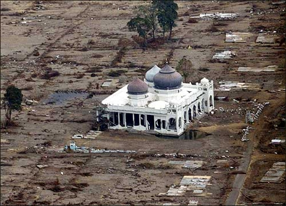

Her er et billede af en anden moske et andet sted.

[figure not shown]

Her er et billede af den første moske, men fra et andet perspektiv.

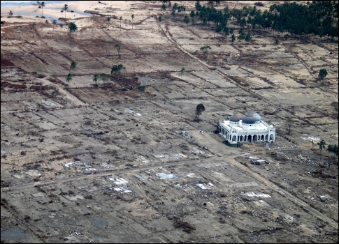

### Ting der kan påvirke Allahs bestemmelser

I følge ulama findes det nedskrevne og forudbestemte i to slags. Den ene slags kan ikke ændres, og det er det som Allah (swt) har skrevet i Al-Lawh Al-Mahfudh (forudbestemmelsernes bog), 50.000 år før Han (swt) skabte mennesket (sådan som nogle ahadith fortæller). Den anden slags er det som englene nedskriver, dette kan ændres, og resultatet nedskrives i sidste ende også i Al-Lawh Al-Mahfudh. Beviset på dette ligger i følgende Koranvers: “**Allah udsletter hvad Han vil, og bekræfter (hvad Han vil). Og hos Ham er bogens moder (Al-Lawh Al-Mahfudh).**” (13:39).

Det er derfor Umar bin al-Khattab (raa) plejede at sige:

> O Allah! Hvis du har fastlagt at jeg er fordømt, så slet det og fastlæg at jeg hører til dem, der er velsignet, fordi Du udsletter hvad du vil, og Du bekræfter hvad Du vil.

Og det berettes fra Salman Farsi (raa) at Profeten (saaws) sagde: “*Intet kan ændre det forudbestemte undtagen bønnen.*” (Tirmidhi).

#### Forventninger og tanker

“Loven om tiltrækning”, der er formuleret i New Thought bevægelsen som en form for naturlov, og hvor man misbruger kvantefysiken til at legitimerer denne ide, findes ikke i Islam. Ydermere er det også meget tydeligt blot igennem observation at der i mange situationer hvor forskellige begivenheder indtræffer aldrig nogensinde har fundet nogen tanke eller forestilling sted før begivenheden indtraf. F.eks. kan et lille barn ikke have tiltrukket at blive seksuelt misbrugt eller at blive alvorligt syg med f.eks. cancer.

Alligevel er ideen om “loven om tiltrækning” ikke ramt helt ved siden af fordi Islam lærer os at forventninger og tanker kan have en meget stor påvirkning på det som Allah (swt) vælger at bestemme, og forventninger og tanker er kernen i emnet om at-tawakkul.

Allah (swt) siger: “**Og blandt beduinerne er der den der anser det, som han betaler, som en bøde og som venter på at ondt skal ramme jer. På dem skal det onde ramme. Og Allah er Althørende, Alvidende. Men blandt beduinerne er der også den der har iman på Allah og Den Sidste Dag, og som anser det, som han betaler, for noget der bringer ham nærmere Allah og Sendebudets velsignelser. Sandelig, det er visselig noget der bringer dem nærmere. Allah vil snart føre dem ind i sin Barmhjertighed, thi Allah er Tilgivende, Barmhjertig.**” (9:98-99).

Begge omtalte grupper af beduiner betaler den obligatoriske almisse, men den første gruppe betragter det som en byrde og en straf, og de ønsker at ondt skal ramme de der indsamler den, mens den anden gruppe betragter betalingen af almisser som værende et middel til at søge Allahs nærhed og Sendebuddets velsignelse. Den eneste forskel på disse to grupper var de tanker de gjorde sig om Allahs lov.

Profeten Muhammad (saaws) besøgte en syg mand der led under høj feber, han forsøgte at trøste ham ved at sige: “*Der sker ingen skade, det er en renselse ved Allahs Vilje!*” Den syge mand sagde: “*Nej, det er en feber der brænder i en gammel mand, og den vil bringe ham til graven.*” Profeten (saaws) sagde: “*Ja, så vil det være det!*” (Bukhari).

På Hunayndagen satte mange muslimer håb i hærens størrelse fremfor i Allah (swt), og de forventede at det var denne materiale ting, altså hærens størrelse, der ville bringe dem sejr, og de glemte at sejr udelukkende kommer fra Allah (swt). Til dette berettes det bl.a. fra Anas (raa) at han sagde: “*På Hunayndagen var der en mand der sagde: ‘Vi vil aldrig lide tab i dag på grund af vore store antal!’ Dette bekymrede Profeten (saaws) og så blev vi slået.*”

Og Allah (swt) siger: “**Allah har allerede hjulpet jer på mange slagpladser, og i slaget ved Hunain, da jeres store antal gjorde jer stolte, men de nyttede jer intet, og jorden blev jer trang i (al) dens vidde, og så vendte I jer om i flugt.**” (9:24).

Det berettes fra Abu Hurairah (raa) at Profeten (saaws) sagde: “*At være i besiddelse af gode tanker er en del af fremragende tilbedelse!*” (Abu Dawud).

Og det berettes fra Abu Darda (raa) at han sagde: “*Jeg hørte Profeten (saaws) sige: Der findes ikke noget der vil blive placeret på Vægten, og som vil veje tungere end en god forventning. Den der har en god forventning, vil modtage en status svarende til den der faster meget og beder meget.*” (at-Tirmidhi).

Og det berettes af Wathilah bin al-Aqsa (raa) at Profeten (saaws) sagde: “*Allah, den Almægtige, den Ophøjede sagde: Jeg er som Min tjener tænker om Mig, hvis han tænker godt, får han det, og hvis han tænker dårligt, får han det.*” (Ahmad og Ibn Hibban).

Nogle af de lærde har kommenteret den ovenstående hadith således:

> Jeg behandler Min tjener ud fra det han tænker om Mig. Jeg handler mod ham sådan som han forventer, hvad angår godt eller det modsatte.

Fra Abu Hurairah (raa) berettes det at Profeten (saaws) sagde (forkortet): “*Allah sagde: Jeg er i Min tjeners nærhed når han tænker på Mig, og Jeg handler mod ham sådan som han tænker.*” (Bukhari, Muslim, Tirmidhi og Ibn Majah).

Det berettes også at Profeten (saaws) sagde: “*Allah den Almægtige sagde: ’Jeg er som Min tjener tænker om Mig, lad ham tænke om Mig det som han ønsker. Hvis han tænker godt om Mig, så vil han få det, og hvis han tænker dårligt om Mig, så vil han få det.*” (Ibn Majah).

Ibn Hajar (rha) sagde:

> Det betyder: “Jeg er i stand til at gøre hvad han end forventer at Jeg gør.” (Fath al-Bari).

Ibn al-Qayyim (rha) sagde:

> De fleste mennesker, faktisk næsten alle - undtagen dem der er beskyttet af Allah - forventer andet end sandheden, og de forventer det værste. De fleste mennesker forventer at de vil få frataget deres rettigheder, at de vil få ulykker, at de fortjener mere end det Allah har givet dem, og det er som om de siger: “Min Herre har været uretfærdig imod mig, og har frataget mig det jeg fortjener”, og hans sjæl bærer vidne om dette, mens hans tunge benægter det, og han nægter at sige dette højt.

> Den der graver ind til sin sjæl, og som kommer til at kende den, vil finde dette derinde som en ild fra en eksplosion. Og hvis du graver ind til en anden persons sjæl, så vil du se at han bebrejder forudbestemmelserne, og at han hellere vil have at noget andet skal ske, og at ting skal være på en anden måde!

> Så grav ind til din egen sjæl! Er du fri fra dette? Hvis du er fri fra det, så er du blevet beskyttet imod noget stort, men ellers ser jeg ikke at du er blevet beskyttet! (Zad ul-Ma’ad).

Ibn al-Qayyim (rha) sagde også:

> Den der håber på noget fra Allah skal altid være optimistisk, forsigtig, og håbefuld om Allahs Nåde. Og han skal forvente det bedste fra Ham. (Tahdhib Madarij as-Salikin).

Sayyid Qutb (rha) sagde:

> Den overbevistes hjerte antager det bedste om sin Herre, og forventer altid det bedste fra Ham. Han forventer godt fra Ham i tider med lethed og i tider med besværligheder, og han tænker at Allah ønsker godt for ham i begge situationer. Hemmeligheden bag dette er at hans hjerte er forbundet til Allah, og strømmen af godt fra Allah aldrig bliver afskåret. Så når hjertet er forbundet til Ham, så berører det denne grundlæggende virkelighed og oplever det på en direkte og sød måde. (Fi Dhilal al-Quran).

Abdullah bin Masud (raa) sagde:

> Ved Ham, udover hvem ingen fortjener tilbedelse, den overbeviste får ikke noget bedre end at han forventer godt fra Allah, og ved Ham, udover hvem ingen fortjener tilbedelse, ingen tjener af Allah forventer godt fra Ham undtagen at Allah giver ham det, han forventer, eftersom alt godt er i Hans Hænder. (Husn adh-Dhann bi Allah).

Ahmad bin Naqib al-Misri nævner i sin bog Umdat As-Salik fra Ibn Ataillah:

> At tænke det bedste om Allah! Hvor enormt er det ikke for den som Allah har velsignet med det. Den som har det mangler aldrig noget godt, og den som mangler det, vil aldrig finde noget (godt). Du vil aldrig have en bedre undskyldning overfor Allah, ej heller en mere indbringende. Ej heller noget der bedre leder dig til Allah, eller som er mere vejledningsgivende. Den informerer om hvad Allah vil gøre en til, og bringer godt nyt som intet øje har set ej heller nogen tunge har udtalt (inspiration fra Allah). Dette er fundet i Profetens (saaws) ord: “*Jeg (Allah) er som Min tjener tænker om Mig.*”

Det berettes at Profeten (saaws) besøgte en syg person og sagde: “*I hvilken tilstand finder denne sygdom dig?*” Manden svarede: “*Jeg har håb i Allah, og jeg frygter mine synder.*” Profeten (saaws) sagde: “*Disse to ting finder aldrig sammen i hjertet på en tjener undtagen at Allah skænker ham det som han håber, og redder ham fra det som han frygter.*” (Tirmidhi, Ibn Majah og Nasai).

Det berettes fra Jabir (raa) at han sagde: “*Tre dage før Profeten (saaws) gik bort sagde han til sine Sahabah: ‘Lad ingen af jer dø undtagen at I håber på det bedste fra Allah, Den Mægtige, Den Lovpriste.’*” (Muslim).

Allah (swt) siger: “**Satan يَعِدُكُمُ (yaidukumu) {lover jer, truer jer med} الْفَقْرَ (al-faqra) {fattigdom, nød, katastrofe, behov} og påbyder jer skændighed, men Allah يَعِدُكُمْ (ya’idukum) {lover jer} tilgivelse وَفَضْلًا (wafadlan) {og overlevelse, overskud, overflod, gavn}. Og Allah er Gavmild og Alvidende.**” (2:268).

Ordet يَعِدُكُمْ (ya’idukum) kommer fra roden وعد (waw ayn dal) der betyder “at give løfte om”, “at give ord på” og “at true”.

Så på den ene side har vi Satans hvisken om fattigdom, nød, katastrofer og forskellige ting som vi frygter, og disse tanker indeholder også spørgsmål med tvivl som f.eks. “men hvordan skulle Allah kunne hjælpe?”, “men hvorfra skal hjælpen komme?”, “se på din situation, det kan kun blive værre!”, “det er altid sådan for dig!” osv., men på den anden side har vi Allahs (swt) løfte i Koranen om overlevelse og overflod: “**Allah يَعِدُكُمْ (ya’idukum) {lover jer} tilgivelse وَفَضْلًا (wafadlan) {og overlevelse, overskud, overflod, gavn}**”.

Ud fra disse to modpoler bestemmer vi hvad vi lader dominere vore tanker, følelser og forventninger. Og hvis vi er i tvivl om hvilke der styrer vores dagligdag, så skal vi blot observere vores følelser. Hvis vi føler angst og bekymring til dagligt, så forventer vi negative ting, og så har vi ladet Satans trusler dominere over Allahs (swt) løfter.

Allah (swt) siger: “**Og den der yat-taqi Allaha (er from overfor Allah), Allah vil åbne en vej for ham, wayarzuqhu (og vil forsyne ham) fra et sted han end ikke kunne forestille sig, og den der ya-tawakkul ala Allah (stoler på Allah), Han vil være nok for ham. Allah bringer Sine bestemmelser til udførelse. Allah har visselig for alle ting skabt qadran (en bestemmelse).**” (65:2-3).

Når vi ikke stoler på Allah (swt), men derimod forventer at det Satan truer os med indtræffer, så skal vi huske hadithen: “*Jeg er som Min tjener tænker om Mig, lad ham tænke om Mig det som han ønsker. Hvis han tænker godt om Mig, så vil han få det, og hvis han tænker dårligt om Mig, så vil han få det.*”

Det berettes fra Talq at en mand kom til Abu ad-Darda (raa) og sagde, “O Abu ad-Darda, dit hus er brændt ned!” Abu ad-Darda (raa) svarede, “Det kan ikke være brændt ned!”. En anden person kom med den samme nyhed, og igen svarede Abu ad-Darda (raa), med sikkerhed i stemmen, “Det kan ikke være brændt ned!”. En tredje person kom til ham og sagde: “O Abu ad-Darda! En brænd rasede, men den gik ud så snart den nåede dit hus.” Abu ad-Darda (raa) sagde, “Jeg vidste at Allah aldrig ville lade mit hus brænde ned!” Nogle mennesker der havde hørt Abu ad-Dardas udtalelser sagde, “O Abu ad-Darda! Vi ved ikke hvilke af dine ord der er mest forundrende. Om det er ‘det kan ikke være brændt ned’ eller ‘jeg vidste, at Allah aldrig ville lade mit hus brænde ned.’ Abu ad-Darda (raa) sagde,”Det skyldes nogle ord som jeg har hørt fra Allahs Sendebud. Den der fremsiger dem om morgenen, vil ikke lide under en katastrofe indtil om aftenen." Abu ad-Darda (raa) berettede derefter bønnen: “*O Allah! Du er min Herre! Der er ingen der fortjener tilbedelse undtagen Dig. Jeg stoler på Dig, og Du er Herren over den mægtige Trone. Hvad som helst som Allah ønsker skal ske, det sker, og det som Han ikke ønsker skal ske, kan aldrig ske. Der findes ingen magt og ingen styrke undtagen hos den Høje og Majestætiske Allah. Jeg ved at Allah har magten over alting, og at Han ved alting. O Allah! Jeg søger din beskyttelse fra det onde i mig, og fra det onde fra enhver skabning som du har magt over. Sandelig, min Herre er på den rette vej. (Den der retleder til den rette vej).*”

Det berettes fra Anas (raa) at Ar-Rabi, an-Nadrs datter, slog hendes tjenestepige så hendes tand flækkede. Familien til pigen krævede gengældelse. Familien til Ar-Rabi bad pigens familie om tilgivelse og spurgte om de ikke ville acceptere erstatning i stedet for gengældelse, men det nægtede de og fastholdte kravet om gengældelse. Anas bin an-Nadr, der var Ar-Rabis bror, gik til Profeten (saaws) og spurgte ham: “*O Allahs Sendebud! Vil Ar-Rabis tand blive flækket som gengæld?*” Profeten (saaws) svarede: “*O Anas! Allahs lov er gengældelse!*” Anas (raa) sagde: “*Nej! Ved Ham der har sendt dig med sandheden, hendes tand vil ikke blive flækket!*” Præcis da Anas havde udtalt denne ed kom pigens far ind af døren. Han accepterede erstatning og tilgav Ar-Rabi. Profeten (saaws) smilede og sagde: “*Sandelig, der er nogle af Allahs tjenere der når de sværger ved Allah, så skænker Allah dem det de ønsker!*” (Bukhari og Ibn Majah).

Denne beretning betyder ikke at Anas (raa) var ulydig overfor Allahs (swt) lov, eller at han ikke ville acceptere Profetens (saaws) dom. Anas kunne ikke udholde tanken om at Ar-Rabi skulle have flækket sin tand som straf, derfor bad han til Allah (swt) ved at sværge med fuld og fast besluttende overbevisning om at Allah (swt) ville forhindre det. Og ganske rigtigt påvirkede Allah (swt) An-Nadr (raa) så han og familien valgte at tilgive Ar-Rabi.

#### Dua (bøn)

Allah (swt) siger: “**Påkald Mig og Jeg vil svare jer.**” (40:60).

Og Allah (swt) siger: “**Sig: ‘Påkald Allah eller påkald Den Nådige. Uanset hvilket navn i påkalder Ham med, så tilhører de Skønneste Navne Ham.’**” (17:110).

Og Allah (swt) siger: “**Og hvis Mine tjenere spørger dig om Mig: Jeg er sandelig nær! Jeg hører og svarer bønnen af enhver ydmyg bedende når han påkalder Mig. Lad dem også godvilligt lytte til Mit kald, og være overbeviste om Mig, sådan at de må vandre på den rette vej.**” (2:186).

Og Allah (swt) siger: “**Og Han svarer dem der har iman, og som handler retskaffent, og forøger Hans Nåde for dem. Og til kafiruna (benægterne) vil der være en streng straf.**” (42:26).

Og det berettes fra Abu Hurairah (raa) at Profeten (saaws) sagde: “*Bed til Allah med overbevisning om at Han vil svare den.*” (Tirmidhi).

Fra Abu Hurairah (raa) berettes det også at Profeten (saaws) sagde: “*Tjenerens bøn bliver skænket såfremt han ikke beder om synd eller om noget ødelæggende for slægtskabet, og hvis han ikke er hastig. Det blev spurgt: O Allahs sendebud, hvad vil det sige at være hastig? Han (saaws) svarede: At være hastig er at en person siger: Jeg har bedt meget, for meget, men jeg ser at min bøn ikke er svaret. Sådan at han bliver træt af det og opgiver.*” (Muslim).

Og det berettes fra Abu Hurairah (raa) at Profeten (saaws) sagde: “*Når en af jer beder til Allah, så skal han bede med beslutsomhed, og han skal ikke sige: ‘O Allah skænk mig hvis Du vil’, for der er ingen der kan tvinge Allah.*” (Muslim).

Og det berettes fra Abu Hurairah (raa) at Profeten (saaws) sagde: “*Når en af jer beder en bøn, så skal han ikke sige: ‘O Allah, tilgiv mig hvis du vil’, derimod skal han bede sin Herre med beslutsomhed og fuld hengivenhed for der er ikke noget der er så stort i Allahs øjne, at Han ikke kan skænke det.*” (Muslim).

# الرزق - Ar-Rizq (Levebrødet)

## Den sproglige betydning af الرزق - Ar-Rizq (Levebrødet)

Termen الرزق - Ar-Rizq kommer fra roden رزق razaqa der sprogligt betyder “levebrød”, “forsyning”, “at give midler til underhold”, “at skænke”, “at velsigne”, “det daglige brød”, m.m.

## Den åbenbaringsmæssige betydning af الرزق - Ar-Rizq (Levebrødet)

Den åbenbaringsmæssige betydning af الرزق - Ar-Rizq handler om at modtage sit levebrød og sine midler til underhold og overlevelse. Alle aspekter af en persons eksistens hører under begrebet “ar-rizq”. I nogle Koranvers omtaler Allah (swt) regn og frugter som rizq, og dette viser os at rizq er noget mere generelt end penge. Rizq omfatter enhver form for forsyning og enhver form for levebrød.

## Rizq kommer udelukkende fra Allah (swt)

En af Allahs (swt) attributter er Ar-Razzaq hvilket betyder, at Allah alene er Den, der skaber, og skænker levebrød og forsyning.

Allah (swt) siger: “**Og der findes ikke et eneste levende væsen på Jordens overflade undtagen at rizquha (dets forsyning) påhviler Allah. Han kender dets opholdssted og dets gemmested. Alt er i en tydelig bog.**” (11:6).

Og Allah (swt) siger: “**Vi beder dig ikke om rizqan (forsyning). Vi narzuquka (giver dig forsyning). Og den lykkelige afslutning vil tilkomme den fromme.**” (20:132:).

Og Allah (swt) siger: “**Er det dem der uddeler af din Herres Barmhjertighed? Det er Os der uddeler deres forsyning til dem i livet i denne verden, og vi hæver nogle af dem i rang over andre, så nogle af dem ser ned på andre. Men din Herres Barmhjertighed er bedre end det de samler sammen.**” (43:32). Verset kan også oversættes som: “**..og vi hæver nogle af dem i rang over andre, så nogle af dem tvinger andre til tjeneste.**”

Her er ordet “uddeler” oversat fra قَسَمْنَا (qasamnaa) der bl.a. betyder “disponere”, “adskille”, “uddele”, “distribuere” og “fordele”. Og ordet “levebrød” er oversat fra مَعِيشَتَهُمْ (maishatahum) der bl.a. betyder “den tid man har fået til at leve”, “at søge forsyning eller levebrød”, “at leve på en bestemt måde (dvs. livsstil forårsaget af velstand eller fattigdom)”, “levebrød”, “tiden der bruges på at søge levebrød”, “midlerne til at opnår det der skal bruges for at overleve”, m.v.

Allah (swt) siger: “**Allah er Gavmild mod Sine tjenere. Yarzuqu (Han giver forsyning) til hvem Han vil, og Han er Stærk, Den Mægtige.**” (42:19).

Og Han (swt) siger: “**Og Allah yarzuqu (giver forsyning) uden regnskab til hvem Han vil.**” (24:38). Dvs. nogle mennesker får sågar levebrød, ejendom og rigdom af Allah (swt) uden at de bliver stillet til regnskab for det.

Og Allah (swt) siger: “**Og hvor mange dyr findes der ikke, som ikke bærer på rizqaha (dets forsyning). Allah yarzuquha (giver forsyning) til dem wa-iyyakum (og til jer). Og Han er den Althørende, den Altvidende.**” (29:60). Dette henviser til de mange dyr som ikke har forråd, men Allah (swt) giver dem forsyning.

Og Han (swt) siger: “**Sig: Visselig min Herre wayabsutu (skænker overflod) til den Han vil af Sine tjenere, wayaqdiru (og formindsker eller begrænser) for ham. Og hvad som helst I giver ud, vil Han give igen, og Han er den bedste ar-raaziqiina (Forsørger).**” (34:39).

Og Han (swt) siger: “**Allah forøger ar-rizqa (forsyningen) for hvem Han vil af Sine tjenere og wayaqdiru (og formindsker eller begrænser) den for ham. Sandelig, Allah ved alle ting.**” (29:62).

Og Han (swt) siger: “**Ser de ikke at Allah forøger ar-rizqa (forsyningen) og wayaqdiru (og formindsker eller begrænser) den for hvem Han vil? Sandelig, heri er der visselig beviser for folk der har iman.**” (30:37).

Og Han (swt) siger: “**Sig: ‘Min Herre forøger og wayaqdiru (og formindsker eller begrænser) ar-rizqa (forsyningen) for hvem Han vil, men de fleste mennesker ved det ikke.’**” (34:36).

Og Allah (swt) siger: “**Og den der yat-taqi Allaha (er from overfor Allah), Allah vil åbne en vej for ham, wayarzuqhu (og vil forsyne ham) fra et sted han end ikke kunne forestille sig, og den der ya-tawakkul ala Allah (stoler på Allah), Han vil være nok for ham. Allah bringer Sine bestemmelser til udførelse. Allah har visselig for alle ting skabt qadran (en bestemmelse).**” (65:2-3).

I sammenhæng med ovenstående vers berettes det fra Imran bin Husain (raa) at Profeten (saaws) sagde: “*For den person der stoler på Allah, så vil Allah være tilstrækkelig til at tage sig af alle personens behov. Rizq vil blive modtaget fra sådanne kilder som personen end ikke kan forestille sig. Den person der stoler på den materielle verden, Allah overlader en sådan person til verdenen.*”

Og Allah (swt) siger: “**Og dræb ikke jeres børn på grund af fattigdom, Vi vil narzuqukum (forsyne jer).**” (6:151). Dette betyder ikke at børn ikke kan dø af sult og fattigdom, men at eftersom det er Allah (swt) der fastlægger og bestemmer, så vil børnenes tilstedeværelse eller død ikke have nogen effekt på det forældrene får. Eller sagt med andre ord så får de mennesker der slår deres børn ihjel på grund af frygt for fattigdom ikke mere til dem selv af den grund.

Og Allah (swt) siger: “**Hvis Allah havde forøget ar-rizqa (forsyningen) til Sine tjenere, så ville de visselig have begået oprør på jorden, men Han sender hvad Han vil i overensstemmelse med biqadarin (en bestemmelse). Han kender og ser Sine tjenere.**” (42:27).

Og Allah (swt) siger: “**Lad den rige give ud af sin rigdom, og den qudira alayhi rizquhu (der er begrænset i forsyning på grund af en bestemmelse), lad ham give ud af det Allah har givet ham. Allah bebyrder ingen ud over evne. Allah vil skænke lettelse efter besværligheder.**” (65:7).

Og Allah (swt) siger: “**Men når Han prøver ham og indskrænker rizqahu (hans forsyning), så siger han, ‘Min Herre har ydmyget mig.’**” (89:16).

Disse Koranvers efterlader ikke nogen mulighed for misforståelse eller tvivl idet betydningen af versene er entydige. Allah (swt) er - i ordets bogstavlige forstand - Den der aktivt bestemmer alt hvad et menneske skal eje ned til den mindste partikel. Alt hvad der opnås igennem de handlinger som mennesket udfører i sin stræben efter tilegnelse af rigdom, materielle ting og andet bestemmes af Allah (swt). Intet kan opnås undtagen det som Allah (swt) bestemmer, og intet kan undgås af det som Allah (swt) fastlægger skal komme til en person.

I surah Al-Kahf finder vi historien om manden der havde fået skænket to store haver som han praler med. Allah (swt) siger: “**Og fortæl dem eksemplet med de to mænd. Vi gav den ene af dem to haver med druer, og omgav dem med daddelpalmer, og mellem de to lagde Vi en kornmark. Hver af de to haver gav sit udbytte, og svigtede ikke det mindste heri. Og mellem dem lod Vi en flod strømme frem. Og han havde frugter, og i en samtale sagde han til sin kammerat: ‘Jeg har større rigdom end du har, og jeg er mægtigere i følgeskab.’ Og han trådte ind i sin have idet han handlede uret imod sig selv. Han sagde: ‘Jeg tror ikke dette nogensinde skal forgå. Og jeg tror ikke at timen skal komme, og selvom jeg også blev sendt tilbage til min Herre, så ville jeg visselig finde et bedre sted end dette.’ Hans kammerat sagde til ham, idet han diskutterede med ham: ‘Fornægter du Ham der skabte dig af støv, derpå af en sæddråbe, og som formede dig til en mand? Hvad mig angår, så er jeg overbevist om at Allah er min Herre, og jeg sætter ikke en eneste ved siden af min Herre. Og hvorfor sagde du ikke, da du trådte ind i din have: Kun det Allah vil (er blevet mig skænket)! Der er ikke nogen magt undtagen i Allah. Hvis du ser mig fattigere end dig på rigdom og følgeskab, så vil min Herre måske give mig noget bedre end din have, og vil sende en storm over den fra himlen så den skal blive til ufrugtbar glat jord. Eller dens vand vil synke så du ikke kan få fat i det.’ Og hans frugter blev omfattet (af ødelæggelse), og han begyndte at vride sine hænder (i ærgelse) over det han havde brugt på haven nu da den lå sammenstyrtet på sine stilladser. Og han sagde: ‘O gid jeg ikke havde stillet nogen ved siden af min Herre!’**” (18:32-42).

Efter manden havde pralet med sin rigdom sagde hans kammeret til ham: “**Og hvorfor sagde du ikke, da du trådte ind i din have: Kun det Allah vil (er blevet mig skænket!)**”, det var det manden skulle have sagt, men i stedet fornægtede han Allah (swt), og mente at han var rig af andre grunde.

Hvad angår følgende Koranvers: “**Og giv ikke de svagtbegavede jeres ejendom, som Allah har skænket jer til deres underhold, wa-urzuquhum (men giv dem levebrød) dermed og klæd dem og tal til dem med gode ord.**” (4:5). Så siger dette vers ikke at levebrødet kom fra mennesket, dvs. det oprinder ikke hos mennesket, således at et menneske giver et andet menneske levebrød. Derimod siger verset at levebrødet, det der her skal gives videre, oprindeligt er skænket af Allah.

Og hvad angår Koranverset: “**Og når slægtninge, forældreløse og fattige er tilstede ved arvedelingen, fa-urzuquhum (så forsyn dem) deraf og tal et passende ord til dem.**” (4:8). Så taler dette vers heller ikke om at levebrødet kommer fra mennesket, verset taler derimod om at give andre af den rizq, som man selv har modtaget af Allah (swt) - i dette tilfælde via arv.

Det er derfor obligatorisk og nødvendigt at have iman på at rizq udelukkende kommer fra Allah (swt), og at Han (swt) skænker rizq til alle Sine skabninger.

Det berettes i en hadith fra Anas (raa) at Profeten (saaws) sagde: “*Enhver af jer bør bede Allah om sine behov, selv hvis stroppen på sandalen knækker, for hvis Allah ikke frembringer det, så vil det aldrig være muligt.*” (Tirmidhi).

Det berettes i en hadith fra Jabir (raa) at Profeten (saaws) sagde: “*O mennesker! At-taqu Allaha (vær fromme overfor Allah) og søg jeres forsyning på moderat vis for ingen vil dø førend han har opbrugt sin forsyning, selv hvis den kommer langsomt. Så at-taqu Allaha (vær fromme overfor Allah) og søg jeres forsyning på moderat vis og tag kun det der er lovligt, og forlad det der er ulovligt.*” (Ibn Majah).

## Vores indsats og stræben er aldrig årsagen til rizq

De fleste mennesker tror at den rigdom de er kommet i besiddelse skyldes deres egen indsats og planlægning, men dette er helt forkert. Mennesket kan planlægge og arbejde, men det er Allah (swt) der bestemmer resultatet.

Korah var en meget rig mand der levede på Moses (asws) tid, og som betragtede sin rigdom som værende noget han havde tilegnet sig på grund af den viden han var i besiddelse af. Allah (swt) siger: “**Visselig, Korah var fra Moses folk, men han undertrygte dem. Og Vi gav ham sådanne skatte at selv nøglerne dertil var en byrde for en stor gruppe meget stærke mænd! Da hans folk sagde til ham: ‘Pral ikke! Visselig, Allah elsker ikke den der praler! Men søg via det Allah har skænket dig, den Kommende Verdens hjem, og glem heller ikke din del i denne verden. Og handel godt, ligesom Allah har været god mod dig. Og søg ikke efter korruption på jorden. Visselig, Allah elsker ikke de korrupte.’ Han sagde: ‘Visselig, disse ting er kun skænket mig på grund af den viden jeg er i besiddelse af!’ Vidste han ikke at Allah visselig har tilintetgjort generationer før ham der var stærkere end ham i styrke, og større end ham i rigdom? Og de kriminelle vil ikke blive udspurgte om deres synder! Så gik han ud til sit folk i pomp og pragt. Og de der begærede livet i denne verden sagde: ‘O gid vi dog var blevet skænket det samme som det der er blevet skænket til Korah. Visselig, han ejer en stor formue!’**” (28:76-79)

Allah (swt) siger derefter: “**Så lod Vi jorden sluge ham og hans hjem. Og der var ingen gruppe der kunne hjælpe ham foruden Allah, og han hørte ikke til dem der kunne forsvare sig selv. Og de som havde begæret hans position dagen i forvejen sagde, ‘Ve os! Allah forøger wayaqdiru (og formindsker eller begrænser) ar-rizqa (forsyningen) til hvem Han vil af Sine tjenere. Hvis Allah ikke havde været os nådig, ville Han have ladet den (jorden) sluge os. Ve os, benægterne har ikke succes.’**” (28:81-82).

Og Allah (swt) siger: “**I tilbeder kun ved siden af Allah gudebilleder, og I opdigter en løgn, thi de, som I tilbeder ved siden af Allah, har ikke magt til at skænke jer nogen forsyning. Søg da forsyning hos Allah, og tjen Ham og vær taknemmelige mod Ham. Til Ham skal I sendes tilbage.**” (29:17).

Hvis det forholder sig sådan at midler og metoder skulle være årsagen til rizq, så ville de samme midler, metoder og omstændigheder altid give det samme resultat, men det er meget tydeligt at dette slet ikke er tilfældet, og succes angående rizq ligger udenfor vores kontrol. Hvis det ikke gjorde det, ville vi kunne gøre os selv til millionærer når vi kendte til “hemmeligheden”.

Her bliver det relevant at spørge: Hvad skal jeg så gøre hvis jeg er fattig, og mangler forsyning og levebrød?

Til dette siger Allah (swt): “**Han er Den der underkastede jer jorden. Gå derfor omkring på den og spis af rizqihi (dens forsyning). Og til Ham er Opstandelsen.**” (67:15). Og Han (swt) siger: “**Og når bønnen er afsluttet så spred jer i landet og søg efter Allahs fadli (Nåde) og ihukom Allah meget for at I må få succes.**” (62:10).

Disse vers (og andre) fortæller os at vi skal “søge” efter rizq. Og “at søge” betyder at vi forsøger, indenfor rammerne af naturlovene og de forhold vi har kontrol over, at finde noget vi kan bruge.

En sådan søgen efter rizq kan være simpel og blot bestå i at lede efter nogle frugter eller at fiske efter nogle fisk, men den kan også bestå i handel eller i at tilbyde andre mennesker sin arbejdskraft osv.

Et andet relevant spørgsmål kan være: Hvor aktiv skal jeg være i min søgen?

Svaret er at du stræber indtil du har opnået det du ønsker (eller noget tilsvarende eller bedre). Eller indtil du ikke kan gøre mere.

Personen der ligger i koma foretager ingen handlinger, og det gør spædbarnet heller ikke. Allah (swt) ikke alene forsyner disse via andre mennesker, men holder sågar disse i live via andre mennesker. Og hvis Allah (swt) har forsynet dig med enorm rigdom, f.eks. fordi du er vokset op med rige forældre, og du har tjenere i dit hus til at passe dig op, så behøver du måske udelukkende at tygge maden da andre mennesker måske ikke alene vil tilberede maden for dig, men de vil måske sågar servere den for dig.

Dette viser at handling og søgning udelukkende er påkrævet når du mangler noget, og udelukkende fordi Allah (swt) befaler handling. Dette betyder også at det bliver obligatorisk at skaffe mad, forberede den, og at føre den op til munden, tygge på den og synke den - når du altså ikke har tjenestefolk der kan varte dig op til sådan en grad.

Man kunne tro at det er korrekt at sige, at ingen person er blevet rig af at sidde stille, men dette er forkert fordi nogle mennesker bliver voldsomt rige uden så meget som at løfte en finger, f.eks. ved at arve eller vinde penge.

Allah (swt) siger: “**Du ved det ikke, men Allah kan meget vel forårsage at noget nyt sker.**” (65:1).

Realiteten viser at du typisk ikke kan blive virkelig rig af at arbejde for andre som en almindelig ansat. Dette skyldes at det dels via naturlovene er begrænset hvor mange timer i døgnet du kan arbejde, og at det dels er begrænset via samfundsforhold hvor meget dit arbejde er værd. I sådan en situation er du nød til at “fjerne” disse begrænsninger, f.eks. ved at oprette dit eget firma hvor du så tilbyder den samme serviceydelse, men nu har du muligheden for at forøge antallet at timetal ved at ansætte andre mennesker til at udføre det samme arbejde som dig selv, men hvor du nu betaler dem, og selv beholder et overskud.

Hvad bestemmer så om dit produkt eller din serviceydelse får succes? Svaret er at noget af dette ligger i Allahs (swt) bestemmelser, og noget af dette har Han (swt) givet dig kontrol over. Du kan jo f.eks. ikke spise sten fremfor æbler, og du kan f.eks. normalt heller ikke sælge helt ubrugelige ting som råddent affald til folk og forvente at de er interesserede i at handle med dig, og alt dette tvinger sharia dig til at tage hensyn til i dine bestræbelser - når du mangler rizq, og har brug for at søge efter den.

Hvis Allah (swt) fastlægger en stor rizq til dig, så vil Han (swt) måske påvirke folk til at se igennem fingre med et middelmådigt produkt eller en dårlig service, sådan at folk nærmest kommer strømmende til dig for at handle med dig, men hvis Han (swt) kun fastlægger en meget lille rizq til dig, så vil selv et supergodt produkt eller en super god service sælge meget dårligt uanset hvad du gør.

## Spørgsmål relateret til rizq

**Spørgsmål**: “En person indsamler rizq på en haram (forbudt) måde, som f.eks. ved at sælge narkotika eller alkohol, men hvis han i stedet stræbte efter sin rizq på en halal (tilladt) måde, ville han så få den samme mængde rizq?”

**Svar**: Svaret på spørgsmålet er at vi ikke kan vide om personen ville få det samme eller ej. Årsagen er at dette hører under al-ghaib (det usanselige). Rizq afhænger altid af hvad Allah (swt) bestemmer, og da vi ikke ved hvad Allah (swt) ville have bestemt, hvis personen handlede anderledes, så kender vi ikke resultatet.

Det vi kan sanse i realiteten er at en person kan skifte fra halal til haram og opleve en nedgang i sin rizq, og det modsatte kan også gøre sig gældende.

I nogle tilfælde tester Allah (swt) en person med dette. Personen beslutter sig for at lade være med at sælge forbudte ting, og begynder i stedet at sælge tilladte ting. Som resultat bestemmer Allah (swt) at personen får en mindre rizq sådan at Han (swt) kan teste personens forholdelse til islam.

**Spørgsmål**: “Hvordan påvirker Allah (swt) mennesker til handling uden at tvinge dem?”

**Svar**: Dette hører også under al-ghaib (det usanselige), og vi kan derfor ikke beskæftige os med emnet ud fra realiteten. Men vi får nogle eksempler fra Allah (swt) i Koranen, og det er det eneste vi kan forholde os til. Allah (swt) siger: “**Sig: ‘Han al-qadirun (kan bestemme) en straf over jer fra ovenover, eller fra under jeres fødder, eller forvirre jer så I bliver til sekter og så lade jer smage hinandens vold.’ Se, hvorledes Vi gør tegnene tydelige, for at de må forstå.**” (6:65).

Vi kan ikke sanse hvordan Allah (swt) forvirrer mennesker så de bliver til sekter og yder vold imod hinanden, men vi kan sanse resultatet af dette.

Imam Jilani (rha) beskriver Allahs påvirkninger på mennesker i forskellige situationer således:

> Hvis det er et spørgsmål om gæld, så vil Han påvirke kreditorens hjerte så han vender sig fra at presse hårdt, for at få gælden betalt, til at han bliver mild mod dig, så du får udskudt gælden indtil en tid, hvor det bliver let for dig at betale. Eller Han vil påvirke kreditoren med et humør der gør, at han helt eftergiver gælden eller reducerer den. (Futuh al-Ghaib).

**Spørgsmål**: “Hvis Allah (swt) er Den der giver rizq, hvorfor er det så tilladt at stjæle når man lider nød? Eller f.eks. at spise svinekød?”

**Svar**: Alt hvad der kommer til dig, uanset om det kommer på tilladt vis eller på forbudt vis, eller om det kommer via midler der normalt er forbudte, men i en given situation bliver tilladte, eller via midler der normalt er tilladte, men i en anden situation bliver forbudte, er alt sammen en del af din rizq.

En person der stjæler, uanset om det er tilladt for ham at stjæle eller ej, så er det han opnår, hans rizq. Og personen der spiser svinekød, uanset om det er tilladt eller forbudt i hans tilfælde, så er svinekødet hans rizq.

Allah (swt) bestemmer altid hvad du får lov til at få.

## Ting der påvirker rizq

Islam lærer os at der findes forskellige ting der kan påvirke Allahs (swt) bestemmelse af vores rizq.

### Synder

Ibn al-Qayyim (rha) sagde:

> Synder fungerer som en blokering for rizq. En person kan sandelig få frataget sin rizq ved at begå synd. (Al-Fawa’id).

Det berettes at Profeten (saaws) sagde: “*En person bliver forhindret i at modtage rizq på grund af en synd.*” (Ibn Majah, Ahmad, al-Hakim og Ibn Hibban fra Thauban).

Allah citerer Profeten Hud (saaws) i Koranen: “**O mit folk, bed jeres Herre om tilgivelse, og vend jer angrende til Ham, så vil Han sende vand i strømme ned over jer fra himlen, og Han vil føje styrke til jeres styrke. Og vend jer ikke bort som syndere.**” (11:52).

Og Allah (swt) siger: “**Og bed jeres Herre om tilgivelse og vend jer angrende til Ham. Så vil Han lade jer nyde en god forsyning for en bestemt tid. Og Han vil skænke nåde til enhver som Han har behag i. Og hvis I vender jer bort, så frygter jeg visselig en forfærdelig dags straf for jer.**” (11:3).

Disse vers viser os at en muslims forsyning kan hænge sammen med lydighed til Allah (swt), og at søgen efter Hans tilgivelse kan bringe forøget forsyning. Dette gælder imidlertid ikke ubetinget, da en god muslim også kan få indskrænket sin rizq som en prøvelse fra Allah (swt). På samme måde er rigdom ikke automatisk et tegn på at Allah (swt) er tilfreds med en person. Rigdom er også en prøve og i nogle tilfælde en straf.

Pointen er at du undersøger dit liv for synder som du vedholdent begår, og som du ikke har angret og fortrudt.

### At stole på Allah

Imam Jilani (rha) sagde:

> Intet afholder dig fra at modtage Allahs favorisering og Hans direkte velsignelse undtagen ved at du sætter din lid til mennesker, midler, metoder og arbejde!

Dette betyder faktisk at når vi i stedet for at sætte vores lid til Allah (swt) sætter vores lid til venner, bekendte, offentlige ydelser, arbejde, salg og marketing, og andre ting, så kan denne handling forårsage at Allah (swt) bestemmer en mindre rizq til os. Men ikke nok med det, vi kan risikere at komme til at begå shirk, wa audhubillah.

Dette hænger sammen med at Allah (swt) befaler os: “**Wa tawakkal ala Allahi (Og stol på Allah)! Wa kafaa bi-llahi wakilan (Allah er tilstrækkelig som Værge).**” (33:3).

Og Allah (swt) siger: “**Og den der yat-taqi Allaha (er from overfor Allah), Allah vil åbne en vej for ham, wayarzuqhu (og vil forsyne ham) fra et sted han end ikke kunne forestille sig, og den der ya-tawakkul ala Allah (stoler på Allah), Han vil være nok for ham. Allah bringer Sine bestemmelser til udførelse. Allah har visselig for alle ting skabt qadran (en bestemmelse).**” (65:2-3).

Og det berettes at Profeten (saaws) sagde: “*Hvis I alle havde stolet på Allah, som Han bør stoles på, så ville Han give jer levebrød som Han giver levebrød til fuglene. De står op sultne om morgenen, men kommer hjem mætte om aftenen.*” (Bukhari).

Som en kommentar til denne hadith sagde Ibn Rajab (rha):

> Denne hadith er fundamental når det kommer til konceptet om at stole på Allah, og den er en af de bedste midler til at få rizq. Nogle af Salaf sagde, “Hvis du virkeligt stoler på Allah vil rizq komme til dig uden nogen indsats fra din side.”

Men dette er ikke korrekt, fordi fuglene søger netop efter rizq ved at tage ud og lede efter den. Hadithen fortæller derimod at hvis vi ikke stoler på Allah (swt), så kan dette være en årsag til at Han (swt) undlader at give os rizq.

Og det berettes at Profeten (saaws) sagde: “*Den der er ramt af fattigdom, og som henviser den til mennesker, så vil personens fattigdom ikke blive bragt til ophør, men den der henviser sin fattigdom til Allah, så vil Allah skænke personen levebrød før eller senere.*” (Tirmidhi og Abu Dawud).

### Pleje af familierelationerne

Det berettes fra Ali Ibn Abu Talib (raa) at Profeten (saaws) sagde: “*Den der ønsker at få skænket mere rizq, at hans liv skal forlænges, og at Allah skal beskytte ham imod en ondskabsfuld død, skal frygte Allahs straf og sørge for at opretholde gode relationer til sin familie.*” (Ahmad).

### Vær gavmild og giv ud for Allahs skyld

Allah (swt) siger: “**Sig: Visselig min Herre wayabsutu (skænker overflod) til den Han vil af Sine tjenere, wayaqdiru (og bestemmer) for ham. Og hvad som helst I giver ud, vil Han give igen, og Han er den bedste ar-raaziqiina (Forsørger).**” (34:39).

Ibn Kathir (rha) sagde i sin tafsir til verset:

> Dette betyder at uanset hvad du giver ud, indenfor de områder som Allah har befalet, eller indenfor de områder som Han har tilladt, så vil det blive erstattet i dette liv og belønnet i det Kommende Liv.

Ibn Abbas (raa) sagde:

> To ting er fra Allah og to ting er fra Satan. Satan siger: “Lad være med at give ud af din rigdom og hold fast i den for du har selv brug for den!”, derefter befaler han dig at handle ondt. Allah lover at tilgive dig dine synder og at skænke dig mere velsignelse i dine forsyninger. Allah skjuler Sin slaves synder i dette liv og i det Kommende, og Han forøger hans forsyning i dette liv, og skænker ham velsignelser i det Kommende.

### At hellige sit liv til tilbedelse

Det berettes fra Abu Hurairah (raa) at Profeten (saaws) sagde: “*Allah den Ophøjede sagde: O søn af Adam! Hellig dig til Min tilbedelse. Jeg vil fylde dit hjerte med tilfredshed og vil gøre dig rig! Hvis du ikke gør det, så vil Jeg gøre dit liv kaotisk, og vil gøre dig fattig.*” (Tirmidhi og Ibn Majah).

Ibn al-Qayyim (rha) sagde:

> Når en person tilbringer hele sin dag med sin opmærksomhed på Allah alene, så vil Allah (swt) tage sig af alle hans behov og tage sig af alt hvad der måtte bekymre ham, Han vil tømme hans hjerte så det kun vil blive fyldt med kærlighed til Ham, befri hans tunge, så den kun taler til ihukommelse af Ham, og forårsage at alle hans evner bliver brugt udelukkende på arbejde i lydighed til Ham.

> Men hvis en person tilbringer hele sin dag med sin opmærksomhed på denne verden, så vil Allah lade ham bære dens nød, angst og smerte, Han vil forlade ham så han selv må rode sig ud af sine problemer, og Han vil forårsage at hans hjerte bliver distraheret væk fra kærlighed til Allah og mod kærlighed til andre skabninger. Han vil få hans tunge til kun at tale om andre mennesker i stedet for at tale om Allah, og Han vil få ham til at bruge sine talenter og sin energi på at adlyde og tjene dem. Så han vil stræbe hårdt og arbejde som et dyr for at tjene andet end Allah. Enhver der vender sig bort fra at være en sand slave af Allah, og fra at adlyde Ham og elske Ham, vil blive belastet med slaveri, kærlighed og lydighed til andre skabninger. Allah siger: ‘**Og den der vender sig bort fra den Nådiges ihukommelse, så tildeler Vi ham en satan der vil være en intim partner til ham.**’ (43:36).

### Allahs beskyttelse imod dårlige resultater

Måske har du indgået et partnerskab med en bestemt person, men du ved ikke at hvis I får succes i jeres forretning, så vil din partner begå overtrædelser imod dig og skade dig. Så Allah (swt) beskytter dig imod succes, og projektet bliver en “fiasko”.

Måske vil et projekt indenfor en given branche give dig negativ stress så du bliver syg, så Allah (swt) beskytter dig ved at gøre projektet til en “fiasko”, og Han (swt) holder dig væk fra denne branche.

Måske beskytter Han (swt) dig imod succes fordi Han (swt) ved at du vil blive dybt optaget af denne verden og glemme alt om den Kommende Verden.

Og du kan ikke forstå hvorfor du ikke får succes, men projekt efter projekt fejler.

Måske tester Allah (swt) dig ved at rigtigt mange af dine projekter fejler. Eller måske ønsker Han (swt) at du skal forstå dette emne i dybden sådan at du ikke handler som Korah.

Det berettes at Ibn Masud (raa) sagde:

> En person kan ønske at opnå en eller anden handel, eller en position med magt, indtil det bliver gjort opnåeligt for ham. Så ser Allah på ham og siger til englen: “Afled det væk fra ham for hvis han opnår det, så vil det medføre at han kommer i Helvede.” Så Allah leder det væk fra ham, men han bliver ved med at sige: “En anden person kom mig i forkøbet” eller “Personen ydmygede mig”, men det er ikke andet end en barmhjertighed fra Allah, Priset og Ophøjet være Han!

## Fattigdom

Fattigdom er en af de katastrofer som Allah (swt) har bestemt skal eksistere i denne verden, og fattigdom kan ramme et individ, en familie eller et helt samfund.

Fattigdom har en negativ effekt på folks overbevisning og adfærd, og ofte bliver umoralske handlinger udbredte på grund af fattigdom, handlinger som tyveri, mord, prostitution og salg af forbudte ting som alkohol og narkotika.

På Profetens (saaws) tid, før islam, levede der folk der dræbte deres børn på grund af fattigdom eller frygt for fattigdom. Allah (swt) siger: “**Dræb ikke jeres børn på grund af fattigdom, Vi vil forsyne jer.**” (6:151). Og Allah (swt) siger: “**Og dræb ikke jeres børn på grund af frygt for fattigdom, Vi vil forsyne jer. Visselig, at dræbe dem er en stor synd!**” (17:31).

Profeten (saaws) plejede at bede Allah (swt) om beskyttelse imod fattigdom. Det berettes fra Muslim bin Abi Bakrah at hans far (raa) sagde, at Profeten (saaws) plejede at sige følgende bøn: “*O Allah! Jeg sørger tilflugt hos Dig imod kufr, fattigdom, og imod straffen i graven.*” (An-Nasai).

Og det berettes fra Aisha (raa) at Profeten (saaws) plejede at sige dette i sin bøn: “*O Allah! Jeg søger tilflugt hos dig imod synd og stor gæld!*” En person sagde til ham (saaws): “*Det er ret tit du søger beskyttelse imod stor gæld.*” Profeten (saaws) sagde: “*Når en person kommer i gæld, begynder han at lyve, og han giver løfter, men bryder dem.*” (Bukhari 832 og Muslim 589).

Og det berettes også at Profeten (saaws) sagde: “*Fattigdom er næsten kufr.*” Dvs. personen mister måske sin overbevisning om at det udelukkende er Allah (swt), der skænker rizq, og han mister tilliden til Allahs løfte, og han begynder måske sågar at søge hjælp i afgudsdyrkelse af den ene eller anden form.

Det berettes fra al-Miqdaam (raa) at Profeten (saaws) sagde: “*Ingen spiser bedre mad end den han selv har tjent med sine to hænder. Selv Profeten David (saaws) plejede at spise det han selv tjente med sine egne hænder.*” (Bukhari).

Og det berettes fra Al-Zubayr bin al-Awwaam (raa) at Profeten (saaws) sagde: “*Hvis en af jer skulle tage et reb og bære brænde på sin ryg for at sælge det, og således bevare sin værdighed, så vil det være bedre for ham end at spørge folk om at give ham (penge, mad, osv.), folk som måske giver eller måske ikke giver.*” (Bukhari).

# الاجل - Al-Ajal (Levetiden)

## Den sproglige betydning af الاجل - al-ajal (levetiden)

Begrebet al-ajal betyder sprogligt “en fastlagt tid”, “et specificeret tidsforløb”, “en periode”, “Dommedagen”, “tidsforløbet imellem skabelsen af liv og død”, “perioden imellem døden og opstandelsen”, “den tid man har til rådighed i denne verden”, o.l.

## Den åbenbaringsmæssige betydning af الاجل - al-ajal (levetiden)

Åbenbaringsmæssigt bruges termen om den levetid man har fået stillet til rådighed af Allah (swt). Allah (swt) siger: “**Ingen sjæl kan dø undtagen efter Allahs tilladelse, dødstidspunktet er forudbestemt.**” (3:145).

Og Han (swt) siger: “**Allah tager sjælen ved dødstidpunktet, og også fra den der ikke dør i sin søvn. Så beholder han den for hvem Han har qadaa (forudbestemt) døden, og giver slip på de andre indtil ajalin musamman (en forudbestemt tid). Sandelig i dette er der beviser for folk der tænker sig om.**” (39:42).

Og Han (swt) siger: “**O I som har iman! Opfør jer ikke som kuffar der når deres brødre er på rejse eller deltager i krig, siger: ‘Hvis de var blevet tilbage sammen med os, så ville de ikke være døde ej heller være blevet dræbte.’ Allah gør dette til en kilde til ærgelse i deres hjerter og Allah giver liv og forårsager død, og Allah ser alt det I gør.**” (3:156).

Og Han (swt) siger: “**Hans er kongedømmet over himlene og Jorden. Han giver liv og forårsager død, og Han har magt over alle ting.**” (57:2).

Og Han (swt) siger: “**Så forårsager Han døden, og giver ham en grav.**” (80:21)

Og Han (swt) siger: “**Hans er magten over himlene og jorden. Han giver liv, og forårsager død, og Han har magt over alle ting.**” (57:2).

Og Han (swt) siger: “**Det er Os der giver liv, og som forvolder død, og til Os er rejsemålet.**” (50:43).

Og Han (swt) siger: “**Sig: Det er Allah der skænker jer liv, og derefter forårsager jeres død. Derefter vil Han samle jer til opstandelsens dag, hvorom der ikke er tvivl, men de fleste mennesker ved det ikke.**” (45:26).

Og Han (swt) siger: “**Allah er den som skabte jer, derpå gav Han jer levebrød, derefter forvolder Han døden, og giver jer så liv på ny. Er der mon nogen af jeres såkaldte afguder, der kan gøre noget af dette? Lovpriset er Han og højt ophøjet over det, de sætter ved siden af Ham.**” (30:40).

Og Han (swt) siger: “**Og det er Ham der giver liv, og som forårsager død, og det er Ham der har magten over natten og dagens skiften. Vil I da ikke forstå?**” (23:80).

Og Han (swt) siger: “**Hvordan kan I fornægte Allah? I var uden liv, og Han gav jer liv, derpå vil Han forårsage jeres død, og så vil Han bringe jer tilbage til livet, og så vender I tilbage til Ham.**” (2:28).

Og Han (swt) siger: “**Derefter sendte Han sikkerhed ned over jer efter trængslerne, en døsighed der overvældede nogle af jer, medens andre var bekymrede for sig selv, de tænkte urette tanker om Allah. De sagde: ‘Mon vi har nogen indflydelse på hvordan tingene sker?’ Sig: ‘Magten over begivenheders udfald er ene og alene Allahs!’ De skjuler for dig det som de virkelig mener. De siger: ‘Hvis vi havde nogen andel i ledelsen, da ville vi ikke være blevet dræbt her.’ Sig: ‘Selv hvis I var blevet i jeres huse da ville de, for hvem det var blevet forudbestemt at de skulle dø, have draget ud til deres dødslejer.’**” (3:154).

Det er derfor obligatorisk at være overbevist om at en person ikke kan dø førend hans ajal (levetid) er afsluttet, og at den som giver liv, og som forårsager død, ene og alene er Allah (swt).

Døden kan forekomme i forbindelse med en bestemt begivenhed, eller den kan forekomme helt uden nogen begivenhed. I begge tilfælde er det Allah (swt) der bestemmer, om personen skal overleve, eller om personen skal dø. Hvis vi betragter begivenhederne hvor død ofte indtræffer, f.eks. i forbindelse med en skudepisode, et knivstikkeri, eller en eller anden ulykke, så kan vi se at det ikke er altid at døden indtræffer. Samtidig kan vi også se at døden til tider indtræffer helt uden nogen grund, hvor en persons hjerte bare stopper.

En person kan forsøge at begå selvmord ved at kaste sig ud fra et højhus, men overlever alligevel på “mirakuløs” vis. En anden person bliver bragt ind på hospitalet med alvorlige knivstik, og lægerne bedømmer at det er helt sikkert at personen vil dø, men så overlever personen alligevel. Og vi har også set situationer hvor mennesker har ligger begravet i meget langt tid efter et jordskælv, og hvor ingen burde overleve efter så lang tid, men alligevel er der en eller flere personer der bliver gravet ud fra ruinerne, og de er stadig i live. Og der findes også spontane helbredelser fra livstruende sygdomme hvor lægerne ikke kan forklare årsagen til helbredelsen.

Selvmord, mord og andre sådanne begivenheder er forsøg på at frembringe årsagen til døden, men hvorvidt det lykkes afhænger af Allahs (swt) Vilje. Hvis Allah (swt) tillader det, så dør personen, men hvis Han (swt) ikke vil tillade det, så kan det ikke ske, og så sker der noget der forhindre at personen dør. Hvis begivenheder var årsagen til døden, så ville døden indtræffe hver eneste gang de samme begivenheder finder sted, men realiteten viser forskellige resultater, og det er ikke hver gang en person forsøger at begå selvmord at det lykkedes.

På samme måde som at vi ikke kan sanse Allah, så kan vi heller ikke sanse måden hvorpå Allah (swt) forårsager død, og dette hører under al-ghaib (det usanselige).

Man kunne fristes til at spørge: Men hvis Allah (swt) forudbestemmer dødstidspunktet, hvorfor kræver sharia så at vi skal tage vores forholdsregler i forbindelse med farlige situationer?

Menneskekroppen er som bekendt underlagt forskellige naturlove for at den kan eksistere. Vi har brug for et bestemt atmosfærisk tryk, og vi har brug for ilt og en bestemt temperatur osv. Hvis disse betingelser ikke eksisterer, så kan kroppen ikke fungere. Da disse naturlove er faste og uforanderlige, og da Allah (swt) har givet os handlefrihed, så er vi forpligtet til at forsøge at undgå disse situationer.

Så uanset om du tager dine forholdsregler eller ej så kan du ikke undgå døden når din tid er kommet. Men hvis du ikke tager dine forholdsregler overfor naturlovene, men f.eks. opfører dig uansvarligt og klartre op på et bjerg uden noget sikkerhedsudstyr, eller kører ned igennem gaden med 300 km i timen uden sikkerhedssele, og der i den sammenhæng sker en ulykke, så bestemmer Allah (swt) om Han (swt) vil tage dit liv, eller om Han (swt) vil forårsage at du trods omstændighederne overlever, men du vil under alle omstændigheder blive stillet til regnskab for din uansvarlige handlinger på Dommedagen.

# التوكل - At-Tawakkul (Tilliden)

## Den sproglige betydning af التوكل at-tawakkul

Ordet التوكل (at-tawakkul) kommer fra roden وكل wakala der betyder “at betro”, “at give fuldmagt til en anden”, “at udpege en stedfortræder”, “at uddelegere til en anden” og “at udpege ens værge”.

## Den åbenbaringsmæssige betydning af التوكل at-tawakkul

At-Tawakkul, som et islamisk begreb, er dybt forbundet til de foregående kapitler. At-Tawakkul betyder at man overlader sit liv til Allah og stoler på Hans forudbestemmelser, fastlæggelser og løfter indenfor disse emner.

Shaykh Abdul Qadir Jillani (rha) sagde:

> Tjeneren må være overbevist om at der ikke er nogen mulighed for at ændre det fastlagte, hvilket betyder, at hvad der end har ramt ham ikke kunne være blevet undgået, og at han aldrig kan få fat i det der ikke var fastbestemt til ham. Hans hjerte vil derefter finde fred i dette, og han vil føle sig sikker i at stole på det løfte som hans Herre har givet ham. (Al-Ghunya li-Talibin).

Dette handler om alle de situationer som er frembragt af Allah (swt), og som vi dermed ikke kunne have undgået.

Det at have at-tawakkul er en pligt for enhver muslim i enhver situation. Allah (swt) siger: “**Når du da har truffet din beslutning, fatawakkal ’ala l-lahi (så stol på Allah). Sandelig, Allah elsker al-mutawakilina (dem der stoler på Ham).**” (3:159).

Vi skal kende Allah (swt) på Hans egenskaber og attributter. Som f.eks. at Han (swt) er Al-Malik (Den suveræne Herre), Al-Jabbar (Fremtvingeren), Al-Aziz (Den Almægtige), Al-Muhaymin (Beskytteren), As-Salam (Kilden til fred), Ar-Razzaq (Den der giver forsyning), Al-Qahhar (Den der gennemtvinger), Al-Mujib (Den der svarer), Al-Muhyi (Den der skaber liv), Al-Mumit (den der bringer død) og Al-Wali (Herskeren).

Jo mere vi ved om Allah og Hans egenskaber, desto mere kan vi, med god overbevisning, sætte vores lid til Ham (swt) og stole på Ham.

Allah (swt) siger: “**Hvis Allah hjælper jer, er der ingen der kan få magt over jer, men hvis Han forlader jer, hvem skal da hjælpe jer efter Ham? Og lad de der har iman اللَّهِ فَلْيَتَوَكَّلِ (Allahi falyatawakkali) {stole på Allah}.**” (3:160).

Og Allah (swt) siger: “**Sig: Allah er tilstrækkelig for mig. På Ham stoler de, der sætter deres lid.**” (39:38).

Og Allah (swt) siger: “**Men hvis en person stoler på Allah, viselig er Allah Almægtig, Vis.**” (8:49).

Og Allah (swt) siger: “**Sandelig, de overbeviste er de der når Allah nævnes, så føler de en rystelse i deres hjerter, og når de hører Hans Åbenbaringer reciteret, så finder de deres overbevisning styrket, og de stoler på deres Herre.**” (8:2).

Sayyid Qutb (rha) nævner Allahs (swt) tale hvor Han (swt) siger: “**..og de stoler på deres Herre.**” (8:2), derefter siger han:

> Den måde denne udtalelse er formuleret, lægger vægt på at de stoler på Allah alene, de giver Ham ikke partnere når de søger hjælp. Ibn Kathir forklarer denne udtalelse komplet når han siger: “De lægger ikke håb i andet end Ham, de vender sig ikke til andre end Ham, de søger ingen andens beskyttelse end Hans, de henvender deres appel til Ham udelukkende, og de søger ikke hjælp fra andre end Ham. De ved at uanset hvad Han ønsker, så vil det ske, og det Han ikke ønsker, kan aldrig ske. De ved også at Han alene har fuldkommen kontrol over universet uden noget behov for at få godkendt, ratificeret eller bekræftet Hans dom. Han er også hurtig til at gøre regnskab. Af denne grund sagde Said bin Jubayr: ‘Sand tillid til Allah er summen af Iman.’”

> At stole på Allah forhindrer ikke nogen i at handle eller i at tage forholdsregler. En mumin tager sine forholdsregler imod enhver mulig begivenhed, som et tegn på overbevisning om Allahs eksistens, og som en adlydelse til Ham, idet Han har befalet os at handle sådan. Men en sand mumin betragter ikke sine handlinger og forholdsregler som værende årsagen til de resultater de producerer, sådan at han udelukkende stoler på disse handlinger og forholdsregler. Det der frembringer resultater, og som virkelig frembringer årsagerne, er Allahs Vilje.

Når man udpeger et andet menneske til at være ens værge i en eller anden sag, så kan man med god grund være i tvivl om hvorvidt personen dels har den nødvendige kunnen, og dels har de nødvendige ressourcer, men når man udpeger Allah (swt) som Værge, så kan man ikke være i tvivl. Vi skal derfor have fuld tillid til Allah (swt). Jo større vores tillid er, desto mere hjælper Allah os.

Vores opgave at planlægge og at bruge de rette midler efter bedste evne og at arbejde hårdt, men i vore hjerter har vi ikke længere nogen bekymring om udfaldet på det vi gør. Allah (swt) fastlægger det bedste resultat for os, også selvom vi ikke selv forstår det.

Hvis du er syg, søger du efter den bedste læge og den bedste behandling. Hvis du skal til eksamen, forbereder du dig ved at studere hårdt. Hvis du arbejder, yder du den bedste indsats. Og efter at du har gjort alt dette, så skal du føle en indre fred og ro i dit hjerte fordi Allah er Al-Wakil! Han er den der tager sig af dine affærer, og Han efterlader dig aldrig til dig selv, og Han forlader dig aldrig sålænge du holder fast i Ham (swt).

Optimisme opnås bedst ved at huske Allahs ord: “**Og den der yat-taqi Allaha (er from overfor Allah), Allah vil åbne en vej for ham, og vil forsyne ham fra et sted han end ikke kunne forestille sig, og den der ya-tawakkul ala Allah (stoler på Allah), Han vil være nok for ham. Allah bringer Sine bestemmelser til udførelse. Allah har visselig for alle ting skabt qadran (en forudbestemmelse).**” (65:2-3).

Og Allah (swt) siger: “**Og søg hjælp i as-sabr og i as-salat (bønnen)…**” (2:45).

Satan forsøger at frembringe bekymringer i vores sind så vi skal fortvivle om Allah (swt), og så vi skal tænke dårligt om Ham, og så så vi skal holder op med at handle fordi vi bliver håbløse, eller endnu værre, så vi handler i modstrid til det der gør Allah (swt) tilfreds.

Allah (swt) siger: “**Satan يَعِدُكُمُ (yaidukumu) {lover jer, truer jer med} الْفَقْرَ (al-faqra) {fattigdom, nød, katastrofe, behov} og påbyder jer skændighed, men Allah يَعِدُكُمْ (ya’idukum) {lover jer} tilgivelse وَفَضْلًا (wafadlan) {og overlevelse, overskud, overflod, gavn}. Og Allah er Gavmild og Alvidende.**” (2:268).

Og Allah (swt) siger: “**إِنَّمَا ذَٰلِكُمُ الشَّيْطَانُ (Innama dhalikumu al-shaitanu) {Det er kun Satan der} يُخَوِّفُ (yukhawwifu) {skræmmer jer} أَوْلِيَاءَهُ (awliyaahu) {med sine venner} فَلَا (falaa) {så lad være med} تَخَافُوهُمْ (takhafuhum) {at frygte dem} وَخَافُونِ (wakhafuni) {frygt Mig} إِن (in) {hvis} كُنتُم (kuntum) {I er} مُّؤْمِنِينَ (muminina) {overbeviste}**” (3:175).

Og Allah (swt) siger: “**De til hvem mennesker sagde: ‘Se! Mennesker (en hær) har samlet sig mod jer, frygt dem derfor!’ Men det øgede bare deres overbevisning, og de sagde: ‘Allah er tilstrækkelig for os og en herlig Beskytter!’**” (3:173).

Og Allah (swt) siger: “**Satan giver dem løfter og skaber i dem falske lyster, men Satans løfter er ikke andet end bedrag.**” (4:120).

Ibn al-Qayyim (rha) sagde:

> Tilstanden hos den der stoler på Allah er som tilstanden på den der modtager en dirham fra en konge. Så bliver den stjålet fra ham, men kongen siger, “Jeg har meget mere end det, så du skal ikke bekymre dig! Når du kommer til mig, vil jeg give dig endnu mere end dette fra mine skatte.” Hvis denne person kender til troværdigheden i kongens udtalelse, og stoler på ham, og ved at hans skatte er fyldte med penge, så vil det han mistede ikke bedrøve ham. (Madaarij us-Salikin).

Selv de mennesker der ikke tror på Allah (swt) sætter ofte deres lid til en “højere magt”, omend de kalder det “universet” eller “naturen” eller noget andet. Dette gør dem i stand til at yde deres alleryderste for at nå de mål de sætter sig. Hvad så med en muslim der sætter sin lid til Allah (swt) på basis af absolutte beviser? Ikke alene kan en sådan person opnå det yderste på basis af sine bestræbelser, men Allahs (swt) hjælp gør ham eller hende i stand til at opnå ting som ingen anden kan opnå.

# البلو والصبر - Al-Balaa wa As-Sabr (Prøvelserne og Tålmodigheden)

## Den sproglige betydning af البلو al-balaa

Sprogligt betyder ordet بلو (balaa) “at teste”, “at undersøge”, “at afprøve”, “at udsætte for voldsomme prøvelser”, “at forårsage lidelse eller sorg”, “at være grebet af sorg og frygt”, o.l.

## Den åbenbaringsmæssige betydning af البلو al-balaa

Som et islamisk begreb dækker det over alle de begivenheder der indtræffer, hvor Allah (swt) afprøver os.

## Den sproglige betydning af الصبر as-sabr

Ordet الصبر as-sabr kommer fra roden صبر (sabara) der sprogligt betyder “at binde fast”, “at være tålmodig”, “at stå fast ved fornuft”, “at afholde sig fra hvad fornuften og loven forbyder” og “at afholde sig fra at udvise sorg, irritation og utålmodighed”.

## Den åbenbaringsmæssige betydning af الصبر as-sabr

As-Sabr er et kerneelement i den islamiske aqidah (livsanskuelse), og det er tæt forbundet med det at være muslim. As-Sabr er et meget omfattende begreb, og det er et begreb der dækker over mange forskellige tilstande, men det bliver desværre tit misforstået.

Ibn al-Qayyim al-Jawziyyah (rha) giver en god beskrivelse af begrebet as-sabr:

> Abu Muhammad al-Hariri sagde: “As-Sabr er at opfatte modgang og medgang ens og at være tilfreds til alle tider.” Jeg (Ibn al-Qayyim) siger: Dette er alt for svært, og vi er ikke blevet befalet at være sådan. Allah har skabt os på en sådan måde at vi føler forskel på medgang og modgang, og alt hvad vi kan gøre er at afstå fra panik i svære situationer. As-Sabr betyder ikke at føle det samme i modgang som i medgang. Dette er ikke muligt, og det er modstridende til vores natur. At have medgang er bedre end at have modgang!

> As-Sabr har mange navne afhængig af situationen. Hvis as-sabr hænger sammen med at begrænse lysten til sex, så kaldes den ære, og det modsatte er hor. Hvis det handler om at kontrollere ens mave, så hedder det selvkontrol, og det modsatte er grådighed. Hvis det handler om at være tavs om det der ikke må fortælles, så kaldes det diskretion, det modsatte er afsløring af hemmeligheder og bagtalelse. Hvis det handler om at være tilfreds med det der er tilstrækkeligt, så hedder det afholdenhed, det modsatte hedder overdrivelse. Hvis det handler om at kontrollere sin vrede, så kaldes det overbærenhed, og det modsatte er impulsiv og forhastet reaktion. Hvis det handler om at afholde sig fra hastværk, så hedder det yndefuld og stabilitet, og det modsatte er opfarende. Hvis det handler om ikke at løbe væk, så kaldes det mod, og det modsatte er fejhed. Hvis det handler om at afholde sig fra at tage hævn, så hedder det tilgivelse, og det modsatte er hævngerrig. Hvis det handler om at undgå at være nærig, så hedder det gavmildhed, og det modsatte er nærighed. Hvis det handler om at undgå at være doven og håbløs, så kaldes det dynamisk og initiativrig.

> As-Sabr kan have forskellige navne i forskellige situationer, men alle er indbefattet af ideen om as-sabr. Dette viser at islam, i dets helhed, er baseret på as-sabr.

> En person kan stræbe efter at kontrollere sin seksuelle drivkraft, og han kan træne sig til at sænke sit blik indtil det bliver vane. Det samme gælder alle andre ønskede egenskaber så som stedfasthed, gavmildhed og mod.

Sagt med andre ord kan man sige at as-sabr betyder, at man forholder sig til det som Allah (swt) kræver, og som man ved gør Ham (swt) tilfreds i alle forskellige situationer.

As-Sabr er en islamisk forpligtelse idet Allah (swt) siger: “**Wa-is’biru (Og hav as-sabr), visselig Allah er med dem der har as-sabr.**” (8:46).

## Livet i denne verden er en test

Denne verden er skabt som et “testområde”, et testområde hvor mennesker skal testes og prøves, og livet byder på tests og prøvelser hver eneste dag uden pause. Nogle tests forudbestemmes af Allah (swt), og kommer direkte fra Ham (swt), som f.eks. forudbestemt sygdom, rigdom, fattigdom eller ulykker som naturkatastrofer.

Allah (swt) siger: “**Tror mennesker, at de vil blive ladt i fred, fordi de siger: ‘Vi har iman (overbevisning)’, uden at de først skal prøves? Og Vi prøvede visselig dem, der var før jer. Og Allah vil sandelig gøre det klart, hvem af jer der taler sandt, og hvem af jer der lyver.**” (29:2-3).

Andre prøvelser indtræffer med Allahs (swt) tilladelse igennem andre menneskers handlinger. Allah (swt) siger: “**Og Vi gør nogle af jer til en prøvelse for andre. Vil I da have as-sabr? Og Allah ser visselig alt.**” (25:20).

Og Han (swt) siger: “**Og vid at jeres ejendom og jeres børn ikke er andet end en prøve, og at der hos Allah sandelig er en stor belønning.**” (8:22).

Og Han (swt) siger: “**Og Vi vil visselig prøve jer med en vis del frygt, sult, tab af ejendom, tab af liv og fortjeneste men forkynd glædeligt budskab til as-sabirun (dem der har as-sabr). Som, når de er ramt af en katastrofe, siger: ‘Vi tilhører Allah, og vi skal sandelig tilbage til Ham.’ Deres Herre vil skænke dem store velsignelser og barmhjertighed. Sådanne er de retledte.**” (2:155-157).

At sige “vi tilhører Allah”, betyder at vi ved at Allah (swt) har skabt os, og det er Ham (swt), der ejer os. Han bestemmer hvad Han (swt) vil gøre med Sin ejendom. At sige “vi skal sandelig tilbage til Ham”, er det samme som at sige, at uanset hvad der sker i dette liv af dårligt, så skal vi ikke blive her, vi skal leve evigt hos Allah (swt) i Det Kommende Liv, og vi skal belønnes for vores tålmodighed.

Og Allah (swt) siger: “**Det som er på jorden, har Vi (Allah) ikke gjort til andet end et glitrende show, sådan at Vi kan prøve dem, så Vi kan se hvem af dem, der handler bedst.**” (18:7).

Og vi bliver således testet med både godt og ondt.

Og Allah (swt) siger: “**Sig: Intet rammer os, undtagen hvad Allah har nedskrevet imod os. Allah er vores beskytter, og dem der har iman skal stole på Allah alene.**” (9:51). Dette betyder at ingenting kan ramme os undtagen det som Allah (swt) enten direkte forudbestemmer imod os, eller det som Han (swt) tillader andre mennesker gør imod os.

## Beklagelse er modstridende til as-sabr

Ibn al-Qayyim al-Jawziyyah (rha) forklarer:

> Der findes to former for beklagelse. Den første form indbefatter at man beklager sig til Allah. Dette er ikke i modstrid til at have as-sabr. Dette har flere profeter vist os. Som eksempel kan nævnes Jakobs (saaws) tale da han sagde: “**Jeg klager kun min kummer og min sorg til Allah**” (12:86), og inden da havde han sagt: “**Så sabr er smuk.**” Koranen omtaler også Job (saaws): “**Og (også) Job, da han råbte til sin Herre: Jeg er blevet ramt af fortræd.**” (21:83). Den anden form for beklagelse involverer beklagelse til mennesker, enten direkte igennem ord eller indirekte igennem vores udseende og opførsel, dette er i modstrid med as-sabr.

I praksis betyder dette at hvis man beklager sig over Allahs (swt) bestemmelser til andre mennesker, direkte eller indirekte, så handler man imod as-sabr, og det er haram (forbudt).

Fra Abdullah bin Umar (raa) berettes det at Sad bin Ubadah (raa) var blevet syg. Allahs Sendebud (saaws) besøgte ham (raa) sammen med Abdur Rahman bin Auf (raa), Sad bin Abi Waqqas (raa) og Abdullah bin Masud (raa). Da han (saaws) kom ind i huset til ham, spurgte han folkene i huset om Sad var afgået ved døden. De svarede: “*Nej, O Allahs Sendebud.*” Allahs Sendebud (saaws) begyndte at græde og da folk så, at han (saaws) græd, begyndte de også at græde. Allahs Sendebud (saaws) sagde: “*Hører I ikke? Allah straffer ikke for øjets tårer, og heller ikke for hjertets sorg, men Han straffer for denne (og så pegede han på sin tunge) eller viser barmhjertighed.*” (Bukhari og Muslim).

Og det berettes at Said bin Jubair (rha) sagde:

> As-sabr er tjenerens accept af den katastrofe som Allah har bestemt til ham. Det er hans forståelse af at Allah har taget det med i regnskabet, og hans håb er at Allah vil belønne ham for det. Tjeneren kan indadtil være i en tilstand af frygt og panik, men ved at udøve selvkontrol så kan man ikke opfatte andet end as-sabr på hans fremtoning.

## As-Sabr på godt og ondt

Allah (swt) siger: “**Der er (blandt mennesker) en mand som tjener Allah, så at sige på grænsen, hvis godt rammer ham, så er han tilfreds med det, men hvis en prøvelse rammer ham, vender han ryggen til. Han er taberen både i denne verden og den kommende, og det er et åbenbart tab!**” (22:11).

Og Allah siger: “**Og sandelig, når Vi lader mennesket smage barmhjertighed fra Os, glædes han, men når noget dårligt rammer dem, for hvad deres egne hænder har sendt i forvejen (af ondt), sandelig så bliver mennesket utaknemmeligt!**” (42:48).

Og Allah siger: “**Og når noget skade rammer mennesket, så græder han til sin Herre, vendende sig til Ham alene i anger. Men når Han (Allah) skænker noget godt til ham fra Sig Selv, så glemmer han hvad han før græd for, og giver Allah partnere så han kan vildlede andre væk fra Hans vej.**” (39:8).

Og Allah (swt) siger: “**Når nød rammer mennesket, påkalder han Os. Når Vi (Allah) så har fjernet nøden, og ændret den til en barmhjertighed fra Os, siger han (mennesket): ‘Jeg har kun opnået det på grund af min viden!’ Nej, det er kun en prøvelse! Men de fleste af dem ved det ikke.**” (39:49).

Når gode ting træffer os, skal vi være taknemmelige, og vi må ikke lade de gode ting aflede vores opmærksomhed væk fra tilbedelse og adlydelse af Allah. Når onde ting træffer os, skal vi afstå fra panik, og fra at beklage os til mennesker, og fra at beklage os over Allahs (swt) forudbestemmelser.

Men selv de dårlige ting der rammer os, kommer ofte ikke uden grund. Allah (swt) siger: “**Og hvad der rammer jer af ondt, så er det på grund af hvad jeres hænder har fortjent sig, men Han tilgiver meget.**” (42:30).

Dette betyder at mange af de onde ting der rammer os, i virkeligheden rammer os på grund af vore egne synder, men det gælder dog ikke ubetinget, da det som bekendt også kan være en prøvelse.

Og Han (swt) siger: “**Hvad der rammer dig af godt, er fra Allah, og hvad der rammer dig af dårligt, er fra dig selv.**” (4:78).

Ibn Kathir (rha) siger følgende om verset:

> Qatadah sagde: “Det betyder at man rammes af straf for synder man har begået. Abu Salih sagde det samme.”

De lærde deler typisk de ubehagelige ting op på denne måde: Hvis du er lydig overfor Allah (swt), og lever et retsskaffent liv, så er de ubehagelige ting en prøvelse, men hvis du er ulydig overfor Allah (swt), og lever et liv i synd, så er de ubehagelige ting en straf.

Og Allah (swt) siger: “**Hvorfor skulle Allah straffe jer, hvis I er taknemmelige og har iman? Og Allah er den der belønner taknemmelighed, den Alvidende.**” (4:147).

Det berettes at Profeten (saaws) sagde: “*Den der prøver at have as-sabr, Allah vil hjælpe ham med at have as-sabr.*”

Og det berettes fra Abu Hurairah (raa) at Profeten (saaws) sagde: “*Hvis Allah ønsker at gøre godt mod en person, så rammer Han ham med lidelser.*” (Bukhari).

Og det berettes at Profeten (saaws) sagde: “*Forvent godt fordi Allah (swt) gør en mumins sygdom til en soning og en periode med hvile. Hvad angår når en kafir bliver syg, så er han som en kamel hvis ejer binder den, og derefter slipper den løs. Den forstår ikke hvorfor den blev bundet, ej heller hvorfor den blev sluppet fri.*” (Bukhari i al-Adab ul-Mufrad - 493).

Og det berettes fra Aisha (raa) at hun sagde: “*Jeg så aldrig nogen lide så meget under sygdom som Allahs profet.*” (Bukhari).

Og det berettes fra Abdullah (raa) at han sagde: “*Jeg besøgte Profeten mens han var syg, og han led under høj feber. Jeg sagde: Du har høj feber. Er det fordi du vil få en dobbelt belønning for den? Han svarede: Ja, for ingen muslim bliver ramt af nogen lidelse undtagen at Allah vil slette hans synder, på samme måde som bladene falder af fra et træ.*” (Bukhari).

Og det berettes fra Musa (raa) at Profeten (saaws) sagde, at Allah (swt) sagde: “*Visselig, Jeg driver Mine venner væk fra denne verdens glæder og nydelser på samme måde som den medfølende hyrde driver sine kameler bort fra de farlige græsgange. Og visselig får Jeg dem til at undgå denne verdens fred og levebrød på samme måde som den medfølende hyrde får sine kameler til at undgå de hvilesteder hvor de ville være et let bytte. Det er ikke fordi at Jeg er ligeglad med dem, men det er så de kan fuldende deres del i Min Godhed i sikkerhed og velstand. Så denne verdens nydelser ikke vil tiltrække dem, og så lyster ikke skal overmande dem.*” (Imam Ahmad).

Og det berettes fra Abu Said al-Khudri (raa) og fra Abu Hurairah (raa) at Profeten (saaws) sagde: “*Ingen træthed, eller sygdom, eller sorg, eller tristhed, eller skade, eller nød rammer en muslim, selv hvis det er et stik fra en torn, undtagen at Allah sletter nogle af hans synder for det.*” (Bukhari).

Og det berettes fra Aisha (raa) at Allahs Sendebud (saaws) sagde: “*En mumin modtager ikke noget problem med at blive stukket af en torn eller noget større end dette undtagen at Allah ophøjer ham i rang, eller sletter noget af hans synd dermed.*” (Muslim). Mange forskellige ahadith beretter det samme fra forskellige Sahabah.

Og det berettes at Profeten (saaws) sagde: “*Sandelig, lidelser bliver intensiveret for de retskafne. Når en mumin rammes af en besværlighed, det være sig en torn eller mere, så er en synd slettet fra ham, og han ophøjes en grad.*” (Ahmad og al-Hakim).

Og det berettes fra Al-Aswad bin Yazid (raa) at han sagde: “*Nogle unge mænd fra Quraish besøgte Aisha da hun var i Mina, og de ankom grinende. Hun spurgte dem: ‘Hvad griner I af?’ De svarede: ‘En person snublede i noget reb fra et telt og han var lige ved at brække halsen eller miste sine øjne.’ Hun sagde: ‘Lad være med at grine! Jeg har hørt Allahs Sendebud (saaws) sige: Hvis en muslim bliver stukket af en torn eller bliver ramt af noget værre end det, så er der garanteret for ham højere rang, og hans synder er udslettet.’*” (Muslim 6237).

Hvis man har as-sabr, vil man kunne komme ind i Paradiset uden at først at skulle stilles til regnskab på Dommedagen. Allah (swt) siger: “**Kun as-Sabirun skal modtage deres belønning fuldt ud uden regnskab.**” (39:10).

Det berettes i en hadith qudsi at Profeten (saaws) sagde, at Allah (swt) sagde: “*De som ihukommer Mig, sidder i mit selskab. De som er taknemmelige, besøger Mig. De som adlyder Mig, skal have Min gavmildhed. Men selv de der er ulydige, efterlader Jeg ikke uden min Barmhjertighed. Hvis de angrer, så er Jeg deres kærlige Ven, for Jeg elsker dem der angrer, og Jeg elsker dem der renser sig. Hvis de ikke angrer, er Jeg deres læge der vil ramme dem med prøvelser for at slette deres synder.*”

Og det berettes fra Abu Hurairah (raa) at Profeten (saaws) sagde: “*Den der har iman fortsætter med at blive ramt af besværligheder, i hans eller hendes krop, ejendom eller børn, indtil han eller hun møder Allah fuldstændig fri for synd.*” (Ahmad og Tirmidhi).

Og Allah (swt) siger: “**Og hvor mange profeter (har der ikke været) med hvem mange fromme kæmpede, og de svækkedes ikke på grund af det, der ramte dem for Allahs sag, og de blev ikke svage, og de gav ikke efter. Og Allah elsker de der har as-sabr.**” (3:146).

I andre vers taler Allah (swt) om at ramme folk med trængsler og nød for at de skal vende tilbage til Ham og ihukomme Ham. De skal huske Hvem der har skabt dem, og hvad deres formål er. De skal ydmyge sig for deres Herre og ihukomme at alt det som de ejer, kommer fra Allah, inklusiv deres helbred.

Allah (swt) siger: “**Vi straffede visselig Faraos folk med år med tørke og mangel på frugter, så de måske ville ihukomme.**” (7:130). Og Allah (swt) siger: “**Og Vi greb dem sandelig med straffen, men de ydmygede sig ikke for deres Herre, og de påkaldte ikke (Allah) i underdanighed mod Ham.**” (23:76). Og Allah (swt) siger: “**Og Vi vil sandelig lade dem smage af straffen (i denne verden) før den mægtige straf (i den kommende verden), så at de må angre og vende tilbage.**” (32:21).